# Necessary conditions analysis (NCA)

Stef Meliss

2026-09-07

# Conditions: Framework for Teaching (FFT)

- The domain *Classroom Environment* is measured along four indicators: creating an environment of respect and rapport; establishing a culture for learning; managing classroom procedures; and managing student behaviour.
- The domain *Instruction* also is measured along four indicators: communicating with students; using questioning and discussion techniques, engaging students in learning, and using assessment in instruction.

| Item | Description | Domain |
| --- | --- | --- |
| FFT_CERR | Creating an environment of respect and rapport | Classroom environment (FFT_CEV) |
| FFT_ECL | Establishing a culture for learning | Classroom environment (FFT_CEV) |
| FFT_MCP | Managing classroom procedures | Classroom environment (FFT_CEV) |
| FFT_MSB | Managing student behaviour | Classroom environment (FFT_CEV) |

FFT scoring is done using a detailed scoring rubric. However, unlike the other observation protocols used in the MET Study, raters use this rubric only once for each video, that is, a video scored with the FFT protocol will have only 1 score per video on each of the dimensions just described. In the MET Study, raters did not watch an entire video, however. Instead, raters watched for 15 minutes at the beginning of the video and then ten additional minutes at the 25-35 minute mark. They then scored the video as a single segment. Each indicator of the FFT protocol was scored on a 4-point scale ranging from unsatisfactory, to basic, to proficient, to distinguished, and for each indicator, a detailed scoring rubric described the kind of evidence appropriate for assigning a particular score.

For each observer score $o$ at classroom section $k$ taught by teacher $j$ at time $t$, we estimated its reliability $\text{Reliability}_{ojkt}$ using the following formula:

$$\text{Reliability}_{ojkt} = \frac{\text{% teacher}}{\text{% teacher} +
\frac{\text{% section}}{\text{# of sections}_{ojkt}} + \frac{\text{%
lessons}}{\text{# of lessons}_{ojkt}} + \frac{\text{% raters}}{\text{#
of raters}_{ojkt}} + \frac{\text{% residual}}{\text{total # of scores
per teacher}_{ojkt}}}$$

Percentages ($\text{%}$) were based on the variance decomposition reported in Gates Foundation (2012) whereas counts ($\text{#}$) were derived based on the number of segments averaged.

The reliability coefficients $\text{Reliability}_{ojkt}$ were then used to adjust observer score $o$ at classroom section $k$ taught by teacher $j$ at time $t$ towards the mean based on the reliability of each score using the following formula for reliability-based shrinkage:

$$\text{Score}_{adj, ojkt} = \overline{\text{Score}}_{ot} +
\text{Reliability}_{ojkt} * (\text{Score}_{ojkt} -
\overline{\text{Score}}_{ot})$$

To better understand the results, we also standardised the adjusted observation scores.
$$\text{Score}_{adj, std, ojkt} = \frac{\text{Score}_{adj, ojkt} -
\overline{\text{Score}}_{adj, ot}}{SD_{adj, ot}}$$

# Predictors: Mathematical Quality of Instruction (MQI)

MQI is an observational instrument designed to measure the mathematical work that occurs in classrooms, on the theory that such work is distinct from classroom climate, pedagogical style, or the deployment of generic instructional strategies. The MQI was used in the MET Study to code instruction in Mathematics at grades 4-9.

The MQI instrument measures the mathematical quality of instruction by assessing classroom instruction along six domains: Richness of the Mathematics; Errors and Imprecision; Working with Students and Mathematics; Student Participation in Meaning-Making and Reasoning; Explicitness and Thoroughness; and Connections between Classroom Work and Mathematics.

- The domain Richness of Mathematics captures student meaning making and classroom mathematical practices.
- The domain Errors and Imprecision captures major errors made by the teacher, imprecision in language and notation used by the teacher, and lack of clarity.
- The domain Working with Students and Mathematics captures how the teacher responds to students’ mathematical ideas and remediates student errors.
- The domain Student Participation in Meaning-Making and Reasoning captures how students ask questions and reason about mathematics, students provide mathematical explanations, and the cognitive requirements of tasks.
- The domain Explicitness and Thoroughness captures how complete the mathematical ideas and concepts are during the lesson.
- The domain Connections between Classroom Work and Mathematics captures whether classroom activities are aimed at developing mathematical ideas.

Note that of Connections between Classroom Work and Mathematics and Explicitness and Thoroughness, only one can apply depending on the content and grade level of the class where the other will be N/A. In Grades 4-7, raters judge Classroom Work and Mathematics and Explicitness and Thoroughness, whereas in Grade 9, raters judge Explicitness and Thoroughness. In Grade 8, there is a fairly even split. Any segments that had scores on either both of neither of the indicators were removed.

| Item | Description | Domain |
| --- | --- | --- |
| MQI_EI | Errors and imprecision | Teacher-content relationship |
| MQI_RICH | Richness | Teacher-content relationship |
| MQI_WWSM | Working With students and mathematics | Teacher-pupil relationship |
| MQI_SPMMR | Student participation in meaning making and reasoning | Pupil-content relationship |

Raters score each segment on these indicators. MQI segment scoring was done by dividing the first 30 minutes of each video into 7.5 minute segments and then scoring each segment on the domains just described. The scoring rubric is built around a 3-point scale (domain not present, partially present, or predominantly present), and scoring anchors are provided for each score on each domain. In the MET Study, scores for each domain are often aggregated to higher levels of analysis simply by averaging raters’ scores to get a single segment score and then calculating the harmonic mean across segments for a particular target of measurement (e.g., a day, a class section, a teacher).

# Outcomes: Value-added measures

At grades 4-8, pupil learning was measured by state mathematics assessments as well as the Balanced Assessment in Mathematics (BAM) administered directly by MET researchers. BAM is an open ended assessment that seeks to measure pupils’ capacities in the following areas: modelling/formulating problems; transforming/manipulating mathematical formalisms; inferring/drawing conclusions; and communicating about mathematics. Each assessment form contains four to five assessment tasks and requires 50-60 minutes to complete. Concerns about generalisability led the MET researchers to administer three different forms of the BAM (from the relevant grade levels tests for 2003, 2004 and 2005) in each classroom. Thus, all pupils in a classroom (or class section) did not take the same test.

MET researchers used pupil test scores to construct “value-added” measures of teaching effectiveness for individual teachers. The teachers provided information to indicate the percentage of instructional responsibility for all pupils in a MET classroom each time pupil data was collected. This information was connected with the pupil achievement data to estimate value-added measures of teaching effectiveness based on a single outcome (e.g., the state Mathematics test, or the BAM). MET researchers estimated value-added models for each outcome separately by grade and district, so that all value-added estimates are not just test-specific, but also grade and district specific.

$$Y_{sit} = X_{it}\beta + \overline{X}_{jkt}\gamma + \theta Z_{si(t-1)} +
\lambda \overline{Z}_{sjk(t-1)} + \epsilon_{sit}$$

where:  
- $Y_{sit}$ is one of the achievement outcomes for pupil $i$ on test $s$ in the current school year $t$ (rank-based z-scores)  
- $X_{it}$ is a vector of pupil background variables for pupil $i$ at time $t$  
- $\overline{X}_{jkt}$ is a vector of the same pupil background variables, aggregated at section $k$ taught by teacher $j$ in which the pupil $i$ was enrolled at time $t$  
- $Z_{si(t-1)}$ is pupil $i$’s prior test score (in the same subject as test $s$) at year $t-1$  
- $\overline{Z}_{sjk(t-1)}$ is the prior test score (in the same subject as test $s$) at year $t-1$, aggregated at section $k$ taught by teacher $j$ in which the pupil $i$ was enrolled  
- $\epsilon_{sit}$ is a residual for pupil $i$ on test $s$ in year $t$

There is also another set of value-added measures available that does not control for classroom-level aggregates:

$$Y_{sit} = X_{it}\beta + \theta
Z_{si(t-1)} + \epsilon_{sit}$$

The residuals $\epsilon_{sit}$ were used as the basis for constructing value-added scores. The value-added score averages residuals for test $s$ for the section $k$ taught by teacher $j$ in which the pupil $i$ was enrolled at time $t$. Standard errors (SEs) for each teacher’s VAM are calculated as the SD of the residuals for a class section $k$ divided by the square root of the number of pupils residuals included in the classroom average.

$$\text{VAM}_{sjkt} = \bar{\epsilon}_{sjkt} = \frac{1}{n} \sum_{i =
1}^{n} \epsilon_{sit}$$

$$\text{SE}_{sjkt} = \frac{\text{SD}_{sjkt}}{\sqrt{n}} =
\frac{\sqrt{\frac{1}{n-1} \sum_{i=1}^{n} (\epsilon_{sit} -
\bar{\epsilon}_{sjkt}} )^2 }{\sqrt{n}}$$

For each $\text{VAM}_{sjkt}$, we estimated its reliability $\text{Reliability}_{sjkt}$ using the pooled variance $S^2_{pooled, st}$ of all $\text{VAM}_{sjkt}$ and the error variance $\text{S}_{error, sjkt}^2$ of each $\text{VAM}_{sjkt}$:

$$\text{Reliability}_{sjkt} = \frac{ S^2_{pooled, st} }{S^2_{pooled, st} +
\text{S}_{error, sjkt}^2}$$
The $S^2_{pooled, st}$ was computed as the variance across all classroom-level $\text{VAM}_{sjkt}$ for test $s$ at time $t$. The $\text{S}_{error, sjkt}^2$ was computed by squaring the $\text{SE}_{sjkt}$ reported for each $\text{VAM}_{sjkt}$.

$$S^2_{pooled, st} = \frac{1}{m-1} \sum_{k=1}^{m} (\text{VAM}_{sjkt} -
\overline{\text{VAM}}_{st})^2$$
where $\overline{\text{VAM}}_{st} = \frac{1}{m} \sum_{k=1}^{m} \text{VAM}_{sjkt}$.

$$\text{S}_{error, sjkt}^2 = \text{SE}_{sjkt}^2$$

To facilitate comparability, we standardised unadjusted and adjusted VAMs $\text{VAM}_{sjkt}$ and $\text{VAM}_{adj, sjkt}$ by subtracting the their means and dividing by their SD.

$$\text{VAM}_{std, sjkt} = \frac{\text{VAM}_{sjkt} -
\overline{\text{VAM}}_{st}}{SD_{st}}$$
$$\text{VAM}_{adj, std, sjkt} = \frac{\text{VAM}_{adj, sjkt} -
\overline{\text{VAM}}_{adj, st}}{SD_{adj, st}}$$

# Necessary Condition Analysis (NCA)

Necessary Condition Analysis (NCA: Dul, 2016) is a method to identify conditions that must be present for a particular outcome to occur, but alone may not be sufficient to guarantee that outcome. The focus is the determine whether the absence of a condition prevents the desired outcome, highlighting constraints rather than drivers of success.

In traditional methods (e.g., multiple linear regression), it is assumed that each predictor additively influences the outcome. If one predictor is zero, the value of the outcome will be reduced unless the values of other predictors can compensate. In NCA, in comparison, the absence of a necessary condition results in outcome failure, independently of the value of the other predictors. Hence, in NCA, the aim is to search for empty areas in scatter plots between outcome and NCA predictor to draw a “ceiling line” to separate full and empty areas in the data. The presence of an empty zone is an indication of a necessary condition. This ceiling line marks the maximum possible value of the outcome for each value of the predictor to identify boundaries beyond which the outcome cannot go. In other words, a certain desired level of the outcome $Y = Y_C$ can only be achieved if $X \ge X_C$. This clearly differs from the concept of a regression line that shows the average relationship between two variables, typically by minimising the distance between the line and all data points.

Scatter plots are the starting point for NCA where the potential necessary condition is plotted on the x axis against the outcome on the y axis. Then a ceiling line is drawn to separate the ‘empty’ (or ceiling) zone in the left corner from the ‘full’ zone. The aim is to make the ceiling zone as large as possible without allowing any observations in the ceiling zone above the ceiling line. However, this requires a trade-off between the size of the ceiling zone and the number of observations in the ceiling zone (referred to as outliers or exceptions).

There are two classes of techniques to draw ceiling lines:

- Ceiling envelopment (CE)
- Ceiling regression (CR)

**Ceiling envelopment (CE)** is a non-parametric technique. A piecewise linear or stepwise ceiling line is drawn by connecting the highest observed values of the outcome for each value of the potential necessary condition. The resulting line ‘envelops’ the data from above, showing the empirical limit of the outcome value for each value of the necessary condition. There are hence no observations above the ceiling line. The *CE Free Disposal Hull (FDH) method* forms the ceiling by connecting the highest outcome values with horizontal and vertical segments, resulting in stepwise linear boundaries. There are no restrictions on the shape of the line, allowing for abrupt changes and flat sections. It is hence flexible but sensitive to outliers. The *CE Varying returns to scale (VRS) method* uses the highest observed outcome values but connects them with straight lines to create piecewise linear convex boundaries. This allows the slope of the ceiling to change across intervals, reflecting the possibility that the relationship between necessary condition and outcome may vary at different levels. The CE-VRS method assumes that the ceiling line is convex. CE-VRS produces smoother lines compared to CE-FDH, accommodating varying returns to scale without assuming a fixed rate of change. However, CE-FDH does not require convexity of the ceiling function and is therefore preferred over CE-VRS as the default CE technique for NCA (Dul, 2016).

**Ceiling regression (CR)** is a parametric technique. It fits a regression linear regression line through the points connecting the linear pieces of the CE ceiling line. The CR ceiling line is smooth and less sensitive to outliers compared the CE ceiling lines. The smoothing approach often leads to some observations in the ceiling zone as well as a smaller ceiling zone. CR methods introduce a parametric model to summarise the relationship between the necessary condition and outcome, while allowing for further modeling and comparison of ceiling lines. The *CR-FDH method* fits a regression model to the stepwise boundary formed by the CE-FDH approach. The *CR-VRS method* fits a regression model to the piecewise linear boundary formed by the CE-VRS approach. Similarly as above, CR-FDH is preferred over CR-VRS.

Parameters of interest in NCA:

- $\text{Scope} = (X_{max}-X_{min}) \times (Y_{max}-Y_{min})$ (empirical area of possible combinations between outcome and necessary condition, given the minimum and maximum observed values)
- $\text{Ceiling zone}$ (size of the ceiling zone)
- $\text{Effect size} = \frac{\text{Ceiling zone}}{\text{Scope}}\%$ (represents how much of a given value of the necessary condition constrains the outcome)
- $\text{Accuracy of ceiling line} = \frac{N_{\text{Observations on or below the ceiling line}}}{N_{\text{Total observations}}} * 100\%$ (Benchmark is 95%)
- $N_{\text{Observations above the ceiling line}}$
- $\text{Fit}$ (closeness of the selected ceiling line to the CE-FDH line)
- $\text{p value}$ (estimated using statistical approximate permutation tests, see Dul et al., 2020)
- $\text{p accuracy}$ (estimated error of the p value, smaller error as number of resamples increases)
- $\text{Slope}$ and $\text{Intercept}$ (parameters to describe straight ceiling line)
- $\text{Absolute inefficiency}$ (total xy-space where X does not constrain Y and Y is not constraint by X)
- $\text{Relative inefficiency}$ (total xy-space where X does not constrain Y and Y is not constraint by X as percentage of $\text{Scope}$)
- $\text{Condition inefficiency} = (X_{\text{High}}-X_{\text{cmax}}) / (X_{\text{High}}-X_{\text{Low}}) \times 100\%$ (range of X (as percentage of total range of X) where X does not constrain Y, i.e., percentage of X range where there is no ceiling line)
- $\text{Outcome inefficiency} = (Y_{\text{cmin}}-Y_{\text{Low}}) / (Y_{\text{High}}-Y_{\text{Low}}) \times 100\%$ (range of Y (as percentage of total range of Y) where Y is not constraint by X, i.e., percentage of Y range where there is no ceiling line)

The bottleneck table shows which level of the necessary condition is necessary for each level of outcome. For a given outcome value, it shows the minimum required values of the independent variables.

# Year 2 data

In this set of analysis, we focus on data on the **focal class sections** taught by MET LDB mathematics teachers in Year 2 (that is, 2011). During the second year of the study, the intention was for all teachers to be randomly assigned to class sections and we focus on those class sections where this was possible. We further limit the analysis to the focal class sections for which there are observations from the FFT, CLASS and MQI observation instruments as well as teacher-value added outcome measures for the state maths test (aligned with curriculum in grades 4-8) and the Balanced Assessment of Mathematics (BAM, grades 4-8). At grade 9, ACT QualityCore Assessments were the only achievement tests administered to the pupils. Data from grade 9 were hence omitted.

## Sample demographics

Data is available for 642 classrooms, taught by 642 teachers, serving 16370 pupils in 175 schools. The average class size is 25.5 (SD = 6.78). **Class sizes range from 9 to 61 pupils.**

Grade and subject level of scored classroom sections

| Category | Groups | Number of class sections | Number of teachers | Number of pupils |
| --- | --- | --- | --- | --- |
| Subject | ELA+Math | 295 (45.95%) | 295 (45.95%) | 7818 (47.76%) |
| Subject | Math | 347 (54.05%) | 347 (54.05%) | 8552 (52.24%) |
| Grade | 4 | 171 (26.64%) | 171 (26.64%) | 4331 (26.46%) |
| Grade | 5 | 190 (29.60%) | 190 (29.60%) | 4825 (29.47%) |
| Grade | 6 | 105 (16.36%) | 105 (16.36%) | 2548 (15.57%) |
| Grade | 7 | 84 (13.08%) | 84 (13.08%) | 2232 (13.63%) |
| Grade | 8 | 92 (14.33%) | 92 (14.33%) | 2434 (14.87%) |
| Subject level | Gr4-5ELA+Math | 291 (45.33%) |  | 7703 (47.06%) |
| Subject level | Gr4-5Math | 70 (10.90%) |  | 1453 (8.88%) |
| Subject level | Gr6-8ELA+Math | 4 (0.62%) |  | 115 (0.70%) |
| Subject level | Gr6-8Math | 277 (43.15%) |  | 7099 (43.37%) |
| Totals |  | 642 | 642 | 16370 |

Note. State maths test and BAM were not administered in grade 9, leading to an exclusion of all grade 9 class sections.  
Most teachers in elementary grades (4 and 5) were subject matter generalists, teaching multiple subjects to a single group of pupils. Most teachers in middle grades (6 to 8) were specialist teachers, teaching the same subject to multiple groups of pupils.

Pupil-level characteristics

| Characteristic | Description | Weighted mean | Weighted SD | N |
| --- | --- | --- | --- | --- |
| GIFTED | % gifted | 0.07 | 0.16 | 642 |
| MALE | % male | 0.50 | 0.10 | 642 |
| SPED | % special education status | 0.09 | 0.10 | 642 |
| ELL | % English language learner status | 0.13 | 0.17 | 642 |
| FRL | % Free or reduced lunch price status | 0.56 | 0.31 | 491 |
| RACEOTHER | % Other ethnic background | 0.02 | 0.04 | 642 |
| ASIAN | % Asian | 0.07 | 0.13 | 642 |
| HISPANIC | % Hispanic | 0.29 | 0.27 | 642 |
| BLACK | % Black | 0.38 | 0.35 | 642 |
| WHITE | % White | 0.23 | 0.28 | 642 |
| DISABILITY | % disability status | 0.13 | 0.10 | 106 |
| AVERAGEAGE | Average age | 10.45 | 1.49 | 642 |

Note. Data is available for 642 classrooms, taught by 642 teachers, serving 16370 pupils in 175 schools. The number of classrooms with non-missing data for each characteristic is included in the table. Weighted means and SDs are calculated using the class size. Weighted Metric reflect the distribution of each characteristic across all pupils in the sample.  
This table was saved as desc_Y2_all_pupils.csv.

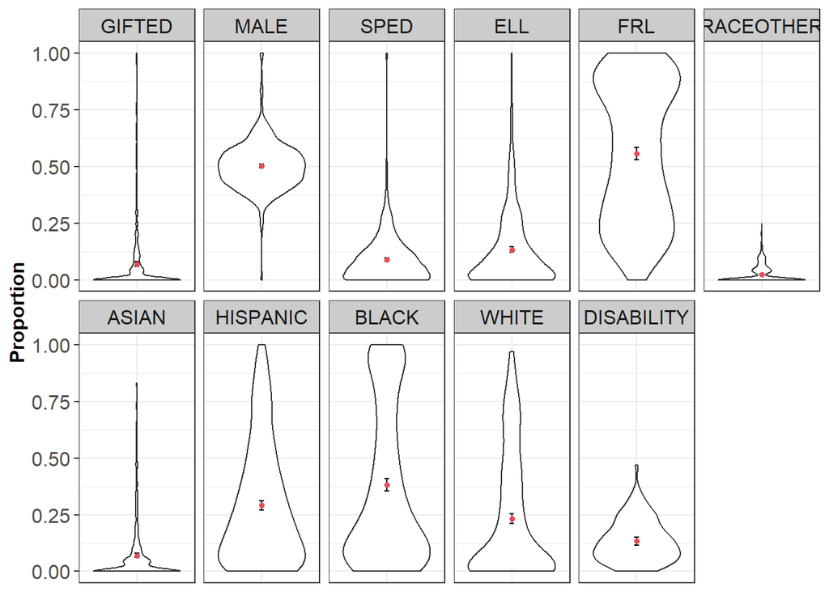

Note. The coral dots represent the weighted means. Error bars represent 95% CI.

Descriptive information on teachers teaching the class sections

| Characteristic | Count | Non-missing observations | Proportion of non-missing observations | Proportion of sample size |
| --- | --- | --- | --- | --- |
| DAD_MALE | 108 | 622 | 0.174 | 0.168 |
| DAD_WHITE | 358 | 620 | 0.577 | 0.558 |
| DAD_BLACK | 216 | 620 | 0.348 | 0.336 |
| DAD_HISPANIC | 34 | 620 | 0.055 | 0.053 |
| DAD_RACEOTHER | 12 | 620 | 0.019 | 0.019 |
| DAD_MASTERSPLUS | 194 | 480 | 0.404 | 0.302 |
| DAD_YRSEXP_NEW | 36 | 230 | 0.157 | 0.056 |
| DAD_YRSEXP_EARLY | 49 | 230 | 0.213 | 0.076 |
| DAD_YRSEXP_EST | 51 | 230 | 0.222 | 0.079 |
| DAD_YRSEXP_EXP | 57 | 230 | 0.248 | 0.089 |
| DAD_YRSEXP_HIGH | 37 | 230 | 0.161 | 0.058 |

Note. This table indicates the counts of teachers in the analytical sample that indicated a certain demographic characteristic. The information may be missing for some teachers in the total sample of 642 teachers.  
Experience was grouped as NEW = [0, 2] years, EARLY = (2, 5] years, EST = (5, 10] years, EXP = (10, 20] years, HIGH = (20, Inf) years.  
This table was saved as desc_Y2_all_teachers_cat.csv.

Descriptive information on teachers teaching the class sections (continued)

| Characteristic | Mean | SD | N |
| --- | --- | --- | --- |
| DAD_YRSEXP | 11.052 | 9.432 | 230 |
| FFT_CEV_adj | 2.652 | 0.193 | 642 |
| FFT_CERR_adj | 2.657 | 0.244 | 642 |
| FFT_ECL_adj | 2.529 | 0.225 | 642 |
| FFT_MCP_adj | 2.674 | 0.192 | 642 |
| FFT_MSB_adj | 2.748 | 0.226 | 642 |
| MQI_EI_adj | 1.229 | 0.073 | 642 |
| MQI_RICH_adj | 1.246 | 0.074 | 642 |
| MQI_WWSM_adj | 1.264 | 0.061 | 642 |
| MQI_SPMMR_adj | 1.188 | 0.086 | 642 |
| VA_SAM_adj | -0.004 | 0.183 | 642 |
| VA_BAM_adj | 0.002 | 0.167 | 642 |
| VA_NOAGGR_SAM_adj | -0.007 | 0.195 | 642 |
| VA_NOAGGR_BAM_adj | -0.001 | 0.180 | 642 |

Note. This table indicates mean and SD of teachers in the analytical sample that indicated a certain demographic characteristic. The information may be missing for some teachers in the total sample of 642 teachers.  
CEV, VA_SAM & VA_BAM represent teacher-level aggregates. FFT scores were adjusted at teacher level. VAMs were adjusted at section level and then aggregated at the teacher level using weighted means, accounting for the pupils included in the section-level VAMs.  
This table was saved as desc_Y2_all_teachers_num.csv.

Correlation of teaching experience with necessary condition and outcomes

| x | y | cor | ci_l | ci_u | df | t | p | N |
| --- | --- | --- | --- | --- | --- | --- | --- | --- |
| DAD_YRSEXP | FFT_CEV_adj_std | 0.077 | -0.053 | 0.204 | 228 | 1.164 | 0.246 | 230 |
| DAD_YRSEXP | FFT_CERR_adj_std | 0.057 | -0.073 | 0.185 | 228 | 0.860 | 0.391 | 230 |
| DAD_YRSEXP | FFT_ECL_adj_std | 0.067 | -0.063 | 0.194 | 228 | 1.010 | 0.314 | 230 |
| DAD_YRSEXP | FFT_MCP_adj_std | 0.078 | -0.052 | 0.205 | 228 | 1.180 | 0.239 | 230 |
| DAD_YRSEXP | FFT_MSB_adj_std | 0.069 | -0.061 | 0.197 | 228 | 1.043 | 0.298 | 230 |
| DAD_YRSEXP | MQI_EI_adj_std | -0.107 | -0.233 | 0.023 | 228 | -1.620 | 0.107 | 230 |
| DAD_YRSEXP | MQI_RICH_adj_std | -0.052 | -0.181 | 0.078 | 228 | -0.792 | 0.429 | 230 |
| DAD_YRSEXP | MQI_WWSM_adj_std | 0.004 | -0.126 | 0.133 | 228 | 0.058 | 0.954 | 230 |
| DAD_YRSEXP | MQI_SPMMR_adj_std | -0.006 | -0.135 | 0.124 | 228 | -0.084 | 0.933 | 230 |
| DAD_YRSEXP | VA_SAM_adj_std | 0.054 | -0.076 | 0.182 | 228 | 0.819 | 0.413 | 230 |
| DAD_YRSEXP | VA_BAM_adj_std | 0.119 | -0.010 | 0.245 | 228 | 1.816 | 0.071 | 230 |

Note. Data on DAD_YRSEXP is available for 230 teachers.  
This table was saved as cor_Y2_all_teaching_exp.csv.

#### **Figure**

#### *Relationship between teaching experience, necessary condition and outcomes*

Underlying count data for figure - Years of teaching experience

| DAD_YRSEXP_GRP | Domain | Mean | SD | N |
| --- | --- | --- | --- | --- |
| [0, 2] | CEV | -0.26 | 1.09 | 36 |
| [0, 2] | SAM | -0.09 | 0.88 | 36 |
| [0, 2] | BAM | -0.24 | 0.79 | 36 |
| (2, 5] | CEV | -0.03 | 1.15 | 49 |
| (2, 5] | SAM | 0.02 | 0.83 | 49 |
| (2, 5] | BAM | -0.07 | 0.73 | 49 |
| (5, 10] | CEV | 0.20 | 0.93 | 51 |
| (5, 10] | SAM | 0.07 | 0.74 | 51 |
| (5, 10] | BAM | 0.14 | 0.96 | 51 |
| (10, 20] | CEV | 0.02 | 0.89 | 57 |
| (10, 20] | SAM | -0.19 | 0.73 | 57 |
| (10, 20] | BAM | -0.20 | 1.00 | 57 |
| (20, Inf) | CEV | 0.05 | 0.71 | 37 |
| (20, Inf) | SAM | 0.13 | 0.94 | 37 |
| (20, Inf) | BAM | 0.25 | 0.76 | 37 |

#### **Figure**

#### *Relationship between teaching experience, necessary condition and outcomes*

[figure not shown]

Within vs between school variation - teacher level

| Domain | avg_within_sd | within_var | between_sd | between_var | total_var | within_pct | between_pct |
| --- | --- | --- | --- | --- | --- | --- | --- |
| FFT_CEV_adj | 0.136 | 0.025 | 0.159 | 0.025 | 0.051 | 0.503 | 0.497 |
| VA_BAM_adj | 0.131 | 0.022 | 0.114 | 0.013 | 0.035 | 0.633 | 0.367 |
| VA_SAM_adj | 0.137 | 0.025 | 0.143 | 0.020 | 0.046 | 0.556 | 0.444 |

Note. Data is available for 642 Teachers avg_within_sd is the average within-school SD. between_sd is the SD of school means. Classrooms were aggregated at teacher-level before aggregating at school level.

## Framework for Teaching (FFT)

Segment-level data is available for 2708 lesson segments.

Underlying count data for Observation score distributions figure

| item | domain | value | count | prop |
| --- | --- | --- | --- | --- |
| CERR | Classroom environment (FFT_CEV) | 1 | 135 | 0.0498523 |
| CERR | Classroom environment (FFT_CEV) | 2 | 762 | 0.2813885 |
| CERR | Classroom environment (FFT_CEV) | 3 | 1713 | 0.6325702 |
| CERR | Classroom environment (FFT_CEV) | 4 | 98 | 0.0361891 |
| ECL | Classroom environment (FFT_CEV) | 1 | 110 | 0.0406204 |
| ECL | Classroom environment (FFT_CEV) | 2 | 1134 | 0.4187592 |
| ECL | Classroom environment (FFT_CEV) | 3 | 1385 | 0.5114476 |
| ECL | Classroom environment (FFT_CEV) | 4 | 79 | 0.0291728 |
| MCP | Classroom environment (FFT_CEV) | 1 | 102 | 0.0376662 |
| MCP | Classroom environment (FFT_CEV) | 2 | 751 | 0.2773264 |
| MCP | Classroom environment (FFT_CEV) | 3 | 1776 | 0.6558346 |
| MCP | Classroom environment (FFT_CEV) | 4 | 79 | 0.0291728 |
| MSB | Classroom environment (FFT_CEV) | 1 | 70 | 0.0258493 |
| MSB | Classroom environment (FFT_CEV) | 2 | 644 | 0.2378139 |
| MSB | Classroom environment (FFT_CEV) | 3 | 1892 | 0.6986706 |
| MSB | Classroom environment (FFT_CEV) | 4 | 102 | 0.0376662 |

Note. The data shows the count of lesson video segments that have received a certain rating value for each component of the observation instrument.

#### **Figure**

#### *Distribution of observation scores*

[figure not shown]

#### **Figure**

#### *Unadjusted observation scores aggregated at teacher level*

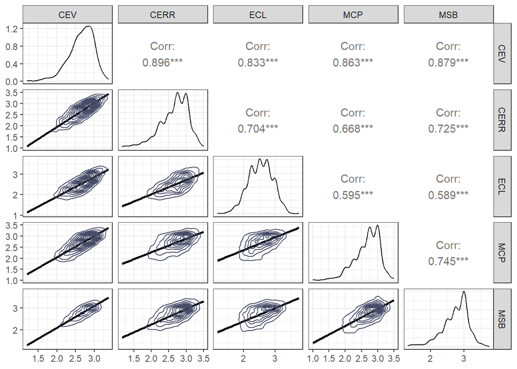

#### **Figure**

#### *Unadjusted observation scores aggregated at teacher level*

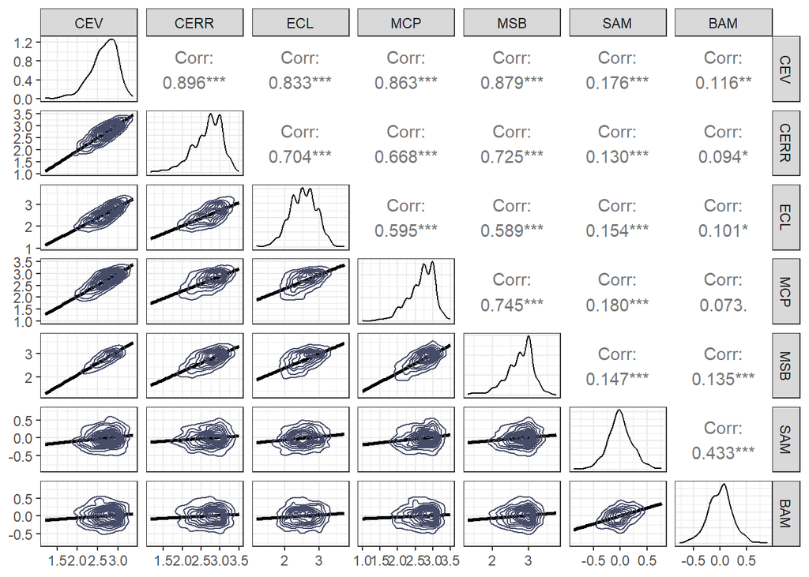

#### **Figure**

#### *Raw and adjusted observation scores*

[figure not shown]

Raw and adjusted observation scores

| Domain | Mean | SD | Mean_adj | SD_adj |
| --- | --- | --- | --- | --- |
| FFT_CEV | 2.651 | 0.334 | 2.652 | 0.193 |
| FFT_CERR | 2.657 | 0.402 | 2.657 | 0.244 |
| FFT_ECL | 2.529 | 0.385 | 2.529 | 0.225 |
| FFT_MCP | 2.673 | 0.374 | 2.674 | 0.192 |
| FFT_MSB | 2.747 | 0.377 | 2.748 | 0.226 |

Note. Data from 642 teachers is included.  
FFT_CEV refers to the domain scores for classroom environment, computed as the mean of their indicators.  
This table was saved as desc_Y2_all_FFT_adj.csv.

#### **Figure**

#### *Adjusted observation scores aggregated at teacher level*

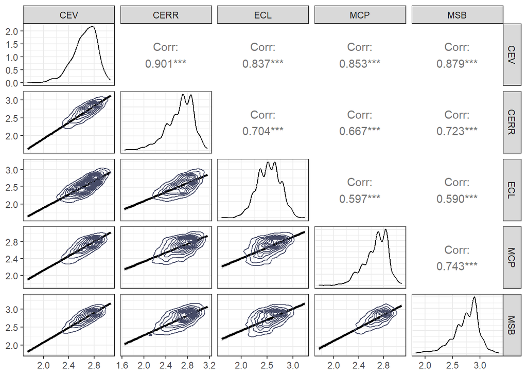

#### **Figure**

#### *Adjusted observation scores aggregated at teacher level*

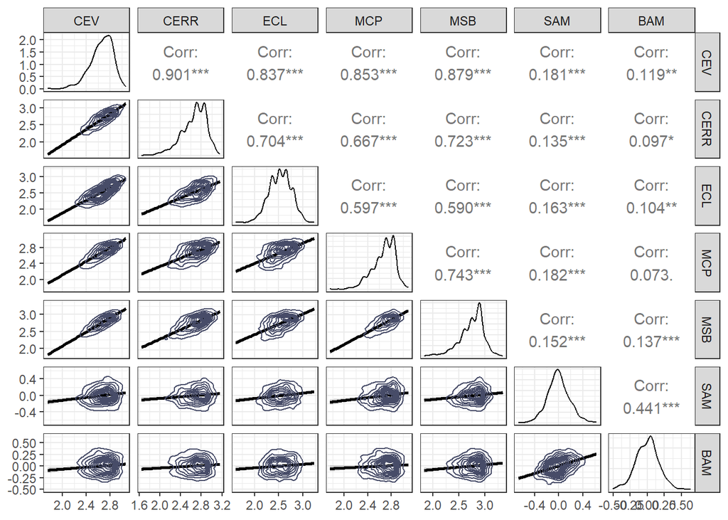

## Mathematical Quality of Instruction (MQI)

Segment-level data is available for 10616 lesson segments.

Underlying count data for Observation score distributions figure

| item | domain | value | count | prop |
| --- | --- | --- | --- | --- |
| EI | Teacher-content relationship | 1 | 8506 | 0.8012434 |
| EI | Teacher-content relationship | 2 | 1805 | 0.1700264 |
| EI | Teacher-content relationship | 3 | 305 | 0.0287302 |
| RICH | Teacher-content relationship | 1 | 8124 | 0.7652600 |
| RICH | Teacher-content relationship | 2 | 2361 | 0.2224002 |
| RICH | Teacher-content relationship | 3 | 131 | 0.0123399 |
| WWSM | Teacher-pupil relationship | 1 | 7921 | 0.7461379 |
| WWSM | Teacher-pupil relationship | 2 | 2566 | 0.2417106 |
| WWSM | Teacher-pupil relationship | 3 | 129 | 0.0121515 |
| SPMMR | Pupil-content relationship | 1 | 8709 | 0.8203655 |
| SPMMR | Pupil-content relationship | 2 | 1827 | 0.1720987 |
| SPMMR | Pupil-content relationship | 3 | 80 | 0.0075358 |

Note. The data shows the count of lesson video segments that have received a certain rating value for each component of the observation instrument.

#### **Figure**

#### *Distribution of observation scores*

[figure not shown]

#### **Figure**

#### *Unadjusted observation scores aggregated at teacher level*

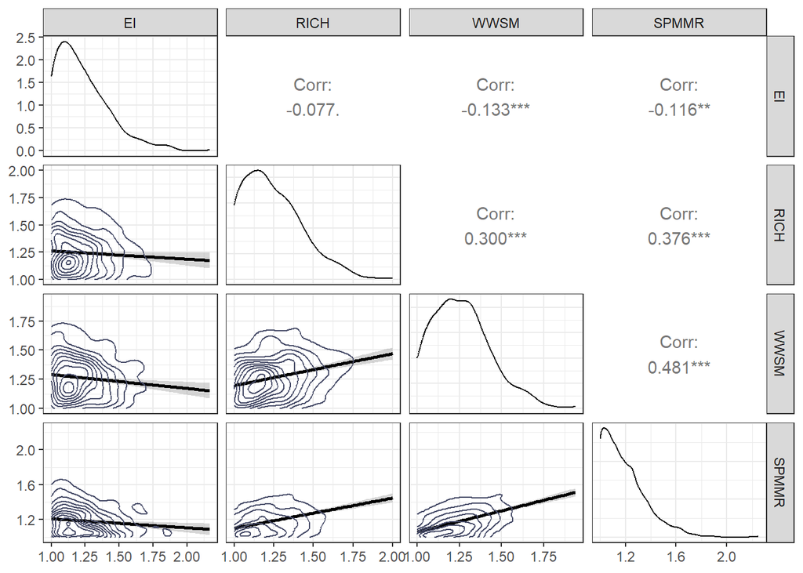

#### **Figure**

#### *Unadjusted observation scores aggregated at teacher level*

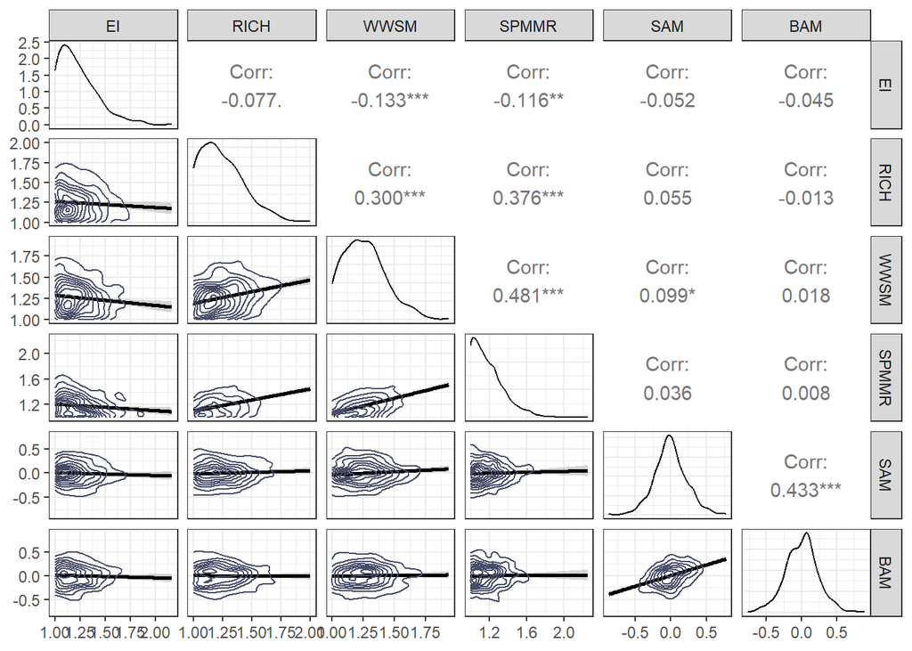

#### **Figure**

#### *Raw and adjusted observation scores*

[figure not shown]

Raw and adjusted observation scores

| Domain | Mean | SD | Mean_adj | SD_adj |
| --- | --- | --- | --- | --- |
| MQI_EI | 1.230 | 0.193 | 1.229 | 0.073 |
| MQI_RICH | 1.246 | 0.189 | 1.246 | 0.074 |
| MQI_WWSM | 1.264 | 0.173 | 1.264 | 0.061 |
| MQI_SPMMR | 1.188 | 0.173 | 1.188 | 0.086 |

Note. Data from 642 teachers is included.  
FFT_CEV refers to the domain scores for classroom environment, computed as the mean of their indicators.  
This table was saved as desc_Y2_all_MQI_adj.csv.

#### **Figure**

#### *Adjusted observation scores aggregated at teacher level*

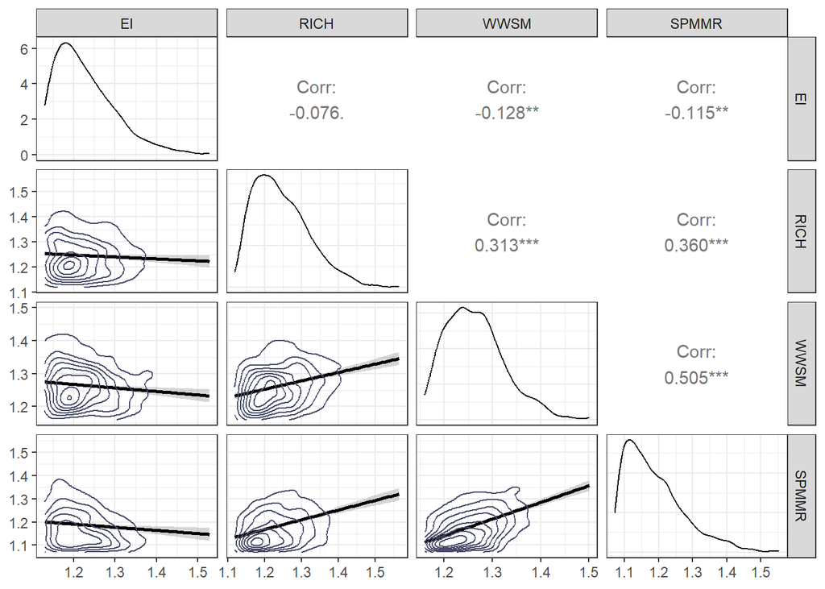

#### **Figure**

#### *Adjusted observation scores aggregated at teacher level*

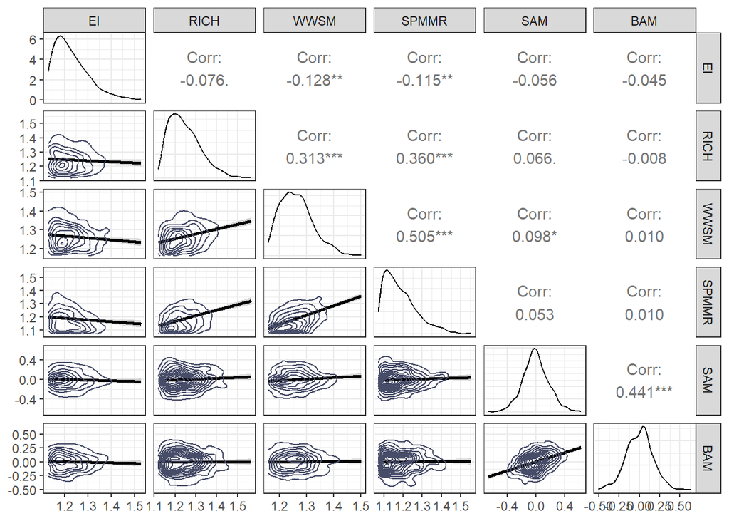

## Overall effect of observation score adjustment

Observation score adjustment

|  | Aggregation to teacher level N_SCORE | Aggregation to teacher level N_RATER | Aggregation to teacher level N_SEGMENT | Aggregation to teacher level N_LESSON | Aggregation to teacher level N_SECTION | Observed RELIABILITY | Observed SAMPLE | Hypothetical MIN_SCORE_ADJ | Hypothetical MAX_SCORE_ADJ |
| --- | --- | --- | --- | --- | --- | --- | --- | --- | --- |
| FFT_CERR | 4.22 (0.54) | 4.21 (0.52) | 4.02 (0.30) | 4.02 (0.30) | 1.00 (0.00) | 0.61 (0.02) | 2.66 (0.40) | 1.65 | 3.47 |
| FFT_ECL | 4.22 (0.54) | 4.21 (0.52) | 4.02 (0.30) | 4.02 (0.30) | 1.00 (0.00) | 0.58 (0.03) | 2.53 (0.38) | 1.64 | 3.39 |
| FFT_MCP | 4.22 (0.54) | 4.21 (0.52) | 4.02 (0.30) | 4.02 (0.30) | 1.00 (0.00) | 0.52 (0.02) | 2.67 (0.37) | 1.81 | 3.36 |
| FFT_MSB | 4.22 (0.54) | 4.21 (0.52) | 4.02 (0.30) | 4.02 (0.30) | 1.00 (0.00) | 0.60 (0.02) | 2.75 (0.38) | 1.70 | 3.50 |
| MQI_EI | 16.54 (2.46) | 4.12 (0.61) | 15.78 (1.63) | 3.95 (0.41) | 1.00 (0.00) | 0.38 (0.03) | 1.23 (0.19) | 1.14 | 1.91 |
| MQI_RICH | 16.54 (2.46) | 4.12 (0.61) | 15.78 (1.63) | 3.95 (0.41) | 1.00 (0.00) | 0.40 (0.03) | 1.25 (0.19) | 1.15 | 1.94 |
| MQI_WWSM | 16.54 (2.46) | 4.12 (0.61) | 15.78 (1.63) | 3.95 (0.41) | 1.00 (0.00) | 0.35 (0.03) | 1.26 (0.17) | 1.17 | 1.87 |
| MQI_SPMMR | 16.54 (2.46) | 4.12 (0.61) | 15.78 (1.63) | 3.95 (0.41) | 1.00 (0.00) | 0.51 (0.03) | 1.19 (0.17) | 1.09 | 2.11 |

Note. Data from 642 teachers is included.  
Table shows the counts as M (SD) of scores, raters, segments, lessons and sections that were aggregated to derive a single score at the teacher level.  
These counts informed the calculation of the reliability coefficients. Together with the observed sample mean (SD), the reliability coefficients were used to calculate the smallest and largest observation score that was hypothetically possible following adjustment.  
This table was saved as desc_Y2_all_shrinkage.csv.

## Value-added measures

Value-added scores

| VAM | Mean | SD | N Teachers |
| --- | --- | --- | --- |
| VA_SAM | 0.00 | 0.23 | 642 |
| VA_BAM | 0.00 | 0.23 | 642 |
| VA_NOAGGR_SAM | -0.01 | 0.24 | 642 |
| VA_NOAGGR_BAM | 0.00 | 0.24 | 642 |
| VA_SAM_SE | 0.11 | 0.02 | 642 |
| VA_SAM_N | 22.20 | 6.27 | 642 |
| VA_BAM_SE | 0.14 | 0.02 | 642 |
| VA_BAM_N | 18.93 | 5.34 | 642 |
| VA_NOAGGR_SAM_SE | 0.11 | 0.02 | 642 |
| VA_NOAGGR_SAM_N | 22.20 | 6.27 | 642 |
| VA_NOAGGR_BAM_SE | 0.14 | 0.02 | 642 |
| VA_NOAGGR_BAM_N | 18.93 | 5.34 | 642 |
| VA_SAM_rel | 0.82 | 0.05 | 642 |
| VA_SAM_adj | 0.00 | 0.18 | 642 |
| VA_BAM_rel | 0.73 | 0.06 | 642 |
| VA_BAM_adj | 0.00 | 0.17 | 642 |
| VA_NOAGGR_SAM_rel | 0.83 | 0.04 | 642 |
| VA_NOAGGR_SAM_adj | -0.01 | 0.20 | 642 |
| VA_NOAGGR_BAM_rel | 0.74 | 0.06 | 642 |
| VA_NOAGGR_BAM_adj | 0.00 | 0.18 | 642 |
| VA_SAM_std | 0.00 | 1.00 | 642 |
| VA_SAM_adj_std | 0.00 | 1.00 | 642 |
| VA_BAM_std | 0.00 | 1.00 | 642 |
| VA_BAM_adj_std | 0.00 | 1.00 | 642 |
| VA_NOAGGR_SAM_std | 0.00 | 1.00 | 642 |
| VA_NOAGGR_SAM_adj_std | 0.00 | 1.00 | 642 |
| VA_NOAGGR_BAM_std | 0.00 | 1.00 | 642 |
| VA_NOAGGR_BAM_adj_std | 0.00 | 1.00 | 642 |

Note.

#### **Figure**

#### *Raw and adjusted VA scores*

[figure not shown]

TVA score adjustment

|  | RELIABILITY | SAMPLE |
| --- | --- | --- |
| VA_SAM | 0.82 (0.05) | -0.00 (0.23) |
| VA_BAM | 0.73 (0.06) | 0.00 (0.23) |
| VA_NOAGGR_SAM | 0.83 (0.04) | -0.01 (0.24) |
| VA_NOAGGR_BAM | 0.74 (0.06) | -0.00 (0.24) |

Note. Data from 642 classrooms is included.  
Table shows reliability and observed scores as M (SD).

## Intercorrelation matrix

[figure not shown]

Correlation of variables at teacher level

|  | CEV | CERR | ECL | MCP | MSB | EI | RICH | WWSM | SPMMR | SAM | BAM | SAM(*) | BAM(*) | YRSEXP |
| --- | --- | --- | --- | --- | --- | --- | --- | --- | --- | --- | --- | --- | --- | --- |
| CEV | r = 1.00 (p <.001) | r = .90 (p <.001) | r = .83 (p <.001) | r = .86 (p <.001) | r = .88 (p <.001) | r = -.01 (p = 1) | r = .22 (p <.001) | r = .10 (p = .687) | r = .20 (p <.001) | r = .18 (p = .001) | r = .12 (p = .228) | r = .22 (p <.001) | r = .16 (p = .005) | r = .08 (p = 1) |
| CERR | r = .90 (p <.001) | r = 1.00 (p <.001) | r = .70 (p <.001) | r = .67 (p <.001) | r = .73 (p <.001) | r = -.03 (p = 1) | r = .22 (p <.001) | r = .06 (p = 1) | r = .15 (p = .010) | r = .13 (p = .074) | r = .09 (p = .803) | r = .17 (p = .002) | r = .14 (p = .026) | r = .06 (p = 1) |
| ECL | r = .84 (p <.001) | r = .70 (p <.001) | r = 1.00 (p <.001) | r = .59 (p <.001) | r = .59 (p <.001) | r = -.07 (p = 1) | r = .21 (p <.001) | r = .11 (p = .240) | r = .23 (p <.001) | r = .15 (p = .010) | r = .10 (p = .542) | r = .19 (p <.001) | r = .13 (p = .061) | r = .07 (p = 1) |
| MCP | r = .85 (p <.001) | r = .67 (p <.001) | r = .60 (p <.001) | r = 1.00 (p <.001) | r = .74 (p <.001) | r = .04 (p = 1) | r = .19 (p <.001) | r = .10 (p = .485) | r = .16 (p = .008) | r = .18 (p <.001) | r = .07 (p = 1) | r = .22 (p <.001) | r = .11 (p = .426) | r = .08 (p = 1) |
| MSB | r = .88 (p <.001) | r = .72 (p <.001) | r = .59 (p <.001) | r = .74 (p <.001) | r = 1.00 (p <.001) | r = .02 (p = 1) | r = .16 (p = .009) | r = .06 (p = 1) | r = .14 (p = .031) | r = .15 (p = .018) | r = .13 (p = .053) | r = .18 (p <.001) | r = .18 (p = .001) | r = .07 (p = 1) |
| EI | r = -.01 (p = .924) | r = -.03 (p = .532) | r = -.07 (p = .142) | r = .04 (p = .411) | r = .02 (p = .769) | r = 1.00 (p <.001) | r = -.08 (p = 1) | r = -.13 (p = .061) | r = -.12 (p = .231) | r = -.05 (p = 1) | r = -.04 (p = 1) | r = -.08 (p = 1) | r = -.06 (p = 1) | r = -.11 (p = 1) |
| RICH | r = .24 (p <.001) | r = .24 (p <.001) | r = .22 (p <.001) | r = .21 (p <.001) | r = .17 (p <.001) | r = -.08 (p = .090) | r = 1.00 (p <.001) | r = .30 (p <.001) | r = .38 (p <.001) | r = .06 (p = 1) | r = -.01 (p = 1) | r = .07 (p = 1) | r = .00 (p = 1) | r = -.06 (p = 1) |
| WWSM | r = .10 (p = .021) | r = .07 (p = .149) | r = .12 (p = .003) | r = .11 (p = .011) | r = .05 (p = .269) | r = -.13 (p = .002) | r = .31 (p <.001) | r = 1.00 (p <.001) | r = .48 (p <.001) | r = .10 (p = .624) | r = .02 (p = 1) | r = .11 (p = .256) | r = .04 (p = 1) | r = .01 (p = 1) |
| SPMMR | r = .23 (p <.001) | r = .19 (p <.001) | r = .25 (p <.001) | r = .19 (p <.001) | r = .17 (p <.001) | r = -.11 (p = .007) | r = .36 (p <.001) | r = .50 (p <.001) | r = 1.00 (p <.001) | r = .04 (p = 1) | r = .01 (p = 1) | r = .07 (p = 1) | r = .05 (p = 1) | r = -.00 (p = 1) |
| SAM | r = .18 (p <.001) | r = .14 (p = .001) | r = .16 (p <.001) | r = .18 (p <.001) | r = .15 (p <.001) | r = -.06 (p = .233) | r = .07 (p = .147) | r = .10 (p = .023) | r = .05 (p = .269) | r = 1.00 (p <.001) | r = .43 (p <.001) | r = .94 (p <.001) | r = .41 (p <.001) | r = .05 (p = 1) |
| BAM | r = .12 (p = .005) | r = .10 (p = .026) | r = .10 (p = .016) | r = .07 (p = .105) | r = .14 (p = .001) | r = -.04 (p = .366) | r = -.01 (p = 1) | r = .01 (p = 1) | r = .01 (p = 1) | r = .44 (p <.001) | r = 1.00 (p <.001) | r = .42 (p <.001) | r = .96 (p <.001) | r = .12 (p = 1) |
| SAM(*) | r = .22 (p <.001) | r = .17 (p <.001) | r = .20 (p <.001) | r = .22 (p <.001) | r = .19 (p <.001) | r = -.08 (p = .080) | r = .08 (p = .077) | r = .11 (p = .008) | r = .09 (p = .048) | r = .94 (p <.001) | r = .42 (p <.001) | r = 1.00 (p <.001) | r = .46 (p <.001) | r = .07 (p = 1) |
| BAM(*) | r = .16 (p <.001) | r = .14 (p <.001) | r = .13 (p = .001) | r = .10 (p = .017) | r = .18 (p <.001) | r = -.06 (p = .167) | r = .00 (p = 1) | r = .03 (p = .579) | r = .05 (p = .291) | r = .42 (p <.001) | r = .96 (p <.001) | r = .47 (p <.001) | r = 1.00 (p <.001) | r = .14 (p = 1) |
| YRSEXP | r = .08 (p = .354) | r = .06 (p = .528) | r = .07 (p = .433) | r = .08 (p = .347) | r = .07 (p = .414) | r = -.11 (p = .166) | r = -.05 (p = .569) | r = .00 (p = 1) | r = -.01 (p = 1) | r = .05 (p = .551) | r = .12 (p = .115) | r = .08 (p = .362) | r = .13 (p = .079) | r = 1.00 (p <.001) |

Note. Data is available for 642 teachers, of which 230had non-missing data for DAD_YRSEXP. The upper triangle uses raw data whereas the lower triangle uses adjusted data. All p values were adjusted using the FDR method.  
This table was saved as cor_Y2_all.csv.

## Main NCA analysis

OLS coefficients

| Observation score | Model 1 B | Model 1 SE_B | Model 1 β | Model 1 SE | Model 1 t | Model 1 p | Model 1 R2 | Model 1 R2_adj | Model 1 F | Model 1 numdf | Model 1 dendf | Model 1 p (F) | Model 2 B | Model 2 SE_B | Model 2 β | Model 2 SE | Model 2 t | Model 2 p | Model 2 R2 | Model 2 R2_adj | Model 2 F | Model 2 numdf | Model 2 dendf | Model 2 p (F) |
| --- | --- | --- | --- | --- | --- | --- | --- | --- | --- | --- | --- | --- | --- | --- | --- | --- | --- | --- | --- | --- | --- | --- | --- | --- |
| VA_SAM_adj_std |  |  |  |  |  |  |  |  |  |  |  |  |  |  |  |  |  |  |  |  |  |  |  |  |
| CEV | 0.94 | 0.20 | 0.18 | 0.04 | 4.644 | <.001 | 0.03% | 0.03% | 21.562 | 1 | 640 | <.001 |  |  |  |  |  |  |  |  |  |  |  |  |
| CERR | 0.55 | 0.16 | 0.14 | 0.04 | 3.458 | <.001 | 0.02% | 0.02% | 11.960 | 1 | 640 | <.001 | -0.16 | 0.27 | -0.04 | 0.07 | -0.586 | .558 | 0.04% | 0.03% | 6.351 | 4 | 637 | <.001 |
| ECL | 0.72 | 0.17 | 0.16 | 0.04 | 4.174 | <.001 | 0.03% | 0.02% | 17.425 | 1 | 640 | <.001 | 0.43 | 0.25 | 0.10 | 0.06 | 1.705 | .089 | 0.04% | 0.03% | 6.351 | 4 | 637 | <.001 |
| MCP | 0.95 | 0.20 | 0.18 | 0.04 | 4.694 | <.001 | 0.03% | 0.03% | 22.034 | 1 | 640 | <.001 | 0.68 | 0.32 | 0.13 | 0.06 | 2.142 | .033 | 0.04% | 0.03% | 6.351 | 4 | 637 | <.001 |
| MSB | 0.67 | 0.17 | 0.15 | 0.04 | 3.894 | <.001 | 0.02% | 0.02% | 15.161 | 1 | 640 | <.001 | 0.11 | 0.29 | 0.03 | 0.07 | 0.387 | .699 | 0.04% | 0.03% | 6.351 | 4 | 637 | <.001 |
| VA_BAM_adj_std |  |  |  |  |  |  |  |  |  |  |  |  |  |  |  |  |  |  |  |  |  |  |  |  |
| CEV | 0.62 | 0.20 | 0.12 | 0.04 | 3.042 | .002 | 0.01% | 0.01% | 9.256 | 1 | 640 | .002 |  |  |  |  |  |  |  |  |  |  |  |  |
| CERR | 0.40 | 0.16 | 0.10 | 0.04 | 2.458 | .014 | 0.01% | 0.01% | 6.039 | 1 | 640 | .014 | -0.08 | 0.27 | -0.02 | 0.07 | -0.311 | .756 | 0.02% | 0.02% | 3.703 | 4 | 637 | .005 |
| ECL | 0.46 | 0.17 | 0.10 | 0.04 | 2.646 | .008 | 0.01% | 0.01% | 7.004 | 1 | 640 | .008 | 0.28 | 0.25 | 0.06 | 0.06 | 1.127 | .260 | 0.02% | 0.02% | 3.703 | 4 | 637 | .005 |
| MCP | 0.38 | 0.20 | 0.07 | 0.04 | 1.851 | .065 | 0.01% | 0.00% | 3.428 | 1 | 640 | .065 | -0.42 | 0.32 | -0.08 | 0.06 | -1.314 | .189 | 0.02% | 0.02% | 3.703 | 4 | 637 | .005 |
| MSB | 0.61 | 0.17 | 0.14 | 0.04 | 3.504 | <.001 | 0.02% | 0.02% | 12.281 | 1 | 640 | <.001 | 0.78 | 0.29 | 0.17 | 0.07 | 2.655 | .008 | 0.02% | 0.02% | 3.703 | 4 | 637 | .005 |

Note. Data from 642 teachers is included. In model 1, each predictor was entered seperately. In model 2, all predictors were entered together.  
This table was saved as coef_Y2_all_main_ols.csv

NCA parameters

| Metric | FFT_CEV_adj | FFT_CERR_adj | FFT_ECL_adj | FFT_MCP_adj | FFT_MSB_adj |
| --- | --- | --- | --- | --- | --- |
| VA_SAM_adj_std |  |  |  |  |  |
| Number of observations | 642 | 642 | 642 | 642 | 642 |
| Scope | 9.37 [48.60] | 10.80 [44.22] | 11.51 [51.03] | 9.53 [49.52] | 10.82 [47.96] |
| Ceiling zone | 2.20 [11.41] | 2.29 [9.39] | 2.29 [10.15] | 2.03 [10.54] | 1.99 [8.85] |
| Effect size | .23 | .21 | .20 | .21 | .18 |
| p value (unadj.) | .009 | .007 | .002 | .054 | .013 |
| p value (adj.) | .018 | .013 | .010 | .054 | .018 |
| p accuracy | .002 | .002 | .001 | .004 | .002 |
| Slope | 4.84 [0.93] | 4.03 [0.98] | 4.26 [0.96] | 3.92 [0.75] | 4.09 [0.92] |
| Intercept | -9.58 [3.25] | -7.45 [3.25] | -7.82 [2.96] | -7.39 [3.09] | -8.01 [3.21] |
| Fit | 97.63% | 98.27% | N/A | 84.89% | 95.99% |
| Ceiling accuracy | 98.75% (634) | 98.60% (633) | 98.44% (632) | 99.22% (637) | 98.75% (634) |
| Noise | 1.20% (8) | 1.20% (8) | 1.20% (8) | 0.80% (5) | 1.20% (8) |
| Exceptions | 0.00% (0) | 0.20% (1) | 0.30% (2) | 0.00% (0) | 0.00% (0) |
| Support | 8.10% (52) | 9.30% (60) | 12.30% (79) | 7.50% (48) | 7.20% (46) |
| Spread | .34 | .32 | .27 | .30 | .34 |
| Sharpness | .86 | .88 | .91 | .90 | .85 |
| Relative inefficiency | 53.05% | 57.55% | 60.23% | 57.41% | 63.11% |
| Condition inefficiency | 27.44% | 29.57% | 35.79% | 23.90% | 34.86% |
| Outcome inefficiency | 35.29% | 39.73% | 38.07% | 44.03% | 43.37% |
| VA_BAM_adj_std |  |  |  |  |  |
| Number of observations | 642 | 642 | 642 | 642 | 642 |
| Scope | 9.01 [46.75] | 10.38 [42.54] | 11.07 [49.09] | 9.17 [47.63] | 10.40 [46.14] |
| Ceiling zone | 2.30 [11.95] | 2.21 [9.05] | 2.20 [9.75] | 2.20 [11.42] | 1.40 [6.19] |
| Effect size | .26 | .21 | .20 | .24 | .13 |
| p value (unadj.) | .056 | .123 | .074 | .122 | .679 |
| p value (adj.) | .056 | .163 | .163 | .163 | .679 |
| p accuracy | .005 | .006 | .005 | .006 | .009 |
| Slope | 4.61 [0.89] | 4.10 [1.00] | 3.88 [0.87] | 5.64 [1.08] | 5.46 [1.23] |
| Intercept | -8.87 [3.37] | -7.22 [3.69] | -6.59 [3.22] | -11.07 [4.00] | -10.06 [4.93] |
| Fit | 90.56% | 83.80% | 82.64% | 90.97% | 72.26% |
| Ceiling accuracy | 99.22% (637) | 99.53% (639) | 99.22% (637) | 99.53% (639) | 99.53% (639) |
| Noise | 0.80% (5) | 0.50% (3) | 0.80% (5) | 0.30% (2) | 0.50% (3) |
| Exceptions | 0.00% (0) | 0.00% (0) | 0.00% (0) | 0.20% (1) | 0.00% (0) |
| Support | 8.60% (55) | 7.20% (46) | 9.20% (59) | 6.50% (42) | 1.20% (8) |
| Spread | .31 | .28 | .24 | .31 | .41 |
| Sharpness | .92 | .94 | .92 | .95 | .67 |
| Relative inefficiency | 48.86% | 57.45% | 60.26% | 52.06% | 73.15% |
| Condition inefficiency | 23.95% | 31.47% | 34.02% | 33.94% | 52.84% |
| Outcome inefficiency | 32.76% | 37.91% | 39.77% | 27.42% | 43.07% |

Note. Data from 642 teachers is included. NCA ceiling line = CR-FDH. Fit values of N/A indicate cases where the CR-FDH ceiling zone exceeds the CE-FDH ceiling zone, resulting in a negative closeness percentage that is not conceptually interpretable. This occurs when the straight-line CR-FDH approximation creates a larger empty space than the CE-FDH step-function boundary and does not invalidate effect sizes or ceiling accuracy.  
p values were estimated using 10000 permutations.  
This table was saved as coef_Y2_all_main_nca.csv

#### **Figure**

#### *NCA Plot: VAMs - CEV*

[figure not shown]

#### **Figure**

#### *NCA Plot: FFT indicators - SAM*

[figure not shown]

#### **Figure**

#### *NCA Plot: FFT indicators - BAM*

[figure not shown]

NCA bottlenecks

| Ouctome | FFT_CEV_adj Adj. | FFT_CEV_adj Adj. std. | FFT_CEV_adj % range | FFT_CEV_adj Percentile | FFT_CERR_adj Adj. | FFT_CERR_adj Adj. std. | FFT_CERR_adj % range | FFT_CERR_adj Percentile | FFT_ECL_adj Adj. | FFT_ECL_adj Adj. std. | FFT_ECL_adj % range | FFT_ECL_adj Percentile | FFT_MCP_adj Adj. | FFT_MCP_adj Adj. std. | FFT_MCP_adj % range | FFT_MCP_adj Percentile | FFT_MSB_adj Adj. | FFT_MSB_adj Adj. std. | FFT_MSB_adj % range | FFT_MSB_adj Percentile |
| --- | --- | --- | --- | --- | --- | --- | --- | --- | --- | --- | --- | --- | --- | --- | --- | --- | --- | --- | --- | --- |
| VA_SAM_adj_std |  |  |  |  |  |  |  |  |  |  |  |  |  |  |  |  |  |  |  |  |
| -3.5 | NN | NN | NN | NN | NN | NN | NN | NN | NN | NN | NN | NN | NN | NN | NN | NN | NN | NN | NN | NN |
| -3 | NN | NN | NN | NN | NN | NN | NN | NN | NN | NN | NN | NN | NN | NN | NN | NN | NN | NN | NN | NN |
| -2.5 | NN | NN | NN | NN | NN | NN | NN | NN | NN | NN | NN | NN | NN | NN | NN | NN | NN | NN | NN | NN |
| -2 | NN | NN | NN | NN | NN | NN | NN | NN | NN | NN | NN | NN | NN | NN | NN | NN | NN | NN | NN | NN |
| -1.5 | NN | NN | NN | NN | NN | NN | NN | NN | NN | NN | NN | NN | NN | NN | NN | NN | NN | NN | NN | NN |
| -1 | 1.774 | -4.555 | 2.0 | 0.3 | NN | NN | NN | NN | NN | NN | NN | NN | NN | NN | NN | NN | NN | NN | NN | NN |
| -0.5 | 1.877 | -4.018 | 9.9 | 0.3 | 1.726 | -3.813 | 5.1 | 0.3 | 1.718 | -3.598 | 6.3 | 0.3 | 1.758 | -4.760 | 0.0 | 0.2 | 1.839 | -4.029 | 0.8 | 0.2 |
| 0 | 1.981 | -3.482 | 17.7 | 0.3 | 1.850 | -3.305 | 13.3 | 0.6 | 1.835 | -3.078 | 13.5 | 0.3 | 1.885 | -4.098 | 9.6 | 0.2 | 1.961 | -3.486 | 8.9 | 0.3 |
| 0.5 | 2.084 | -2.946 | 25.6 | 0.6 | 1.974 | -2.796 | 21.5 | 1.9 | 1.952 | -2.557 | 20.8 | 0.9 | 2.013 | -3.435 | 19.2 | 0.3 | 2.084 | -2.944 | 17.0 | 1.4 |
| 1 | 2.187 | -2.410 | 33.5 | 2.5 | 2.098 | -2.288 | 29.7 | 2.6 | 2.070 | -2.037 | 28.1 | 1.4 | 2.140 | -2.773 | 28.7 | 1.1 | 2.206 | -2.401 | 25.0 | 2.6 |
| 1.5 | 2.291 | -1.874 | 41.3 | 4.2 | 2.222 | -1.780 | 37.9 | 5.0 | 2.187 | -1.516 | 35.3 | 4.7 | 2.268 | -2.111 | 38.2 | 2.6 | 2.329 | -1.858 | 33.1 | 5.9 |
| 2 | 2.394 | -1.338 | 49.2 | 10.1 | 2.346 | -1.271 | 46.1 | 10.3 | 2.304 | -0.995 | 42.6 | 15.1 | 2.395 | -1.448 | 47.8 | 9.7 | 2.451 | -1.316 | 41.2 | 7.8 |
| 2.5 | 2.497 | -0.801 | 57.1 | 18.8 | 2.470 | -0.763 | 54.3 | 21.7 | 2.422 | -0.475 | 49.9 | 34.0 | 2.523 | -0.786 | 57.3 | 20.7 | 2.573 | -0.773 | 49.2 | 15.1 |
| 3 | 2.601 | -0.265 | 64.9 | 35.0 | 2.594 | -0.254 | 62.5 | 37.9 | 2.539 | 0.046 | 57.2 | 55.8 | 2.650 | -0.124 | 66.8 | 38.5 | 2.696 | -0.230 | 57.3 | 32.7 |
| VA_BAM_adj_std |  |  |  |  |  |  |  |  |  |  |  |  |  |  |  |  |  |  |  |  |
| -3 | NN | NN | NN | NN | NN | NN | NN | NN | NN | NN | NN | NN | NN | NN | NN | NN | NN | NN | NN | NN |
| -2.5 | NN | NN | NN | NN | NN | NN | NN | NN | NN | NN | NN | NN | NN | NN | NN | NN | NN | NN | NN | NN |
| -2 | NN | NN | NN | NN | NN | NN | NN | NN | NN | NN | NN | NN | NN | NN | NN | NN | NN | NN | NN | NN |
| -1.5 | NN | NN | NN | NN | NN | NN | NN | NN | NN | NN | NN | NN | NN | NN | NN | NN | NN | NN | NN | NN |
| -1 | NN | NN | NN | NN | NN | NN | NN | NN | NN | NN | NN | NN | 1.787 | -4.610 | 2.3 | 0.2 | NN | NN | NN | NN |
| -0.5 | 1.813 | -4.350 | 5.0 | 0.3 | NN | NN | NN | NN | NN | NN | NN | NN | 1.875 | -4.149 | 8.9 | 0.2 | NN | NN | NN | NN |
| 0 | 1.922 | -3.788 | 13.3 | 0.3 | 1.758 | -3.680 | 7.3 | 0.3 | 1.700 | -3.676 | 5.2 | 0.3 | 1.964 | -3.688 | 15.5 | 0.3 | 1.844 | -4.007 | 1.2 | 0.2 |
| 0.5 | 2.030 | -3.226 | 21.5 | 0.5 | 1.880 | -3.181 | 15.3 | 0.6 | 1.829 | -3.105 | 13.1 | 0.3 | 2.053 | -3.227 | 22.2 | 0.3 | 1.936 | -3.601 | 7.2 | 0.3 |
| 1 | 2.138 | -2.664 | 29.7 | 1.9 | 2.002 | -2.681 | 23.3 | 1.9 | 1.958 | -2.533 | 21.1 | 0.9 | 2.141 | -2.766 | 28.8 | 1.1 | 2.027 | -3.194 | 13.2 | 1.2 |
| 1.5 | 2.247 | -2.102 | 38.0 | 3.7 | 2.124 | -2.182 | 31.4 | 4.2 | 2.087 | -1.961 | 29.1 | 4.2 | 2.230 | -2.305 | 35.4 | 2.5 | 2.119 | -2.788 | 19.3 | 1.4 |
| 2 | 2.355 | -1.539 | 46.2 | 7.2 | 2.246 | -1.683 | 39.4 | 5.5 | 2.215 | -1.390 | 37.1 | 6.1 | 2.319 | -1.844 | 42.1 | 3.7 | 2.211 | -2.382 | 25.3 | 2.6 |
| 2.5 | 2.463 | -0.977 | 54.5 | 16.7 | 2.367 | -1.184 | 47.5 | 10.4 | 2.344 | -0.818 | 45.1 | 16.0 | 2.408 | -1.383 | 48.7 | 9.7 | 2.302 | -1.975 | 31.4 | 3.1 |
| 3 | 2.572 | -0.415 | 62.7 | 30.7 | 2.489 | -0.685 | 55.5 | 22.7 | 2.473 | -0.246 | 53.1 | 35.7 | 2.496 | -0.922 | 55.3 | 19.3 | 2.394 | -1.569 | 37.4 | 7.0 |
| 3.5 | 2.680 | 0.147 | 71.0 | 50.6 | 2.611 | -0.186 | 63.6 | 37.9 | 2.602 | 0.325 | 61.1 | 60.0 | 2.585 | -0.462 | 62.0 | 22.4 | 2.485 | -1.163 | 43.4 | 14.5 |

Note. Data from 642 teachers is included. Bottlenecks are shown for each condition where the values are shown as adjusted values, adjusted standardised values, percentage range or percentiles. NCA ceiling line = CR-FDH. NN = not necessary.  
This table was saved as coef_Y2_all_main_bottlenecks.csv

## Supplemental NCA analysis: different outcomes

OLS coefficients

| Observation score | Model 1 B | Model 1 SE_B | Model 1 β | Model 1 SE | Model 1 t | Model 1 p | Model 1 R2 | Model 1 R2_adj | Model 1 F | Model 1 numdf | Model 1 dendf | Model 1 p (F) | Model 2 B | Model 2 SE_B | Model 2 β | Model 2 SE | Model 2 t | Model 2 p | Model 2 R2 | Model 2 R2_adj | Model 2 F | Model 2 numdf | Model 2 dendf | Model 2 p (F) |
| --- | --- | --- | --- | --- | --- | --- | --- | --- | --- | --- | --- | --- | --- | --- | --- | --- | --- | --- | --- | --- | --- | --- | --- | --- |
| VA_NOAGGR_SAM_adj_std |  |  |  |  |  |  |  |  |  |  |  |  |  |  |  |  |  |  |  |  |  |  |  |  |
| CEV | 1.16 | 0.20 | 0.22 | 0.04 | 5.780 | <.001 | 0.05% | 0.05% | 33.412 | 1 | 640 | <.001 |  |  |  |  |  |  |  |  |  |  |  |  |
| CERR | 0.71 | 0.16 | 0.17 | 0.04 | 4.452 | <.001 | 0.03% | 0.03% | 19.824 | 1 | 640 | <.001 | -0.10 | 0.27 | -0.02 | 0.07 | -0.359 | .719 | 0.06% | 0.05% | 9.481 | 4 | 637 | <.001 |
| ECL | 0.87 | 0.17 | 0.20 | 0.04 | 5.062 | <.001 | 0.04% | 0.04% | 25.626 | 1 | 640 | <.001 | 0.46 | 0.25 | 0.10 | 0.06 | 1.841 | .066 | 0.06% | 0.05% | 9.481 | 4 | 637 | <.001 |
| MCP | 1.16 | 0.20 | 0.22 | 0.04 | 5.784 | <.001 | 0.05% | 0.05% | 33.451 | 1 | 640 | <.001 | 0.81 | 0.32 | 0.16 | 0.06 | 2.569 | .010 | 0.06% | 0.05% | 9.481 | 4 | 637 | <.001 |
| MSB | 0.83 | 0.17 | 0.19 | 0.04 | 4.829 | <.001 | 0.04% | 0.03% | 23.322 | 1 | 640 | <.001 | 0.12 | 0.29 | 0.03 | 0.06 | 0.422 | .673 | 0.06% | 0.05% | 9.481 | 4 | 637 | <.001 |
| VA_NOAGGR_BAM_adj_std |  |  |  |  |  |  |  |  |  |  |  |  |  |  |  |  |  |  |  |  |  |  |  |  |
| CEV | 0.84 | 0.20 | 0.16 | 0.04 | 4.139 | <.001 | 0.03% | 0.02% | 17.135 | 1 | 640 | <.001 |  |  |  |  |  |  |  |  |  |  |  |  |
| CERR | 0.58 | 0.16 | 0.14 | 0.04 | 3.640 | <.001 | 0.02% | 0.02% | 13.252 | 1 | 640 | <.001 | 0.09 | 0.27 | 0.02 | 0.07 | 0.326 | .745 | 0.04% | 0.03% | 5.929 | 4 | 637 | <.001 |
| ECL | 0.59 | 0.17 | 0.13 | 0.04 | 3.409 | <.001 | 0.02% | 0.02% | 11.625 | 1 | 640 | <.001 | 0.26 | 0.25 | 0.06 | 0.06 | 1.027 | .305 | 0.04% | 0.03% | 5.929 | 4 | 637 | <.001 |
| MCP | 0.53 | 0.20 | 0.10 | 0.04 | 2.609 | .009 | 0.01% | 0.01% | 6.805 | 1 | 640 | .009 | -0.47 | 0.32 | -0.09 | 0.06 | -1.478 | .140 | 0.04% | 0.03% | 5.929 | 4 | 637 | <.001 |
| MSB | 0.78 | 0.17 | 0.18 | 0.04 | 4.544 | <.001 | 0.03% | 0.03% | 20.650 | 1 | 640 | <.001 | 0.86 | 0.29 | 0.19 | 0.07 | 2.977 | .003 | 0.04% | 0.03% | 5.929 | 4 | 637 | <.001 |

Note. Data from 642 teachers is included. In model 1, each predictor was entered seperately. In model 2, all predictors were entered together.  
This table was saved as coef_Y2_all_supp_ols.csv

NCA parameters

| Metric | FFT_CEV_adj | FFT_CERR_adj | FFT_ECL_adj | FFT_MCP_adj | FFT_MSB_adj |
| --- | --- | --- | --- | --- | --- |
| VA_NOAGGR_SAM_adj_std |  |  |  |  |  |
| Number of observations | 642 | 642 | 642 | 642 | 642 |
| Scope | 8.06 [41.84] | 9.29 [38.07] | 9.91 [43.93] | 8.20 [42.63] | 9.31 [41.29] |
| Ceiling zone | 1.90 [9.86] | 1.94 [7.97] | 1.80 [7.97] | 1.84 [9.54] | 1.58 [7.01] |
| Effect size | .24 | .21 | .18 | .22 | .17 |
| p value (unadj.) | .009 | .007 | .018 | .025 | .038 |
| p value (adj.) | .018 | .028 | .033 | .033 | .038 |
| p accuracy | .002 | .002 | .003 | .003 | .004 |
| Slope | 5.50 [1.06] | 4.95 [1.21] | 6.64 [1.50] | 3.85 [0.74] | 5.18 [1.17] |
| Intercept | -11.07 [3.52] | -9.43 [3.72] | -12.51 [4.29] | -7.39 [2.89] | -10.38 [3.84] |
| Fit | 96.55% | 99.14% | 89.15% | 83.81% | 95.36% |
| Ceiling accuracy | 99.22% (637) | 99.07% (636) | 99.07% (636) | 99.38% (638) | 99.07% (636) |
| Noise | 0.80% (5) | 0.80% (5) | 0.90% (6) | 0.60% (4) | 0.80% (5) |
| Exceptions | 0.00% (0) | 0.20% (1) | 0.00% (0) | 0.00% (0) | 0.20% (1) |
| Support | 5.80% (37) | 6.90% (44) | 5.00% (32) | 6.90% (44) | 4.40% (28) |
| Spread | .34 | .30 | .26 | .31 | .32 |
| Sharpness | .88 | .89 | .83 | .91 | .84 |
| Relative inefficiency | 52.88% | 58.15% | 63.71% | 55.26% | 66.02% |
| Condition inefficiency | 36.76% | 41.47% | 54.42% | 26.91% | 48.46% |
| Outcome inefficiency | 25.49% | 28.50% | 20.36% | 38.78% | 34.07% |
| VA_NOAGGR_BAM_adj_std |  |  |  |  |  |
| Number of observations | 642 | 642 | 642 | 642 | 642 |
| Scope | 9.01 [46.73] | 10.38 [42.52] | 11.06 [49.07] | 9.16 [47.61] | 10.40 [46.12] |
| Ceiling zone | 2.44 [12.63] | 2.35 [9.62] | 2.21 [9.81] | 2.19 [11.36] | 1.47 [6.53] |
| Effect size | .27 | .23 | .20 | .24 | .14 |
| p value (unadj.) | .009 | .030 | .039 | .079 | .534 |
| p value (adj.) | .018 | .077 | .077 | .105 | .534 |
| p accuracy | .002 | .003 | .004 | .005 | .010 |
| Slope | 4.96 [0.96] | 4.45 [1.09] | 4.25 [0.96] | 6.16 [1.19] | 5.81 [1.31] |
| Intercept | -9.86 [3.28] | -8.19 [3.63] | -7.48 [3.25] | -12.30 [4.17] | -11.03 [4.93] |
| Fit | 93.25% | 87.17% | 82.71% | 88.47% | 74.63% |
| Ceiling accuracy | 99.07% (636) | 99.53% (639) | 99.53% (639) | 99.53% (639) | 99.53% (639) |
| Noise | 0.90% (6) | 0.50% (3) | 0.50% (3) | 0.50% (3) | 0.50% (3) |
| Exceptions | 0.00% (0) | 0.00% (0) | 0.00% (0) | 0.00% (0) | 0.00% (0) |
| Support | 10.10% (65) | 7.90% (51) | 8.70% (56) | 5.30% (34) | 1.70% (11) |
| Spread | .29 | .28 | .25 | .29 | .36 |
| Sharpness | .92 | .94 | .95 | .92 | .75 |
| Relative inefficiency | 45.92% | 54.77% | 60.01% | 52.30% | 71.66% |
| Condition inefficiency | 24.54% | 32.16% | 36.74% | 36.98% | 53.05% |
| Outcome inefficiency | 28.33% | 33.33% | 36.78% | 24.31% | 39.65% |

Note. Data from 642 teachers is included. NCA ceiling line = CR-FDH. Fit values of N/A indicate cases where the CR-FDH ceiling zone exceeds the CE-FDH ceiling zone, resulting in a negative closeness percentage that is not conceptually interpretable. This occurs when the straight-line CR-FDH approximation creates a larger empty space than the CE-FDH step-function boundary and does not invalidate effect sizes or ceiling accuracy.  
p values were estimated using 10000 permutations.  
This table was saved as coef_Y2_all_supp_nca.csv

#### **Figure**

#### *NCA Plot: VAMs - CEV*

[figure not shown]

#### **Figure**

#### *NCA Plot: FFT indicators - SAM*

[figure not shown]

#### **Figure**

#### *NCA Plot: FFT indicators - BAM*

[figure not shown]

NCA bottlenecks

| Ouctome | FFT_CEV_adj Adj. | FFT_CEV_adj Adj. std. | FFT_CEV_adj % range | FFT_CEV_adj Percentile | FFT_CERR_adj Adj. | FFT_CERR_adj Adj. std. | FFT_CERR_adj % range | FFT_CERR_adj Percentile | FFT_ECL_adj Adj. | FFT_ECL_adj Adj. std. | FFT_ECL_adj % range | FFT_ECL_adj Percentile | FFT_MCP_adj Adj. | FFT_MCP_adj Adj. std. | FFT_MCP_adj % range | FFT_MCP_adj Percentile | FFT_MSB_adj Adj. | FFT_MSB_adj Adj. std. | FFT_MSB_adj % range | FFT_MSB_adj Percentile |
| --- | --- | --- | --- | --- | --- | --- | --- | --- | --- | --- | --- | --- | --- | --- | --- | --- | --- | --- | --- | --- |
| VA_NOAGGR_SAM_adj_std |  |  |  |  |  |  |  |  |  |  |  |  |  |  |  |  |  |  |  |  |
| -3 | NN | NN | NN | NN | NN | NN | NN | NN | NN | NN | NN | NN | NN | NN | NN | NN | NN | NN | NN | NN |
| -2.5 | NN | NN | NN | NN | NN | NN | NN | NN | NN | NN | NN | NN | NN | NN | NN | NN | NN | NN | NN | NN |
| -2 | NN | NN | NN | NN | NN | NN | NN | NN | NN | NN | NN | NN | NN | NN | NN | NN | NN | NN | NN | NN |
| -1.5 | NN | NN | NN | NN | NN | NN | NN | NN | 1.657 | -3.867 | 2.5 | 0.2 | NN | NN | NN | NN | NN | NN | NN | NN |
| -1 | 1.830 | -4.265 | 6.3 | 0.3 | 1.703 | -3.907 | 3.6 | 0.2 | 1.732 | -3.533 | 7.2 | 0.3 | NN | NN | NN | NN | NN | NN | NN | NN |
| -0.5 | 1.921 | -3.793 | 13.2 | 0.3 | 1.804 | -3.494 | 10.2 | 0.3 | 1.807 | -3.200 | 11.8 | 0.3 | 1.792 | -4.581 | 2.7 | 0.2 | 1.909 | -3.720 | 5.4 | 0.3 |
| 0 | 2.011 | -3.322 | 20.1 | 0.5 | 1.905 | -3.080 | 16.9 | 0.6 | 1.883 | -2.866 | 16.5 | 0.3 | 1.922 | -3.905 | 12.4 | 0.3 | 2.005 | -3.292 | 11.8 | 0.5 |
| 0.5 | 2.102 | -2.850 | 27.0 | 1.2 | 2.005 | -2.667 | 23.6 | 1.9 | 1.958 | -2.532 | 21.1 | 0.9 | 2.052 | -3.230 | 22.1 | 0.3 | 2.102 | -2.863 | 18.2 | 1.4 |
| 1 | 2.193 | -2.379 | 33.9 | 2.5 | 2.106 | -2.253 | 30.3 | 2.6 | 2.033 | -2.198 | 25.8 | 1.2 | 2.182 | -2.554 | 31.8 | 1.2 | 2.199 | -2.435 | 24.5 | 2.6 |
| 1.5 | 2.284 | -1.908 | 40.8 | 4.0 | 2.207 | -1.840 | 36.9 | 5.0 | 2.108 | -1.865 | 30.5 | 4.4 | 2.312 | -1.878 | 41.6 | 3.7 | 2.295 | -2.006 | 30.9 | 3.1 |
| 2 | 2.375 | -1.436 | 47.8 | 8.6 | 2.308 | -1.426 | 43.6 | 9.5 | 2.184 | -1.531 | 35.1 | 4.7 | 2.442 | -1.203 | 51.3 | 10.7 | 2.392 | -1.578 | 37.3 | 7.0 |
| 2.5 | 2.466 | -0.965 | 54.7 | 17.0 | 2.409 | -1.012 | 50.3 | 11.2 | 2.259 | -1.197 | 39.8 | 13.4 | 2.572 | -0.527 | 61.0 | 21.0 | 2.488 | -1.150 | 43.6 | 14.5 |
| 3 | 2.557 | -0.494 | 61.6 | 26.5 | 2.510 | -0.599 | 56.9 | 23.4 | 2.334 | -0.864 | 44.5 | 16.0 | 2.702 | 0.148 | 70.8 | 39.3 | 2.585 | -0.721 | 50.0 | 15.1 |
| VA_NOAGGR_BAM_adj_std |  |  |  |  |  |  |  |  |  |  |  |  |  |  |  |  |  |  |  |  |
| -3 | NN | NN | NN | NN | NN | NN | NN | NN | NN | NN | NN | NN | NN | NN | NN | NN | NN | NN | NN | NN |
| -2.5 | NN | NN | NN | NN | NN | NN | NN | NN | NN | NN | NN | NN | NN | NN | NN | NN | NN | NN | NN | NN |
| -2 | NN | NN | NN | NN | NN | NN | NN | NN | NN | NN | NN | NN | NN | NN | NN | NN | NN | NN | NN | NN |
| -1.5 | NN | NN | NN | NN | NN | NN | NN | NN | NN | NN | NN | NN | NN | NN | NN | NN | NN | NN | NN | NN |
| -1 | 1.788 | -4.482 | 3.1 | 0.3 | NN | NN | NN | NN | NN | NN | NN | NN | 1.834 | -4.365 | 5.8 | 0.2 | NN | NN | NN | NN |
| -0.5 | 1.889 | -3.958 | 10.8 | 0.3 | 1.729 | -3.801 | 5.3 | 0.3 | 1.645 | -3.919 | 1.8 | 0.2 | 1.915 | -3.943 | 11.9 | 0.3 | NN | NN | NN | NN |
| 0 | 1.990 | -3.435 | 18.4 | 0.3 | 1.841 | -3.340 | 12.7 | 0.6 | 1.763 | -3.396 | 9.1 | 0.3 | 1.996 | -3.521 | 17.9 | 0.3 | 1.899 | -3.761 | 4.8 | 0.2 |
| 0.5 | 2.091 | -2.911 | 26.1 | 0.6 | 1.953 | -2.880 | 20.2 | 0.8 | 1.881 | -2.874 | 16.4 | 0.3 | 2.077 | -3.099 | 24.0 | 0.3 | 1.986 | -3.380 | 10.5 | 0.5 |
| 1 | 2.191 | -2.388 | 33.8 | 2.5 | 2.066 | -2.419 | 27.6 | 1.9 | 1.999 | -2.352 | 23.7 | 1.2 | 2.158 | -2.678 | 30.1 | 1.1 | 2.072 | -2.998 | 16.2 | 1.4 |
| 1.5 | 2.292 | -1.864 | 41.5 | 4.4 | 2.178 | -1.959 | 35.0 | 5.0 | 2.116 | -1.829 | 31.0 | 4.4 | 2.240 | -2.256 | 36.1 | 2.6 | 2.158 | -2.616 | 21.8 | 2.5 |
| 2 | 2.393 | -1.341 | 49.2 | 10.1 | 2.291 | -1.499 | 42.4 | 9.3 | 2.234 | -1.307 | 38.3 | 13.2 | 2.321 | -1.834 | 42.2 | 3.7 | 2.244 | -2.234 | 27.5 | 2.6 |
| 2.5 | 2.494 | -0.817 | 56.8 | 18.7 | 2.403 | -1.038 | 49.8 | 11.2 | 2.352 | -0.785 | 45.6 | 16.0 | 2.402 | -1.412 | 48.3 | 9.7 | 2.330 | -1.853 | 33.2 | 5.9 |
| 3 | 2.595 | -0.294 | 64.5 | 32.9 | 2.515 | -0.578 | 57.3 | 23.4 | 2.470 | -0.262 | 52.9 | 35.7 | 2.483 | -0.990 | 54.4 | 19.3 | 2.416 | -1.471 | 38.9 | 7.0 |
| 3.5 | 2.696 | 0.229 | 72.2 | 51.7 | 2.628 | -0.117 | 64.7 | 38.2 | 2.587 | 0.260 | 60.2 | 55.9 | 2.564 | -0.569 | 60.4 | 21.0 | 2.502 | -1.089 | 44.5 | 14.5 |

Note. Data from 642 teachers is included. Bottlenecks are shown for each condition where the values are shown as adjusted values, adjusted standardised values, percentage range or percentiles. NCA ceiling line = CR-FDH. NN = not necessary.  
This table was saved as coef_Y2_all_supp_bottlenecks.csv

## Supplemental NCA analysis: outliers removed

OLS coefficients

| Observation score | Model 1 B | Model 1 SE_B | Model 1 β | Model 1 SE | Model 1 t | Model 1 p | Model 1 R2 | Model 1 R2_adj | Model 1 F | Model 1 numdf | Model 1 dendf | Model 1 p (F) | Model 2 B | Model 2 SE_B | Model 2 β | Model 2 SE | Model 2 t | Model 2 p | Model 2 R2 | Model 2 R2_adj | Model 2 F | Model 2 numdf | Model 2 dendf | Model 2 p (F) |
| --- | --- | --- | --- | --- | --- | --- | --- | --- | --- | --- | --- | --- | --- | --- | --- | --- | --- | --- | --- | --- | --- | --- | --- | --- |
| VA_SAM_adj_std |  |  |  |  |  |  |  |  |  |  |  |  |  |  |  |  |  |  |  |  |  |  |  |  |
| CEV | 0.87 | 0.22 | 0.16 | 0.04 | 4.026 | <.001 | 0.03% | 0.02% | 16.206 | 1 | 627 | <.001 |  |  |  |  |  |  |  |  |  |  |  |  |
| CERR | 0.45 | 0.17 | 0.11 | 0.04 | 2.682 | .008 | 0.01% | 0.01% | 7.192 | 1 | 627 | .008 | -0.26 | 0.27 | -0.06 | 0.06 | -0.948 | .344 | 0.03% | 0.03% | 5.510 | 4 | 624 | <.001 |
| ECL | 0.66 | 0.18 | 0.14 | 0.04 | 3.667 | <.001 | 0.02% | 0.02% | 13.447 | 1 | 627 | <.001 | 0.44 | 0.25 | 0.10 | 0.06 | 1.746 | .081 | 0.03% | 0.03% | 5.510 | 4 | 624 | <.001 |
| MCP | 0.93 | 0.21 | 0.17 | 0.04 | 4.349 | <.001 | 0.03% | 0.03% | 18.911 | 1 | 627 | <.001 | 0.79 | 0.32 | 0.15 | 0.06 | 2.444 | .015 | 0.03% | 0.03% | 5.510 | 4 | 624 | <.001 |
| MSB | 0.60 | 0.18 | 0.13 | 0.04 | 3.247 | .001 | 0.02% | 0.01% | 10.544 | 1 | 627 | .001 | 0.06 | 0.29 | 0.01 | 0.06 | 0.193 | .847 | 0.03% | 0.03% | 5.510 | 4 | 624 | <.001 |
| VA_BAM_adj_std |  |  |  |  |  |  |  |  |  |  |  |  |  |  |  |  |  |  |  |  |  |  |  |  |
| CEV | 0.55 | 0.22 | 0.10 | 0.04 | 2.528 | .012 | 0.01% | 0.01% | 6.391 | 1 | 627 | .012 |  |  |  |  |  |  |  |  |  |  |  |  |
| CERR | 0.32 | 0.17 | 0.07 | 0.04 | 1.860 | .063 | 0.01% | 0.00% | 3.459 | 1 | 627 | .063 | -0.15 | 0.27 | -0.04 | 0.06 | -0.546 | .585 | 0.02% | 0.01% | 2.866 | 4 | 624 | .023 |
| ECL | 0.38 | 0.18 | 0.08 | 0.04 | 2.090 | .037 | 0.01% | 0.01% | 4.368 | 1 | 627 | .037 | 0.24 | 0.26 | 0.05 | 0.06 | 0.932 | .352 | 0.02% | 0.01% | 2.866 | 4 | 624 | .023 |
| MCP | 0.33 | 0.22 | 0.06 | 0.04 | 1.532 | .126 | 0.00% | 0.00% | 2.348 | 1 | 627 | .126 | -0.35 | 0.33 | -0.06 | 0.06 | -1.066 | .287 | 0.02% | 0.01% | 2.866 | 4 | 624 | .023 |
| MSB | 0.57 | 0.18 | 0.12 | 0.04 | 3.103 | .002 | 0.02% | 0.01% | 9.628 | 1 | 627 | .002 | 0.76 | 0.29 | 0.16 | 0.06 | 2.582 | .010 | 0.02% | 0.01% | 2.866 | 4 | 624 | .023 |

Note. Data from 629 teachers is included. In model 1, each predictor was entered seperately. In model 2, all predictors were entered together.  
This table was saved as coef_Y2_all_outlier_ols.csv

NCA parameters

| Metric | FFT_CEV_adj | FFT_CERR_adj | FFT_ECL_adj | FFT_MCP_adj | FFT_MSB_adj |
| --- | --- | --- | --- | --- | --- |
| VA_SAM_adj_std |  |  |  |  |  |
| Number of observations | 629 | 629 | 629 | 629 | 629 |
| Scope | 5.88 [32.21] | 8.21 [35.05] | 7.87 [36.06] | 6.18 [33.57] | 8.33 [38.57] |
| Ceiling zone | 0.63 [3.46] | 0.90 [3.85] | 0.56 [2.56] | 0.72 [3.89] | 0.92 [4.25] |
| Effect size | .11 | .11 | .07 | .12 | .11 |
| p value (unadj.) | .360 | .575 | .371 | .230 | .371 |
| p value (adj.) | .720 | .575 | .495 | .495 | .495 |
| p accuracy | .009 | .010 | .009 | .008 | .009 |
| Slope | 4.55 [0.83] | 2.76 [0.65] | 3.41 [0.74] | 2.79 [0.51] | 4.70 [1.01] |
| Intercept | -8.86 [3.23] | -4.16 [3.19] | -5.48 [3.15] | -4.73 [2.75] | -9.13 [3.79] |
| Fit | N/A | 88.88% | N/A | 88.57% | N/A |
| Ceiling accuracy | 99.21% (624) | 99.36% (625) | 99.36% (625) | 99.21% (624) | 99.05% (623) |
| Noise | 0.50% (3) | 0.50% (3) | 0.50% (3) | 0.60% (4) | 0.80% (5) |
| Exceptions | 0.30% (2) | 0.20% (1) | 0.20% (1) | 0.20% (1) | 0.20% (1) |
| Support | 2.40% (15) | 2.20% (14) | 2.70% (17) | 3.30% (21) | 2.50% (16) |
| Spread | .43 | .46 | .32 | .41 | .33 |
| Sharpness | .81 | .80 | .81 | .83 | .74 |
| Relative inefficiency | 78.52% | 78.05% | 85.82% | 76.80% | 77.98% |
| Condition inefficiency | 45.50% | 40.15% | 55.75% | 29.49% | 54.37% |
| Outcome inefficiency | 60.58% | 63.33% | 67.95% | 67.10% | 51.75% |
| VA_BAM_adj_std |  |  |  |  |  |
| Number of observations | 629 | 629 | 629 | 629 | 629 |
| Scope | 5.72 [31.38] | 8.00 [34.14] | 7.66 [35.12] | 6.02 [32.69] | 8.11 [37.57] |
| Ceiling zone | 0.62 [3.39] | 1.39 [5.95] | 0.56 [2.57] | 0.73 [3.99] | 0.84 [3.89] |
| Effect size | .11 | .17 | .07 | .12 | .10 |
| p value (unadj.) | .369 | .040 | .355 | .175 | .474 |
| p value (adj.) | .720 | .162 | .474 | .351 | .474 |
| p accuracy | .009 | .004 | .009 | .007 | .010 |
| Slope | 3.34 [0.61] | 4.91 [1.15] | 2.32 [0.51] | 2.68 [0.49] | 3.19 [0.69] |
| Intercept | -6.11 [2.77] | -9.68 [3.40] | -3.17 [2.69] | -4.63 [2.55] | -5.68 [3.09] |
| Fit | 90.72% | 93.81% | 88.30% | 90.04% | N/A |
| Ceiling accuracy | 99.36% (625) | 98.57% (620) | 99.52% (626) | 99.36% (625) | 99.36% (625) |
| Noise | 0.60% (4) | 1.30% (8) | 0.50% (3) | 0.60% (4) | 0.50% (3) |
| Exceptions | 0.00% (0) | 0.20% (1) | 0.00% (0) | 0.00% (0) | 0.20% (1) |
| Support | 4.00% (25) | 8.30% (52) | 3.70% (23) | 5.70% (36) | 1.90% (12) |
| Spread | .36 | .27 | .31 | .33 | .38 |
| Sharpness | .85 | .86 | .86 | .89 | .77 |
| Relative inefficiency | 78.41% | 65.15% | 85.39% | 75.60% | 79.32% |
| Condition inefficiency | 37.07% | 44.20% | 46.25% | 27.14% | 47.02% |
| Outcome inefficiency | 65.69% | 37.55% | 72.83% | 66.51% | 60.96% |

Note. Data from 629 teachers is included. NCA ceiling line = CR-FDH. Fit values of N/A indicate cases where the CR-FDH ceiling zone exceeds the CE-FDH ceiling zone, resulting in a negative closeness percentage that is not conceptually interpretable. This occurs when the straight-line CR-FDH approximation creates a larger empty space than the CE-FDH step-function boundary and does not invalidate effect sizes or ceiling accuracy.  
p values were estimated using 10000 permutations.  
This table was saved as coef_Y2_all_outlier_nca.csv

#### **Figure**

#### *NCA Plot: VAMs - CEV*

[figure not shown]

#### **Figure**

#### *NCA Plot: FFT indicators - SAM*

[figure not shown]

#### **Figure**

#### *NCA Plot: FFT indicators - BAM*

[figure not shown]

NCA bottlenecks

| Ouctome | FFT_CEV_adj Adj. | FFT_CEV_adj Adj. std. | FFT_CEV_adj % range | FFT_CEV_adj Percentile | FFT_CERR_adj Adj. | FFT_CERR_adj Adj. std. | FFT_CERR_adj % range | FFT_CERR_adj Percentile | FFT_ECL_adj Adj. | FFT_ECL_adj Adj. std. | FFT_ECL_adj % range | FFT_ECL_adj Percentile | FFT_MCP_adj Adj. | FFT_MCP_adj Adj. std. | FFT_MCP_adj % range | FFT_MCP_adj Percentile | FFT_MSB_adj Adj. | FFT_MSB_adj Adj. std. | FFT_MSB_adj % range | FFT_MSB_adj Percentile |
| --- | --- | --- | --- | --- | --- | --- | --- | --- | --- | --- | --- | --- | --- | --- | --- | --- | --- | --- | --- | --- |
| VA_SAM_adj_std |  |  |  |  |  |  |  |  |  |  |  |  |  |  |  |  |  |  |  |  |
| -3 | NN | NN | NN | NN | NN | NN | NN | NN | NN | NN | NN | NN | NN | NN | NN | NN | NN | NN | NN | NN |
| -2.5 | NN | NN | NN | NN | NN | NN | NN | NN | NN | NN | NN | NN | NN | NN | NN | NN | NN | NN | NN | NN |
| -2 | NN | NN | NN | NN | NN | NN | NN | NN | NN | NN | NN | NN | NN | NN | NN | NN | NN | NN | NN | NN |
| -1.5 | NN | NN | NN | NN | NN | NN | NN | NN | NN | NN | NN | NN | NN | NN | NN | NN | NN | NN | NN | NN |
| -1 | NN | NN | NN | NN | NN | NN | NN | NN | NN | NN | NN | NN | NN | NN | NN | NN | NN | NN | NN | NN |
| -0.5 | NN | NN | NN | NN | NN | NN | NN | NN | NN | NN | NN | NN | NN | NN | NN | NN | NN | NN | NN | NN |
| 0 | NN | NN | NN | NN | NN | NN | NN | NN | NN | NN | NN | NN | NN | NN | NN | NN | NN | NN | NN | NN |
| 0.5 | NN | NN | NN | NN | NN | NN | NN | NN | NN | NN | NN | NN | NN | NN | NN | NN | 2.050 | -3.247 | 5.6 | 0.8 |
| 1 | 2.166 | -2.686 | 7.3 | 1.6 | 1.869 | -3.383 | 4.2 | 0.2 | NN | NN | NN | NN | NN | NN | NN | NN | 2.157 | -2.754 | 13.4 | 1.9 |
| 1.5 | 2.276 | -2.084 | 18.7 | 3.0 | 2.050 | -2.610 | 17.6 | 1.3 | 2.047 | -2.223 | 8.5 | 1.0 | 2.230 | -2.435 | 15.0 | 1.9 | 2.263 | -2.261 | 21.1 | 2.1 |
| 2 | 2.386 | -1.482 | 30.1 | 8.4 | 2.231 | -1.837 | 31.0 | 4.3 | 2.194 | -1.550 | 19.8 | 4.1 | 2.409 | -1.463 | 32.6 | 9.1 | 2.370 | -1.768 | 28.9 | 6.4 |
| 2.5 | 2.495 | -0.880 | 41.4 | 18.3 | 2.412 | -1.064 | 44.4 | 10.7 | 2.341 | -0.878 | 31.2 | 15.4 | 2.588 | -0.491 | 50.3 | 35.6 | 2.476 | -1.275 | 36.7 | 14.0 |
| 3 | 2.605 | -0.278 | 52.8 | 37.7 | 2.593 | -0.291 | 57.8 | 37.5 | 2.488 | -0.205 | 42.5 | 35.5 | 2.767 | 0.481 | 67.9 | 64.7 | 2.583 | -0.783 | 44.5 | 14.6 |
| VA_BAM_adj_std |  |  |  |  |  |  |  |  |  |  |  |  |  |  |  |  |  |  |  |  |
| -2.5 | NN | NN | NN | NN | NN | NN | NN | NN | NN | NN | NN | NN | NN | NN | NN | NN | NN | NN | NN | NN |
| -2 | NN | NN | NN | NN | NN | NN | NN | NN | NN | NN | NN | NN | NN | NN | NN | NN | NN | NN | NN | NN |
| -1.5 | NN | NN | NN | NN | NN | NN | NN | NN | NN | NN | NN | NN | NN | NN | NN | NN | NN | NN | NN | NN |
| -1 | NN | NN | NN | NN | NN | NN | NN | NN | NN | NN | NN | NN | NN | NN | NN | NN | NN | NN | NN | NN |
| -0.5 | NN | NN | NN | NN | 1.868 | -3.386 | 4.1 | 0.2 | NN | NN | NN | NN | NN | NN | NN | NN | NN | NN | NN | NN |
| 0 | NN | NN | NN | NN | 1.970 | -2.951 | 11.7 | 1.3 | NN | NN | NN | NN | NN | NN | NN | NN | NN | NN | NN | NN |
| 0.5 | NN | NN | NN | NN | 2.072 | -2.517 | 19.2 | 1.3 | NN | NN | NN | NN | NN | NN | NN | NN | NN | NN | NN | NN |
| 1 | 2.127 | -2.900 | 3.3 | 0.6 | 2.174 | -2.082 | 26.7 | 4.3 | NN | NN | NN | NN | 2.099 | -3.147 | 2.1 | 0.3 | 2.095 | -3.041 | 8.8 | 0.8 |
| 1.5 | 2.276 | -2.080 | 18.8 | 3.0 | 2.275 | -1.648 | 34.3 | 8.7 | 2.017 | -2.364 | 6.1 | 0.8 | 2.285 | -2.134 | 20.5 | 2.1 | 2.252 | -2.315 | 20.3 | 2.1 |
| 2 | 2.426 | -1.261 | 34.2 | 12.7 | 2.377 | -1.214 | 41.8 | 9.9 | 2.232 | -1.375 | 22.8 | 12.6 | 2.472 | -1.121 | 38.8 | 18.8 | 2.409 | -1.588 | 31.8 | 6.4 |
| 2.5 | 2.576 | -0.441 | 49.7 | 30.7 | 2.479 | -0.779 | 49.4 | 22.1 | 2.448 | -0.385 | 39.5 | 35.5 | 2.658 | -0.108 | 57.2 | 38.2 | 2.566 | -0.862 | 43.2 | 14.6 |

Note. Data from 629 teachers is included. Bottlenecks are shown for each condition where the values are shown as adjusted values, adjusted standardised values, percentage range or percentiles. NCA ceiling line = CR-FDH. NN = not necessary.  
This table was saved as coef_Y2_all_outlier_bottlenecks.csv

## Regression

OLS coefficients - Condition inefficiency models

| Observation score | Model 1 β | Model 1 SE | Model 1 t | Model 1 p | Model 1 R2 | Model 1 R2_adj | Model 1 F | Model 1 numdf | Model 1 dendf | Model 1 p (F) | Model 1 N | Model 2 β | Model 2 SE | Model 2 t | Model 2 p | Model 2 R2 | Model 2 R2_adj | Model 2 F | Model 2 numdf | Model 2 dendf | Model 2 p (F) | Model 2 N | Model 3 β | Model 3 SE | Model 3 t | Model 3 p | Model 3 R2 | Model 3 R2_adj | Model 3 F | … |
| --- | --- | --- | --- | --- | --- | --- | --- | --- | --- | --- | --- | --- | --- | --- | --- | --- | --- | --- | --- | --- | --- | --- | --- | --- | --- | --- | --- | --- | --- | --- |
| VA_SAM_adj |  |  |  |  |  |  |  |  |  |  |  |  |  |  |  |  |  |  |  |  |  |  |  |  |  |  |  |  |  | … |
| EI | -0.05 | 0.04 | -1.330 | .184 | 0.00% | 0.00% | 1.769 | 1 | 640 | .184 | 642 | -0.06 | 0.04 | -1.430 | .153 | 0.00% | 0.00% | 2.045 | 1 | 640 | .153 | 642 | -0.04 | 0.04 | -1.096 | .273 | 0.01% | 0.01% | 2.084 | … |
| RICH | 0.06 | 0.04 | 1.399 | .162 | 0.00% | 0.00% | 1.957 | 1 | 640 | .162 | 642 | 0.07 | 0.04 | 1.683 | .093 | 0.00% | 0.00% | 2.832 | 1 | 640 | .093 | 642 | 0.04 | 0.04 | 0.933 | .351 | 0.01% | 0.01% | 2.084 | … |
| WWSM | 0.10 | 0.04 | 2.635 | .009 | 0.01% | 0.01% | 6.942 | 1 | 640 | .009 | 642 | 0.10 | 0.04 | 2.492 | .013 | 0.01% | 0.01% | 6.213 | 1 | 640 | .013 | 642 | 0.08 | 0.05 | 1.826 | .068 | 0.01% | 0.01% | 2.084 | … |
| SPMMR | 0.04 | 0.04 | 1.041 | .298 | 0.00% | 0.00% | 1.084 | 1 | 640 | .298 | 642 | 0.05 | 0.04 | 1.338 | .181 | 0.00% | 0.00% | 1.790 | 1 | 640 | .181 | 642 | -0.01 | 0.05 | -0.197 | .844 | 0.01% | 0.01% | 2.084 | … |
| VA_BAM_adj |  |  |  |  |  |  |  |  |  |  |  |  |  |  |  |  |  |  |  |  |  |  |  |  |  |  |  |  |  | … |
| EI | -0.04 | 0.04 | -1.118 | .264 | 0.00% | 0.00% | 1.249 | 1 | 640 | .264 | 642 | -0.04 | 0.04 | -1.128 | .260 | 0.00% | 0.00% | 1.273 | 1 | 640 | .260 | 642 | -0.04 | 0.04 | -1.104 | .270 | 0.00% | -0.00% | 0.353 | … |
| RICH | -0.01 | 0.04 | -0.299 | .765 | 0.00% | -0.00% | 0.090 | 1 | 640 | .765 | 642 | -0.01 | 0.04 | -0.192 | .848 | 0.00% | -0.00% | 0.037 | 1 | 640 | .848 | 642 | -0.02 | 0.04 | -0.358 | .720 | 0.00% | -0.00% | 0.353 | … |
| WWSM | 0.02 | 0.04 | 0.452 | .652 | 0.00% | -0.00% | 0.204 | 1 | 640 | .652 | 642 | 0.01 | 0.04 | 0.257 | .797 | 0.00% | -0.00% | 0.066 | 1 | 640 | .797 | 642 | 0.01 | 0.05 | 0.117 | .907 | 0.00% | -0.00% | 0.353 | … |
| SPMMR | 0.01 | 0.04 | 0.232 | .816 | 0.00% | -0.00% | 0.054 | 1 | 640 | .816 | 642 | 0.01 | 0.04 | 0.251 | .802 | 0.00% | -0.00% | 0.063 | 1 | 640 | .802 | 642 | 0.01 | 0.05 | 0.162 | .872 | 0.00% | -0.00% | 0.353 | … |

Note. In model 1, each predictor was entered separately. In model 2, reliability-adjusted predictor scores were entered separately. In model 3, all reliability-adjusted predictor scores were entered together. In model 4A, data from unconstrained classrooms (or classrooms affected by condition inefficiency) were included (that is CEV > x_cmax). In model 4B, data from constrained classrooms (or classrooms not affected by condition inefficiency) were included (that is, CEV <= x_cmax).  
This table was saved as coef_Y2_all_mqi_subgroups.csv

OLS coefficients - Condition inefficiency interaction models

| Observation score | Model 1 β | Model 1 SE | Model 1 t | Model 1 p | Model 1 R2 | Model 1 R2_adj | Model 1 F | Model 1 numdf | Model 1 dendf | Model 1 p (F) | Model 2 β | Model 2 SE | Model 2 t | Model 2 p | Model 2 R2 | Model 2 R2_adj | Model 2 F | Model 2 numdf | Model 2 dendf | Model 2 p (F) |
| --- | --- | --- | --- | --- | --- | --- | --- | --- | --- | --- | --- | --- | --- | --- | --- | --- | --- | --- | --- | --- |
| VA_SAM_adj |  |  |  |  |  |  |  |  |  |  |  |  |  |  |  |  |  |  |  |  |
| Intercept | 0.12 | 0.06 | 2.141 | .033 | 0.04% | 0.03% | 3.173 | 9 | 632 | <.001 | -0.01 | 0.04 | -0.233 | .816 | 0.04% | 0.03% | 3.173 | 9 | 632 | <.001 |
| EI | 0.03 | 0.06 | 0.504 | .614 | 0.04% | 0.03% | 3.173 | 9 | 632 | <.001 | -0.03 | 0.04 | -0.771 | .441 | 0.04% | 0.03% | 3.173 | 9 | 632 | <.001 |
| RICH | 0.08 | 0.06 | 1.445 | .149 | 0.04% | 0.03% | 3.173 | 9 | 632 | <.001 | -0.00 | 0.04 | -0.009 | .993 | 0.04% | 0.03% | 3.173 | 9 | 632 | <.001 |
| WWSM | -0.01 | 0.06 | -0.097 | .922 | 0.04% | 0.03% | 3.173 | 9 | 632 | <.001 | 0.09 | 0.05 | 1.955 | .051 | 0.04% | 0.03% | 3.173 | 9 | 632 | <.001 |
| SPMMR | 0.01 | 0.07 | 0.094 | .925 | 0.04% | 0.03% | 3.173 | 9 | 632 | <.001 | -0.04 | 0.05 | -0.784 | .433 | 0.04% | 0.03% | 3.173 | 9 | 632 | <.001 |
| Constraint | -0.27 | 0.08 | -3.291 | .001 | 0.04% | 0.03% | 3.173 | 9 | 632 | <.001 | -0.13 | 0.04 | -3.291 | .001 | 0.04% | 0.03% | 3.173 | 9 | 632 | <.001 |
| Constraint x EI | -0.13 | 0.08 | -1.556 | .120 | 0.04% | 0.03% | 3.173 | 9 | 632 | <.001 | -0.06 | 0.04 | -1.556 | .120 | 0.04% | 0.03% | 3.173 | 9 | 632 | <.001 |
| Constraint x RICH | -0.17 | 0.09 | -1.931 | .054 | 0.04% | 0.03% | 3.173 | 9 | 632 | <.001 | -0.08 | 0.04 | -1.931 | .054 | 0.04% | 0.03% | 3.173 | 9 | 632 | <.001 |
| Constraint x WWSM | 0.19 | 0.09 | 2.093 | .037 | 0.04% | 0.03% | 3.173 | 9 | 632 | <.001 | 0.10 | 0.05 | 2.093 | .037 | 0.04% | 0.03% | 3.173 | 9 | 632 | <.001 |
| Constraint x SPMMR | -0.09 | 0.10 | -0.920 | .358 | 0.04% | 0.03% | 3.173 | 9 | 632 | <.001 | -0.04 | 0.05 | -0.920 | .358 | 0.04% | 0.03% | 3.173 | 9 | 632 | <.001 |
| VA_BAM_adj |  |  |  |  |  |  |  |  |  |  |  |  |  |  |  |  |  |  |  |  |
| Intercept | 0.06 | 0.07 | 0.870 | .385 | 0.01% | -0.00% | 0.923 | 9 | 632 | .504 | 0.00 | 0.04 | 0.072 | .943 | 0.01% | -0.00% | 0.923 | 9 | 632 | .504 |
| EI | -0.09 | 0.08 | -1.197 | .232 | 0.01% | -0.00% | 0.923 | 9 | 632 | .504 | -0.06 | 0.04 | -1.310 | .191 | 0.01% | -0.00% | 0.923 | 9 | 632 | .504 |
| RICH | 0.06 | 0.07 | 0.891 | .373 | 0.01% | -0.00% | 0.923 | 9 | 632 | .504 | -0.01 | 0.05 | -0.265 | .791 | 0.01% | -0.00% | 0.923 | 9 | 632 | .504 |
| WWSM | -0.04 | 0.08 | -0.512 | .609 | 0.01% | -0.00% | 0.923 | 9 | 632 | .504 | -0.00 | 0.05 | -0.010 | .992 | 0.01% | -0.00% | 0.923 | 9 | 632 | .504 |
| SPMMR | 0.02 | 0.08 | 0.255 | .799 | 0.01% | -0.00% | 0.923 | 9 | 632 | .504 | -0.00 | 0.05 | -0.061 | .952 | 0.01% | -0.00% | 0.923 | 9 | 632 | .504 |
| Constraint | -0.12 | 0.09 | -1.361 | .174 | 0.01% | -0.00% | 0.923 | 9 | 632 | .504 | -0.06 | 0.04 | -1.361 | .174 | 0.01% | -0.00% | 0.923 | 9 | 632 | .504 |
| Constraint x EI | 0.06 | 0.09 | 0.724 | .469 | 0.01% | -0.00% | 0.923 | 9 | 632 | .504 | 0.03 | 0.04 | 0.724 | .469 | 0.01% | -0.00% | 0.923 | 9 | 632 | .504 |
| Constraint x RICH | -0.15 | 0.09 | -1.674 | .095 | 0.01% | -0.00% | 0.923 | 9 | 632 | .504 | -0.08 | 0.05 | -1.674 | .095 | 0.01% | -0.00% | 0.923 | 9 | 632 | .504 |
| Constraint x WWSM | 0.08 | 0.10 | 0.831 | .407 | 0.01% | -0.00% | 0.923 | 9 | 632 | .504 | 0.04 | 0.05 | 0.831 | .407 | 0.01% | -0.00% | 0.923 | 9 | 632 | .504 |
| Constraint x SPMMR | -0.05 | 0.10 | -0.476 | .634 | 0.01% | -0.00% | 0.923 | 9 | 632 | .504 | -0.02 | 0.05 | -0.476 | .634 | 0.01% | -0.00% | 0.923 | 9 | 632 | .504 |

Note. In both models, data from 642 teachers were included.  
Following from the subgroup analysis, presence (CEV <= x_cmax) vs. absence (CEV > x_cmax) of a constraint of the condition on the outcome was included into the models as interaction term.  
In model 1, dummy coding was applied (0 = unconstrained, 1 = constrained). This places the unconstrained group as the reference group where the regression coefficient shows the difference between unconstrained and constrained. The intercept represents the value of the outcome in the unconstrained group when all predictors are 0. The MQI beta coefficients show the effects of each predictor in the unconstrained group. The constraint beta is the difference between the unconstrained and constrained group when all predictors are zero. The interaction terms show how the effect of each predictor changes in the constrained group relative to the unconstrained group.  
In model 2, effect coding was applied (-1 = unconstrained, 1 = constrained), hence the coefficients represent the difference between each group and the overall mean. The intercept represents the grand mean (average across both groups when all predictors are zero). The MQI beta coefficients show the average effect of each predictor across both groups. The constraint beta is the half the difference between the two groups when all predictors are zero. The interaction terms show half the difference in the effect of each predictor between the groups.  
This table was saved as coef_Y2_all_mqi_interaction.csv

# Year 1 data

In this set of analysis, we focus on data on the **focal class sections** taught by MET LDB mathematics teachers in Year 1 (that is, 2010). During the first year of the study, teachers were not randomised. We limit the analysis to the focal class sections for which there are observations from the FFT, CLASS and MQI observation instruments as well as teacher-value added outcome measures for the state maths test (aligned with curriculum in grades 4-8) and the Balanced Assessment of Mathematics (BAM, grades 4-8). At grade 9, ACT QualityCore Assessments were the only achievement tests administered to the pupils. Data from grade 9 were hence omitted.

## Sample demographics

Data is available for 1156 classrooms, taught by 832 teachers, serving 27971 pupils in 193 schools. The average class size is 24.2 (SD = 5.97). **Class sizes range from 7 to 61 pupils.**

Grade and subject level of scored classroom sections

| Category | Groups | Number of class sections | Number of teachers | Number of pupils |
| --- | --- | --- | --- | --- |
| Subject | ELA+Math | 425 (36.76%) | 425 (51.08%) | 10713 (38.30%) |
| Subject | Math | 731 (63.24%) | 407 (48.92%) | 17258 (61.70%) |
| Grade | 4 | 247 (21.37%) | 232 (27.88%) | 5841 (20.88%) |
| Grade | 5 | 274 (23.70%) | 254 (30.53%) | 6603 (23.61%) |
| Grade | 6 | 236 (20.42%) | 133 (15.99%) | 5695 (20.36%) |
| Grade | 7 | 197 (17.04%) | 105 (12.62%) | 4924 (17.60%) |
| Grade | 8 | 202 (17.47%) | 108 (12.98%) | 4908 (17.55%) |
| Subject level | Gr4-5ELA+Math | 422 (36.51%) | 422 (50.72%) | 10627 (37.99%) |
| Subject level | Gr4-5Math | 99 (8.56%) | 64 (7.69%) | 1817 (6.50%) |
| Subject level | Gr6-8ELA+Math | 3 (0.26%) | 3 (0.36%) | 86 (0.31%) |
| Subject level | Gr6-8Math | 632 (54.67%) | 343 (41.23%) | 15441 (55.20%) |
| Totals |  | 1156 | 832 | 27971 |

Note. State maths test and BAM were not administered in grade 9, leading to an exclusion of all grade 9 class sections.  
Most teachers in elementary grades (4 and 5) were subject matter generalists, teaching multiple subjects to a single group of pupils. Most teachers in middle grades (6 to 8) were specialist teachers, teaching the same subject to multiple groups of pupils.

Pupil-level characteristics

| Characteristic | Description | Weighted mean | Weighted SD | N |
| --- | --- | --- | --- | --- |
| GIFTED | % gifted | 0.08 | 0.17 | 1156 |
| MALE | % male | 0.50 | 0.11 | 1156 |
| SPED | % special education status | 0.08 | 0.10 | 1156 |
| ELL | % English language learner status | 0.14 | 0.16 | 1156 |
| FRL | % Free or reduced lunch price status | 0.54 | 0.31 | 915 |
| RACEOTHER | % Other ethnic background | 0.03 | 0.04 | 1156 |
| ASIAN | % Asian | 0.06 | 0.11 | 1156 |
| HISPANIC | % Hispanic | 0.30 | 0.27 | 1156 |
| BLACK | % Black | 0.36 | 0.33 | 1156 |
| WHITE | % White | 0.25 | 0.28 | 1156 |
| DISABILITY | % disability status | 0.11 | 0.09 | 178 |
| AVERAGEAGE | Average age | 11.41 | 1.46 | 1156 |

Note. Data is available for 1156 classrooms, taught by 832 teachers, serving 27971 pupils in 193 schools. The number of classrooms with non-missing data for each characteristic is included in the table. Weighted means and SDs are calculated using the class size. Weighted Metric reflect the distribution of each characteristic across all pupils in the sample.  
This table was saved as desc_Y1_all_pupils.csv.

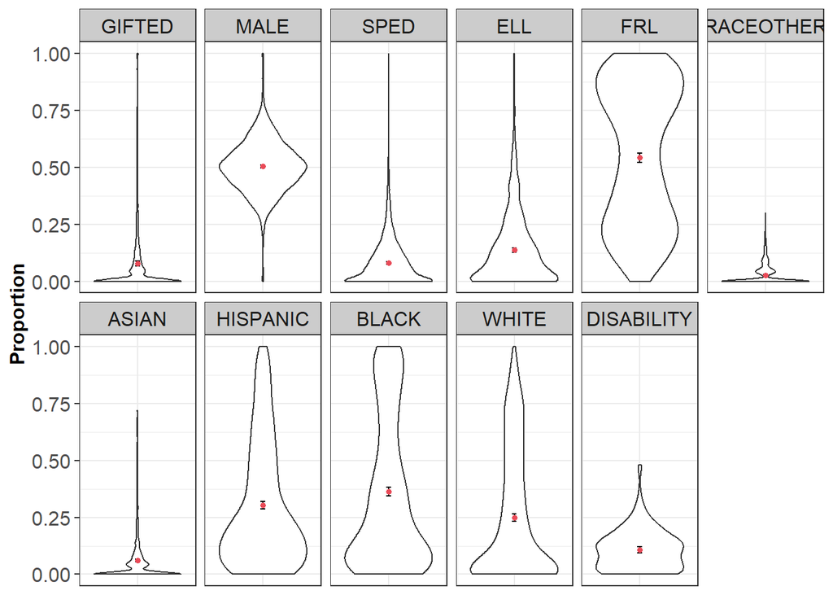

Note. The coral dots represent the weighted means. Error bars represent 95% CI.

Descriptive information on teachers teaching the class sections

| Characteristic | Count | Non-missing observations | Proportion of non-missing observations | Proportion of sample size |
| --- | --- | --- | --- | --- |
| DAD_MALE | 142 | 811 | 0.175 | 0.171 |
| DAD_WHITE | 458 | 809 | 0.566 | 0.550 |
| DAD_BLACK | 295 | 809 | 0.365 | 0.355 |
| DAD_HISPANIC | 40 | 809 | 0.049 | 0.048 |
| DAD_RACEOTHER | 16 | 809 | 0.020 | 0.019 |
| DAD_MASTERSPLUS | 267 | 633 | 0.422 | 0.321 |
| DAD_YRSEXP_NEW | 49 | 301 | 0.163 | 0.059 |
| DAD_YRSEXP_EARLY | 66 | 301 | 0.219 | 0.079 |
| DAD_YRSEXP_EST | 63 | 301 | 0.209 | 0.076 |
| DAD_YRSEXP_EXP | 74 | 301 | 0.246 | 0.089 |
| DAD_YRSEXP_HIGH | 49 | 301 | 0.163 | 0.059 |

Note. This table indicates the counts of teachers in the analytical sample that indicated a certain demographic characteristic. The information may be missing for some teachers in the total sample of 832 teachers.  
Experience was grouped as NEW = [0, 2] years, EARLY = (2, 5] years, EST = (5, 10] years, EXP = (10, 20] years, HIGH = (20, Inf) years.  
This table was saved as desc_Y1_all_teachers_cat.csv.

Descriptive information on teachers teaching the class sections (continued)

| Characteristic | Mean | SD | N |
| --- | --- | --- | --- |
| DAD_YRSEXP | 10.990 | 9.671 | 301 |
| FFT_CEV_adj | 2.666 | 0.208 | 832 |
| FFT_CERR_adj | 2.678 | 0.250 | 832 |
| FFT_ECL_adj | 2.540 | 0.228 | 832 |
| FFT_MCP_adj | 2.679 | 0.220 | 832 |
| FFT_MSB_adj | 2.768 | 0.247 | 832 |
| MQI_EI_adj | 1.246 | 0.077 | 832 |
| MQI_RICH_adj | 1.263 | 0.078 | 832 |
| MQI_WWSM_adj | 1.288 | 0.065 | 832 |
| MQI_SPMMR_adj | 1.214 | 0.093 | 832 |
| VA_SAM_adj | 0.011 | 0.195 | 832 |
| VA_BAM_adj | 0.009 | 0.190 | 832 |
| VA_NOAGGR_SAM_adj | 0.010 | 0.199 | 832 |
| VA_NOAGGR_BAM_adj | 0.008 | 0.196 | 832 |

Note. This table indicates mean and SD of teachers in the analytical sample that indicated a certain demographic characteristic. The information may be missing for some teachers in the total sample of 832 teachers.  
CEV, VA_SAM & VA_BAM represent teacher-level aggregates. FFT scores were adjusted at teacher level. VAMs were adjusted at section level and then aggregated at the teacher level using weighted means, accounting for the pupils included in the section-level VAMs.  
This table was saved as desc_Y1_all_teachers_num.csv.

Correlation of teaching experience with necessary condition and outcomes

| x | y | cor | ci_l | ci_u | df | t | p | N |
| --- | --- | --- | --- | --- | --- | --- | --- | --- |
| DAD_YRSEXP | FFT_CEV_adj_std | 0.209 | 0.098 | 0.314 | 299 | 3.693 | 0.000 | 301 |
| DAD_YRSEXP | FFT_CERR_adj_std | 0.141 | 0.028 | 0.250 | 299 | 2.461 | 0.014 | 301 |
| DAD_YRSEXP | FFT_ECL_adj_std | 0.149 | 0.036 | 0.258 | 299 | 2.603 | 0.010 | 301 |
| DAD_YRSEXP | FFT_MCP_adj_std | 0.198 | 0.086 | 0.304 | 299 | 3.486 | 0.001 | 301 |
| DAD_YRSEXP | FFT_MSB_adj_std | 0.251 | 0.142 | 0.354 | 299 | 4.485 | 0.000 | 301 |
| DAD_YRSEXP | MQI_EI_adj_std | 0.023 | -0.090 | 0.136 | 299 | 0.402 | 0.688 | 301 |
| DAD_YRSEXP | MQI_RICH_adj_std | 0.057 | -0.056 | 0.169 | 299 | 0.990 | 0.323 | 301 |
| DAD_YRSEXP | MQI_WWSM_adj_std | 0.045 | -0.068 | 0.158 | 299 | 0.787 | 0.432 | 301 |
| DAD_YRSEXP | MQI_SPMMR_adj_std | -0.065 | -0.177 | 0.048 | 299 | -1.126 | 0.261 | 301 |
| DAD_YRSEXP | VA_SAM_adj_std | -0.012 | -0.125 | 0.101 | 299 | -0.214 | 0.830 | 301 |
| DAD_YRSEXP | VA_BAM_adj_std | -0.064 | -0.176 | 0.049 | 299 | -1.113 | 0.266 | 301 |

Note. Data on DAD_YRSEXP is available for 301 teachers.  
This table was saved as cor_Y1_all_teaching_exp.csv.

#### **Figure**

#### *Relationship between teaching experience, necessary condition and outcomes*

Underlying count data for figure - Years of teaching experience

| DAD_YRSEXP_GRP | Domain | Mean | SD | N |
| --- | --- | --- | --- | --- |
| [0, 2] | CEV | -0.75 | 1.27 | 49 |
| [0, 2] | SAM | -0.14 | 0.97 | 49 |
| [0, 2] | BAM | -0.04 | 1.00 | 49 |
| (2, 5] | CEV | -0.07 | 1.02 | 66 |
| (2, 5] | SAM | -0.12 | 0.70 | 66 |
| (2, 5] | BAM | 0.02 | 0.67 | 66 |
| (5, 10] | CEV | 0.13 | 0.97 | 63 |
| (5, 10] | SAM | 0.16 | 0.70 | 63 |
| (5, 10] | BAM | -0.03 | 0.84 | 63 |
| (10, 20] | CEV | 0.22 | 0.89 | 74 |
| (10, 20] | SAM | -0.11 | 0.76 | 74 |
| (10, 20] | BAM | -0.05 | 0.81 | 74 |
| (20, Inf) | CEV | 0.23 | 0.86 | 49 |
| (20, Inf) | SAM | -0.11 | 0.91 | 49 |
| (20, Inf) | BAM | -0.10 | 0.76 | 49 |

#### **Figure**

#### *Relationship between teaching experience, necessary condition and outcomes*

[figure not shown]

Within vs between school variation - teacher level

| Domain | avg_within_sd | within_var | between_sd | between_var | total_var | within_pct | between_pct |
| --- | --- | --- | --- | --- | --- | --- | --- |
| FFT_CEV_adj | 0.148 | 0.031 | 0.166 | 0.028 | 0.059 | 0.529 | 0.471 |
| VA_BAM_adj | 0.147 | 0.030 | 0.126 | 0.016 | 0.046 | 0.654 | 0.346 |
| VA_SAM_adj | 0.145 | 0.029 | 0.141 | 0.020 | 0.049 | 0.596 | 0.404 |

Note. Data is available for 832 Teachers avg_within_sd is the average within-school SD. between_sd is the SD of school means. Classrooms were aggregated at teacher-level before aggregating at school level.

## Framework for Teaching (FFT)

Segment-level data is available for 6588 lesson segments.

Underlying count data for Observation score distributions figure

| item | domain | value | count | prop |
| --- | --- | --- | --- | --- |
| CERR | Classroom environment (FFT_CEV) | 1 | 183 | 0.0277778 |
| CERR | Classroom environment (FFT_CEV) | 2 | 1194 | 0.1812386 |
| CERR | Classroom environment (FFT_CEV) | 3 | 2792 | 0.4238009 |
| CERR | Classroom environment (FFT_CEV) | 4 | 143 | 0.0217061 |
| CERR | Classroom environment (FFT_CEV) |  | 2276 | 0.3454766 |
| ECL | Classroom environment (FFT_CEV) | 1 | 161 | 0.0244384 |
| ECL | Classroom environment (FFT_CEV) | 2 | 1776 | 0.2695811 |
| ECL | Classroom environment (FFT_CEV) | 3 | 2216 | 0.3363692 |
| ECL | Classroom environment (FFT_CEV) | 4 | 108 | 0.0163934 |
| ECL | Classroom environment (FFT_CEV) |  | 2327 | 0.3532180 |
| MCP | Classroom environment (FFT_CEV) | 1 | 199 | 0.0302064 |
| MCP | Classroom environment (FFT_CEV) | 2 | 1169 | 0.1774438 |
| MCP | Classroom environment (FFT_CEV) | 3 | 2762 | 0.4192471 |
| MCP | Classroom environment (FFT_CEV) | 4 | 131 | 0.0198846 |
| MCP | Classroom environment (FFT_CEV) |  | 2327 | 0.3532180 |
| MSB | Classroom environment (FFT_CEV) | 1 | 151 | 0.0229205 |
| MSB | Classroom environment (FFT_CEV) | 2 | 932 | 0.1414693 |
| MSB | Classroom environment (FFT_CEV) | 3 | 3004 | 0.4559806 |
| MSB | Classroom environment (FFT_CEV) | 4 | 196 | 0.0297511 |
| MSB | Classroom environment (FFT_CEV) |  | 2305 | 0.3498786 |

Note. The data shows the count of lesson video segments that have received a certain rating value for each component of the observation instrument.

#### **Figure**

#### *Distribution of observation scores*

[figure not shown]

#### **Figure**

#### *Unadjusted observation scores aggregated at teacher level*

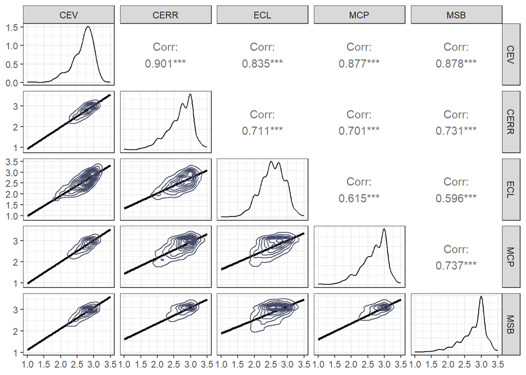

#### **Figure**

#### *Unadjusted observation scores aggregated at teacher level*

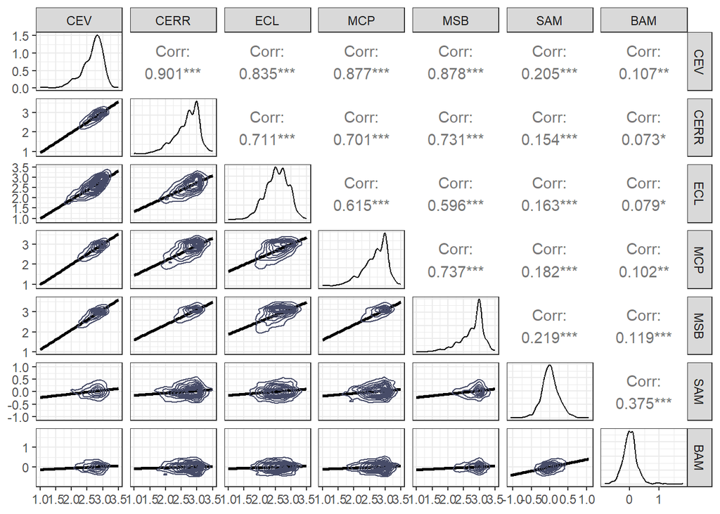

#### **Figure**

#### *Raw and adjusted observation scores*

[figure not shown]

Raw and adjusted observation scores

| Domain | Mean | SD | Mean_adj | SD_adj |
| --- | --- | --- | --- | --- |
| FFT_CEV | 2.670 | 0.338 | 2.666 | 0.208 |
| FFT_CERR | 2.681 | 0.394 | 2.678 | 0.250 |
| FFT_ECL | 2.542 | 0.377 | 2.540 | 0.228 |
| FFT_MCP | 2.684 | 0.395 | 2.679 | 0.220 |
| FFT_MSB | 2.772 | 0.383 | 2.768 | 0.247 |

Note. Data from 832 teachers is included.  
FFT_CEV refers to the domain scores for classroom environment, computed as the mean of their indicators.  
This table was saved as desc_Y1_all_FFT_adj.csv.

#### **Figure**

#### *Adjusted observation scores aggregated at teacher level*

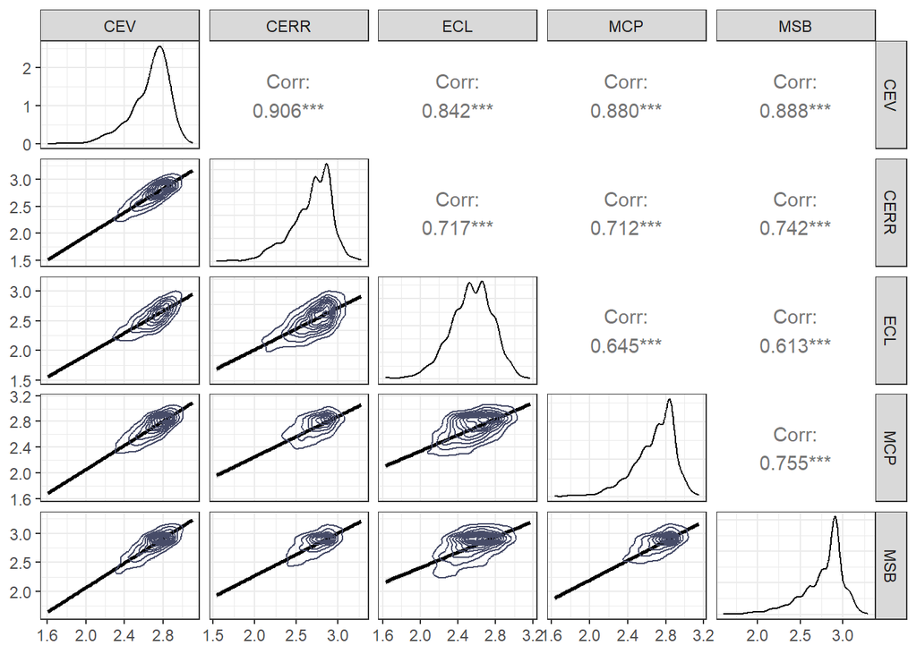

#### **Figure**

#### *Adjusted observation scores aggregated at teacher level*

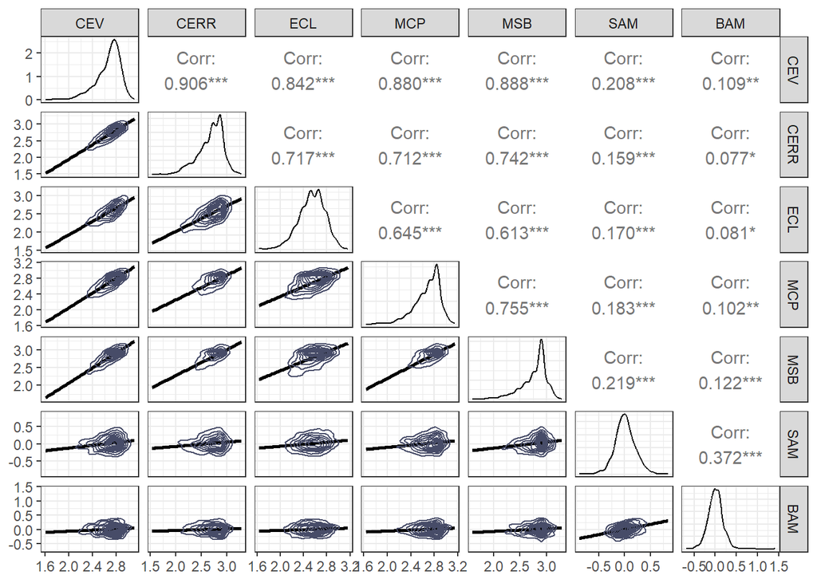

## Mathematical Quality of Instruction (MQI)

Segment-level data is available for 21716 lesson segments.

Underlying count data for Observation score distributions figure

| item | domain | value | count | prop |
| --- | --- | --- | --- | --- |
| EI | Teacher-content relationship | 1 | 13176 | 0.6067416 |
| EI | Teacher-content relationship | 2 | 3261 | 0.1501658 |
| EI | Teacher-content relationship | 3 | 527 | 0.0242678 |
| EI | Teacher-content relationship |  | 4752 | 0.2188248 |
| RICH | Teacher-content relationship | 1 | 12360 | 0.5691656 |
| RICH | Teacher-content relationship | 2 | 3970 | 0.1828145 |
| RICH | Teacher-content relationship | 3 | 230 | 0.0105913 |
| RICH | Teacher-content relationship |  | 5156 | 0.2374286 |
| WWSM | Teacher-pupil relationship | 1 | 11939 | 0.5497790 |
| WWSM | Teacher-pupil relationship | 2 | 4385 | 0.2019248 |
| WWSM | Teacher-pupil relationship | 3 | 236 | 0.0108676 |
| WWSM | Teacher-pupil relationship |  | 5156 | 0.2374286 |
| SPMMR | Pupil-content relationship | 1 | 13250 | 0.6101492 |
| SPMMR | Pupil-content relationship | 2 | 3080 | 0.1418309 |
| SPMMR | Pupil-content relationship | 3 | 230 | 0.0105913 |
| SPMMR | Pupil-content relationship |  | 5156 | 0.2374286 |

Note. The data shows the count of lesson video segments that have received a certain rating value for each component of the observation instrument.

#### **Figure**

#### *Distribution of observation scores*

[figure not shown]

#### **Figure**

#### *Unadjusted observation scores aggregated at teacher level*

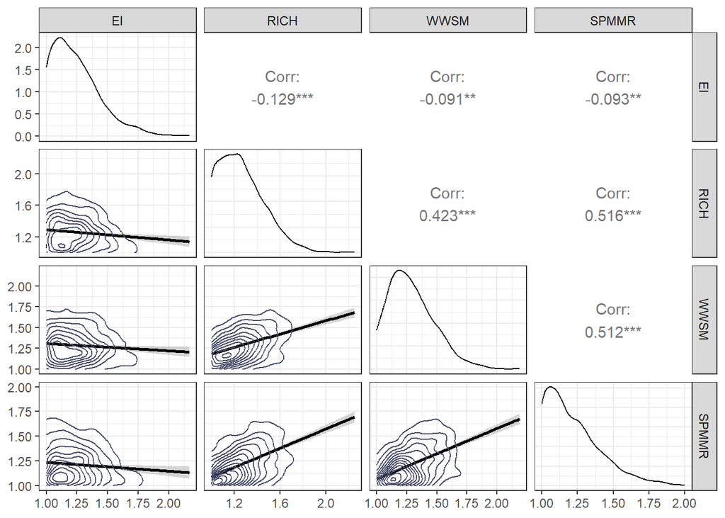

#### **Figure**

#### *Unadjusted observation scores aggregated at teacher level*

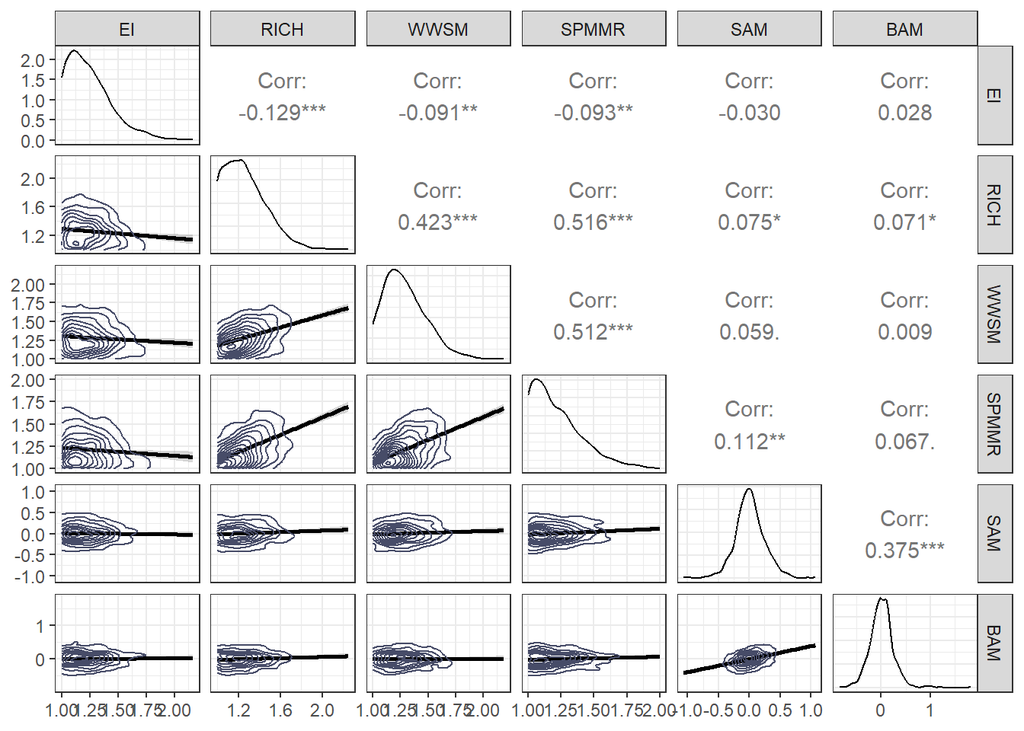

#### **Figure**

#### *Raw and adjusted observation scores*

[figure not shown]

Raw and adjusted observation scores

| Domain | Mean | SD | Mean_adj | SD_adj |
| --- | --- | --- | --- | --- |
| MQI_EI | 1.244 | 0.199 | 1.246 | 0.077 |
| MQI_RICH | 1.262 | 0.202 | 1.263 | 0.078 |
| MQI_WWSM | 1.288 | 0.191 | 1.288 | 0.065 |
| MQI_SPMMR | 1.214 | 0.191 | 1.214 | 0.093 |

#### **Figure**

#### *Adjusted observation scores aggregated at teacher level*

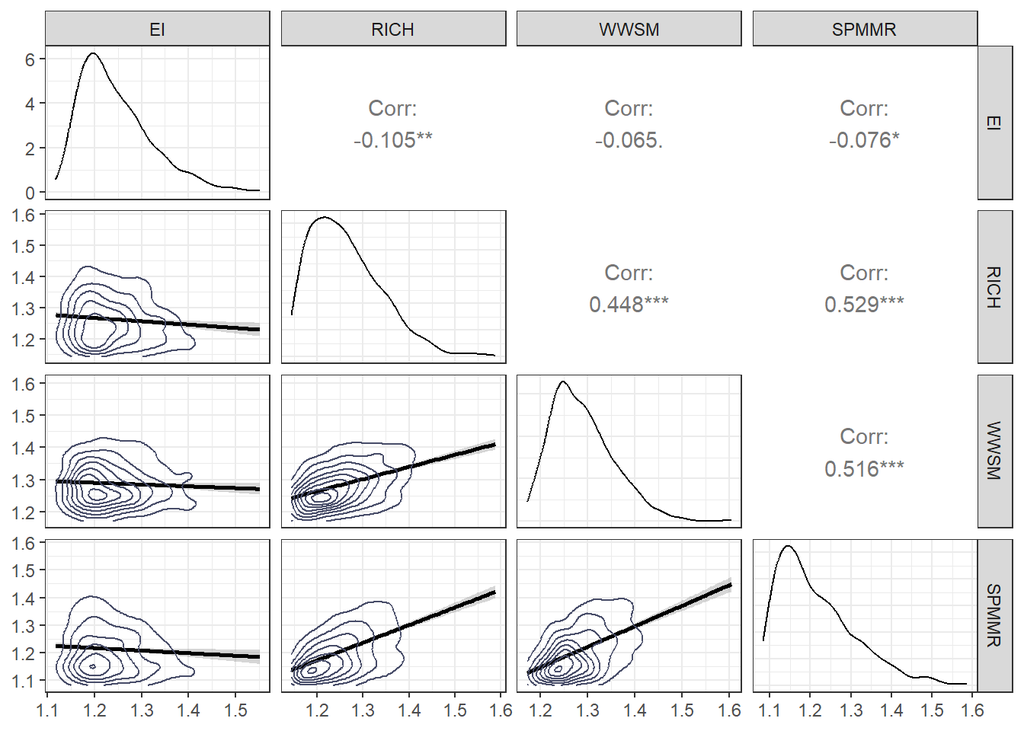

#### **Figure**

#### *Adjusted observation scores aggregated at teacher level*

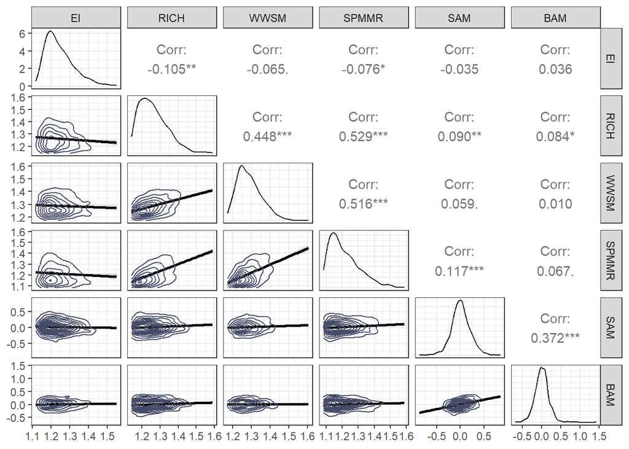

## Overall effect of observation score adjustment

Observation score adjustment

|  | Aggregation to teacher level N_SCORE | Aggregation to teacher level N_RATER | Aggregation to teacher level N_SEGMENT | Aggregation to teacher level N_LESSON | Aggregation to teacher level N_SECTION | Observed RELIABILITY | Observed SAMPLE | Hypothetical MIN_SCORE_ADJ | Hypothetical MAX_SCORE_ADJ |
| --- | --- | --- | --- | --- | --- | --- | --- | --- | --- |
| FFT_CERR | 5.18 (2.22) | 5.08 (2.10) | 3.84 (0.60) | 3.84 (0.60) | 1.39 (0.49) | 0.63 (0.08) | 2.68 (0.39) | 1.62 | 3.51 |
| FFT_ECL | 5.12 (2.13) | 5.05 (2.06) | 3.84 (0.60) | 3.84 (0.60) | 1.39 (0.49) | 0.60 (0.08) | 2.54 (0.38) | 1.61 | 3.42 |
| FFT_MCP | 5.12 (2.13) | 5.05 (2.06) | 3.84 (0.60) | 3.84 (0.60) | 1.39 (0.49) | 0.55 (0.08) | 2.68 (0.40) | 1.76 | 3.41 |
| FFT_MSB | 5.15 (2.18) | 5.04 (2.03) | 3.84 (0.60) | 3.84 (0.60) | 1.39 (0.49) | 0.63 (0.07) | 2.77 (0.38) | 1.65 | 3.55 |
| MQI_EI | 20.39 (9.86) | 4.84 (2.14) | 14.71 (3.00) | 3.68 (0.75) | 1.39 (0.49) | 0.40 (0.09) | 1.24 (0.20) | 1.15 | 1.95 |
| MQI_RICH | 19.90 (9.08) | 4.73 (1.97) | 14.76 (2.97) | 3.69 (0.74) | 1.39 (0.49) | 0.40 (0.07) | 1.26 (0.20) | 1.16 | 1.95 |
| MQI_WWSM | 19.90 (9.08) | 4.73 (1.97) | 14.76 (2.97) | 3.69 (0.74) | 1.39 (0.49) | 0.35 (0.07) | 1.29 (0.19) | 1.19 | 1.89 |
| MQI_SPMMR | 19.90 (9.08) | 4.73 (1.97) | 14.76 (2.97) | 3.69 (0.74) | 1.39 (0.49) | 0.50 (0.08) | 1.21 (0.19) | 1.11 | 2.11 |

Note. Data from 832 teachers is included.  
Table shows the counts as M (SD) of scores, raters, segments, lessons and sections that were aggregated to derive a single score at the teacher level.  
These counts informed the calculation of the reliability coefficients. Together with the observed sample mean (SD), the reliability coefficients were used to calculate the smallest and largest observation score that was hypothetically possible following adjustment.  
This table was saved as desc_Y1_all_shrinkage.csv.

## Value-added measures

Value-added scores

| VAM | Mean | SD | N Teachers |
| --- | --- | --- | --- |
| VA_SAM | 0.01 | 0.24 | 832 |
| VA_BAM | 0.01 | 0.25 | 832 |
| VA_NOAGGR_SAM | 0.01 | 0.24 | 832 |
| VA_NOAGGR_BAM | 0.01 | 0.25 | 832 |
| VA_SAM_SE | 0.10 | 0.02 | 832 |
| VA_SAM_N | 28.71 | 11.16 | 832 |
| VA_BAM_SE | 0.13 | 0.02 | 832 |
| VA_BAM_N | 24.66 | 9.49 | 832 |
| VA_NOAGGR_SAM_SE | 0.10 | 0.02 | 832 |
| VA_NOAGGR_SAM_N | 28.71 | 11.16 | 832 |
| VA_NOAGGR_BAM_SE | 0.13 | 0.02 | 832 |
| VA_NOAGGR_BAM_N | 24.66 | 9.49 | 832 |
| VA_SAM_rel | 0.85 | 0.05 | 832 |
| VA_SAM_adj | 0.01 | 0.19 | 832 |
| VA_BAM_rel | 0.78 | 0.06 | 832 |
| VA_BAM_adj | 0.01 | 0.19 | 832 |
| VA_NOAGGR_SAM_rel | 0.85 | 0.05 | 832 |
| VA_NOAGGR_SAM_adj | 0.01 | 0.20 | 832 |
| VA_NOAGGR_BAM_rel | 0.79 | 0.06 | 832 |
| VA_NOAGGR_BAM_adj | 0.01 | 0.20 | 832 |
| VA_SAM_std | 0.00 | 1.00 | 832 |
| VA_SAM_adj_std | 0.00 | 1.00 | 832 |
| VA_BAM_std | 0.00 | 1.00 | 832 |
| VA_BAM_adj_std | 0.00 | 1.00 | 832 |
| VA_NOAGGR_SAM_std | 0.00 | 1.00 | 832 |
| VA_NOAGGR_SAM_adj_std | 0.00 | 1.00 | 832 |
| VA_NOAGGR_BAM_std | 0.00 | 1.00 | 832 |
| VA_NOAGGR_BAM_adj_std | 0.00 | 1.00 | 832 |

Note.

#### **Figure**

#### *Raw and adjusted VA scores*

[figure not shown]

TVA score adjustment

|  | RELIABILITY | SAMPLE |
| --- | --- | --- |
| VA_SAM | 0.85 (0.05) | 0.01 (0.24) |
| VA_BAM | 0.78 (0.06) | 0.01 (0.25) |
| VA_NOAGGR_SAM | 0.85 (0.05) | 0.01 (0.24) |
| VA_NOAGGR_BAM | 0.79 (0.06) | 0.01 (0.25) |

Note. Data from 1156 classrooms is included.  
Table shows reliability and observed scores as M (SD).

## Intercorrelation matrix

[figure not shown]

Correlation of variables at teacher level

|  | CEV | CERR | ECL | MCP | MSB | EI | RICH | WWSM | SPMMR | SAM | BAM | SAM(*) | BAM(*) | YRSEXP |
| --- | --- | --- | --- | --- | --- | --- | --- | --- | --- | --- | --- | --- | --- | --- |
| CEV | r = 1.00 (p <.001) | r = .90 (p <.001) | r = .83 (p <.001) | r = .88 (p <.001) | r = .88 (p <.001) | r = .04 (p = 1) | r = .22 (p <.001) | r = .18 (p <.001) | r = .30 (p <.001) | r = .21 (p <.001) | r = .11 (p = .104) | r = .22 (p <.001) | r = .14 (p = .002) | r = .21 (p = .019) |
| CERR | r = .91 (p <.001) | r = 1.00 (p <.001) | r = .71 (p <.001) | r = .70 (p <.001) | r = .73 (p <.001) | r = .05 (p = 1) | r = .19 (p <.001) | r = .18 (p <.001) | r = .28 (p <.001) | r = .15 (p <.001) | r = .07 (p = .956) | r = .17 (p <.001) | r = .10 (p = .130) | r = .14 (p = .532) |
| ECL | r = .84 (p <.001) | r = .72 (p <.001) | r = 1.00 (p <.001) | r = .62 (p <.001) | r = .60 (p <.001) | r = -.02 (p = 1) | r = .25 (p <.001) | r = .24 (p <.001) | r = .33 (p <.001) | r = .16 (p <.001) | r = .08 (p = .703) | r = .18 (p <.001) | r = .11 (p = .051) | r = .15 (p = .425) |
| MCP | r = .88 (p <.001) | r = .71 (p <.001) | r = .65 (p <.001) | r = 1.00 (p <.001) | r = .74 (p <.001) | r = .06 (p = 1) | r = .17 (p <.001) | r = .10 (p = .131) | r = .23 (p <.001) | r = .18 (p <.001) | r = .10 (p = .144) | r = .19 (p <.001) | r = .13 (p = .008) | r = .20 (p = .038) |
| MSB | r = .89 (p <.001) | r = .74 (p <.001) | r = .61 (p <.001) | r = .75 (p <.001) | r = 1.00 (p <.001) | r = .05 (p = 1) | r = .15 (p = .002) | r = .12 (p = .022) | r = .21 (p <.001) | r = .22 (p <.001) | r = .12 (p = .036) | r = .23 (p <.001) | r = .15 (p = .001) | r = .25 (p = .001) |
| EI | r = .05 (p = .205) | r = .05 (p = .219) | r = .01 (p = .940) | r = .07 (p = .083) | r = .05 (p = .183) | r = 1.00 (p <.001) | r = -.13 (p = .014) | r = -.09 (p = .342) | r = -.09 (p = .306) | r = -.03 (p = 1) | r = .03 (p = 1) | r = -.05 (p = 1) | r = .02 (p = 1) | r = .03 (p = 1) |
| RICH | r = .24 (p <.001) | r = .21 (p <.001) | r = .27 (p <.001) | r = .19 (p <.001) | r = .17 (p <.001) | r = -.11 (p = .004) | r = 1.00 (p <.001) | r = .42 (p <.001) | r = .52 (p <.001) | r = .07 (p = .897) | r = .07 (p = 1) | r = .09 (p = .452) | r = .09 (p = .452) | r = .06 (p = 1) |
| WWSM | r = .19 (p <.001) | r = .19 (p <.001) | r = .24 (p <.001) | r = .11 (p = .003) | r = .13 (p <.001) | r = -.07 (p = .085) | r = .45 (p <.001) | r = 1.00 (p <.001) | r = .51 (p <.001) | r = .06 (p = 1) | r = .01 (p = 1) | r = .07 (p = 1) | r = .02 (p = 1) | r = .04 (p = 1) |
| SPMMR | r = .31 (p <.001) | r = .28 (p <.001) | r = .34 (p <.001) | r = .23 (p <.001) | r = .22 (p <.001) | r = -.08 (p = .042) | r = .53 (p <.001) | r = .52 (p <.001) | r = 1.00 (p <.001) | r = .11 (p = .068) | r = .07 (p = 1) | r = .14 (p = .006) | r = .09 (p = .342) | r = -.07 (p = 1) |
| SAM | r = .21 (p <.001) | r = .16 (p <.001) | r = .17 (p <.001) | r = .18 (p <.001) | r = .22 (p <.001) | r = -.03 (p = .391) | r = .09 (p = .014) | r = .06 (p = .119) | r = .12 (p = .001) | r = 1.00 (p <.001) | r = .38 (p <.001) | r = .98 (p <.001) | r = .37 (p <.001) | r = -.02 (p = 1) |
| BAM | r = .11 (p = .003) | r = .08 (p = .039) | r = .08 (p = .030) | r = .10 (p = .005) | r = .12 (p <.001) | r = .04 (p = .368) | r = .08 (p = .023) | r = .01 (p = .885) | r = .07 (p = .077) | r = .37 (p <.001) | r = 1.00 (p <.001) | r = .37 (p <.001) | r = .98 (p <.001) | r = -.07 (p = 1) |
| SAM(*) | r = .22 (p <.001) | r = .18 (p <.001) | r = .19 (p <.001) | r = .20 (p <.001) | r = .23 (p <.001) | r = -.05 (p = .171) | r = .10 (p = .005) | r = .07 (p = .076) | r = .14 (p <.001) | r = .98 (p <.001) | r = .36 (p <.001) | r = 1.00 (p <.001) | r = .39 (p <.001) | r = -.02 (p = 1) |
| BAM(*) | r = .15 (p <.001) | r = .11 (p = .003) | r = .12 (p = .001) | r = .14 (p <.001) | r = .15 (p <.001) | r = .03 (p = .535) | r = .10 (p = .007) | r = .02 (p = .738) | r = .09 (p = .012) | r = .37 (p <.001) | r = .98 (p <.001) | r = .39 (p <.001) | r = 1.00 (p <.001) | r = -.07 (p = 1) |
| YRSEXP | r = .21 (p <.001) | r = .14 (p = .022) | r = .15 (p = .015) | r = .20 (p = .001) | r = .25 (p <.001) | r = .02 (p = .798) | r = .06 (p = .396) | r = .05 (p = .519) | r = -.07 (p = .332) | r = -.01 (p = .946) | r = -.06 (p = .337) | r = -.01 (p = .947) | r = -.07 (p = .324) | r = 1.00 (p <.001) |

Note. Data is available for 832 teachers, of which 301had non-missing data for DAD_YRSEXP. The upper triangle uses raw data whereas the lower triangle uses adjusted data. All p values were adjusted using the FDR method.  
This table was saved as cor_Y1_all.csv.

## Main NCA analysis

OLS coefficients

| Observation score | Model 1 B | Model 1 SE_B | Model 1 β | Model 1 SE | Model 1 t | Model 1 p | Model 1 R2 | Model 1 R2_adj | Model 1 F | Model 1 numdf | Model 1 dendf | Model 1 p (F) | Model 2 B | Model 2 SE_B | Model 2 β | Model 2 SE | Model 2 t | Model 2 p | Model 2 R2 | Model 2 R2_adj | Model 2 F | Model 2 numdf | Model 2 dendf | Model 2 p (F) |
| --- | --- | --- | --- | --- | --- | --- | --- | --- | --- | --- | --- | --- | --- | --- | --- | --- | --- | --- | --- | --- | --- | --- | --- | --- |
| VA_SAM_adj_std |  |  |  |  |  |  |  |  |  |  |  |  |  |  |  |  |  |  |  |  |  |  |  |  |
| CEV | 1.00 | 0.16 | 0.21 | 0.03 | 6.117 | <.001 | 0.04% | 0.04% | 37.416 | 1 | 830 | <.001 |  |  |  |  |  |  |  |  |  |  |  |  |
| CERR | 0.63 | 0.14 | 0.16 | 0.03 | 4.635 | <.001 | 0.03% | 0.02% | 21.479 | 1 | 830 | <.001 | -0.25 | 0.24 | -0.06 | 0.06 | -1.035 | .301 | 0.05% | 0.05% | 11.167 | 4 | 827 | <.001 |
| ECL | 0.74 | 0.15 | 0.17 | 0.03 | 4.961 | <.001 | 0.03% | 0.03% | 24.614 | 1 | 830 | <.001 | 0.32 | 0.22 | 0.07 | 0.05 | 1.455 | .146 | 0.05% | 0.05% | 11.167 | 4 | 827 | <.001 |
| MCP | 0.83 | 0.15 | 0.18 | 0.03 | 5.365 | <.001 | 0.03% | 0.03% | 28.779 | 1 | 830 | <.001 | 0.15 | 0.26 | 0.03 | 0.06 | 0.574 | .566 | 0.05% | 0.05% | 11.167 | 4 | 827 | <.001 |
| MSB | 0.88 | 0.14 | 0.22 | 0.03 | 6.456 | <.001 | 0.05% | 0.05% | 41.682 | 1 | 830 | <.001 | 0.79 | 0.23 | 0.19 | 0.06 | 3.377 | <.001 | 0.05% | 0.05% | 11.167 | 4 | 827 | <.001 |
| VA_BAM_adj_std |  |  |  |  |  |  |  |  |  |  |  |  |  |  |  |  |  |  |  |  |  |  |  |  |
| CEV | 0.52 | 0.17 | 0.11 | 0.03 | 3.145 | .002 | 0.01% | 0.01% | 9.894 | 1 | 830 | .002 |  |  |  |  |  |  |  |  |  |  |  |  |
| CERR | 0.31 | 0.14 | 0.08 | 0.03 | 2.228 | .026 | 0.01% | 0.00% | 4.963 | 1 | 830 | .026 | -0.22 | 0.24 | -0.05 | 0.06 | -0.895 | .371 | 0.02% | 0.01% | 3.379 | 4 | 827 | .009 |
| ECL | 0.35 | 0.15 | 0.08 | 0.03 | 2.335 | .020 | 0.01% | 0.01% | 5.452 | 1 | 830 | .020 | 0.10 | 0.23 | 0.02 | 0.05 | 0.448 | .654 | 0.02% | 0.01% | 3.379 | 4 | 827 | .009 |
| MCP | 0.46 | 0.16 | 0.10 | 0.03 | 2.948 | .003 | 0.01% | 0.01% | 8.688 | 1 | 830 | .003 | 0.14 | 0.26 | 0.03 | 0.06 | 0.553 | .581 | 0.02% | 0.01% | 3.379 | 4 | 827 | .009 |
| MSB | 0.49 | 0.14 | 0.12 | 0.03 | 3.544 | <.001 | 0.01% | 0.01% | 12.559 | 1 | 830 | <.001 | 0.50 | 0.24 | 0.12 | 0.06 | 2.114 | .035 | 0.02% | 0.01% | 3.379 | 4 | 827 | .009 |

Note. Data from 832 teachers is included. In model 1, each predictor was entered seperately. In model 2, all predictors were entered together.  
This table was saved as coef_Y1_all_main_ols.csv

NCA parameters

| Metric | FFT_CEV_adj | FFT_CERR_adj | FFT_ECL_adj | FFT_MCP_adj | FFT_MSB_adj |
| --- | --- | --- | --- | --- | --- |
| VA_SAM_adj_std |  |  |  |  |  |
| Number of observations | 832 | 832 | 832 | 832 | 832 |
| Scope | 13.30 [63.92] | 15.37 [61.43] | 13.56 [59.50] | 13.41 [60.87] | 14.94 [60.41] |
| Ceiling zone | 3.45 [16.60] | 3.38 [13.51] | 2.38 [10.46] | 3.78 [17.17] | 3.83 [15.51] |
| Effect size | .26 | .22 | .18 | .28 | .26 |
| p value (unadj.) | .009 | .030 | .120 | .000 | .002 |
| p value (adj.) | .018 | .040 | .120 | .000 | .004 |
| p accuracy | .002 | .003 | .006 | .000 | .001 |
| Slope | 4.71 [0.98] | 4.28 [1.07] | 7.03 [1.60] | 3.74 [0.82] | 3.43 [0.85] |
| Intercept | -8.95 [3.62] | -7.68 [3.79] | -12.96 [4.90] | -7.12 [2.90] | -6.32 [3.18] |
| Fit | 92.26% | 96.24% | 87.65% | 95.41% | 96.87% |
| Ceiling accuracy | 99.52% (828) | 99.52% (828) | 99.40% (827) | 98.68% (821) | 99.40% (827) |
| Noise | 0.50% (4) | 0.40% (3) | 0.60% (5) | 1.20% (10) | 0.60% (5) |
| Exceptions | 0.00% (0) | 0.10% (1) | 0.00% (0) | 0.10% (1) | 0.00% (0) |
| Support | 9.40% (78) | 8.80% (73) | 6.10% (51) | 17.90% (149) | 11.20% (93) |
| Spread | .30 | .27 | .22 | .28 | .30 |
| Sharpness | .95 | .96 | .91 | .94 | .95 |
| Relative inefficiency | 48.07% | 56.01% | 64.83% | 43.57% | 48.66% |
| Condition inefficiency | 19.50% | 27.72% | 46.29% | 6.21% | 11.48% |
| Outcome inefficiency | 35.49% | 39.14% | 34.52% | 39.84% | 42.01% |
| VA_BAM_adj_std |  |  |  |  |  |
| Number of observations | 832 | 832 | 832 | 832 | 832 |
| Scope | 16.69 [80.25] | 19.29 [77.13] | 17.03 [74.70] | 16.83 [76.41] | 18.75 [75.85] |
| Ceiling zone | 5.43 [26.10] | 5.93 [23.69] | 3.45 [15.14] | 4.64 [21.08] | 6.44 [26.03] |
| Effect size | .33 | .31 | .20 | .28 | .34 |
| p value (unadj.) | .470 | .348 | .764 | .649 | .217 |
| p value (adj.) | .470 | .696 | .764 | .764 | .696 |
| p accuracy | .010 | .009 | .008 | .009 | .008 |
| Slope | 8.07 [1.68] | 6.52 [1.63] | 10.47 [2.39] | 7.88 [1.74] | 5.37 [1.33] |
| Intercept | -14.85 [6.66] | -11.40 [6.06] | -18.15 [8.45] | -13.99 [7.13] | -9.47 [5.39] |
| Fit | 91.06% | 92.45% | 98.17% | 80.56% | 90.89% |
| Ceiling accuracy | 99.52% (828) | 99.52% (828) | 99.64% (829) | 99.64% (829) | 99.64% (829) |
| Noise | 0.40% (3) | 0.50% (4) | 0.20% (2) | 0.40% (3) | 0.20% (2) |
| Exceptions | 0.10% (1) | 0.00% (0) | 0.10% (1) | 0.00% (0) | 0.10% (1) |
| Support | 3.50% (29) | 6.00% (50) | 2.00% (17) | 2.60% (22) | 5.20% (43) |
| Spread | .39 | .31 | .28 | .34 | .39 |
| Sharpness | .91 | .93 | .89 | .88 | .96 |
| Relative inefficiency | 34.95% | 38.57% | 59.46% | 44.82% | 31.36% |
| Condition inefficiency | 22.84% | 22.39% | 47.06% | 28.39% | 8.31% |
| Outcome inefficiency | 15.69% | 20.85% | 23.43% | 22.95% | 25.15% |

Note. Data from 832 teachers is included. NCA ceiling line = CR-FDH. Fit values of N/A indicate cases where the CR-FDH ceiling zone exceeds the CE-FDH ceiling zone, resulting in a negative closeness percentage that is not conceptually interpretable. This occurs when the straight-line CR-FDH approximation creates a larger empty space than the CE-FDH step-function boundary and does not invalidate effect sizes or ceiling accuracy.  
p values were estimated using 10000 permutations.  
This table was saved as coef_Y1_all_main_nca.csv

#### **Figure**

#### *NCA Plot: VAMs - CEV*

[figure not shown]

#### **Figure**

#### *NCA Plot: FFT indicators - SAM*

[figure not shown]

#### **Figure**

#### *NCA Plot: FFT indicators - BAM*

[figure not shown]

NCA bottlenecks

| Ouctome | FFT_CEV_adj Adj. | FFT_CEV_adj Adj. std. | FFT_CEV_adj % range | FFT_CEV_adj Percentile | FFT_CERR_adj Adj. | FFT_CERR_adj Adj. std. | FFT_CERR_adj % range | FFT_CERR_adj Percentile | FFT_ECL_adj Adj. | FFT_ECL_adj Adj. std. | FFT_ECL_adj % range | FFT_ECL_adj Percentile | FFT_MCP_adj Adj. | FFT_MCP_adj Adj. std. | FFT_MCP_adj % range | FFT_MCP_adj Percentile | FFT_MSB_adj Adj. | FFT_MSB_adj Adj. std. | FFT_MSB_adj % range | FFT_MSB_adj Percentile |
| --- | --- | --- | --- | --- | --- | --- | --- | --- | --- | --- | --- | --- | --- | --- | --- | --- | --- | --- | --- | --- |
| VA_SAM_adj_std |  |  |  |  |  |  |  |  |  |  |  |  |  |  |  |  |  |  |  |  |
| -4 | NN | NN | NN | NN | NN | NN | NN | NN | NN | NN | NN | NN | NN | NN | NN | NN | NN | NN | NN | NN |
| -3.5 | NN | NN | NN | NN | NN | NN | NN | NN | NN | NN | NN | NN | NN | NN | NN | NN | NN | NN | NN | NN |
| -3 | NN | NN | NN | NN | NN | NN | NN | NN | NN | NN | NN | NN | NN | NN | NN | NN | NN | NN | NN | NN |
| -2.5 | NN | NN | NN | NN | NN | NN | NN | NN | NN | NN | NN | NN | NN | NN | NN | NN | NN | NN | NN | NN |
| -2 | NN | NN | NN | NN | NN | NN | NN | NN | NN | NN | NN | NN | NN | NN | NN | NN | NN | NN | NN | NN |
| -1.5 | NN | NN | NN | NN | NN | NN | NN | NN | NN | NN | NN | NN | NN | NN | NN | NN | NN | NN | NN | NN |
| -1 | 1.687 | -4.710 | 5.6 | 0.1 | 1.559 | -4.473 | 1.0 | 0.1 | 1.701 | -3.683 | 4.5 | 0.4 | 1.636 | -4.734 | 0.2 | 0.1 | NN | NN | NN | NN |
| -0.5 | 1.793 | -4.200 | 12.6 | 0.4 | 1.676 | -4.006 | 7.7 | 0.4 | 1.772 | -3.371 | 9.1 | 0.4 | 1.770 | -4.127 | 9.0 | 0.1 | 1.695 | -4.338 | 5.5 | 0.1 |
| 0 | 1.899 | -3.691 | 19.7 | 0.6 | 1.793 | -3.540 | 14.4 | 0.5 | 1.843 | -3.059 | 13.7 | 0.6 | 1.904 | -3.520 | 17.8 | 0.8 | 1.841 | -3.749 | 14.1 | 0.4 |
| 0.5 | 2.005 | -3.181 | 26.7 | 1.0 | 1.909 | -3.073 | 21.1 | 0.7 | 1.914 | -2.747 | 18.4 | 1.0 | 2.037 | -2.914 | 26.6 | 1.4 | 1.987 | -3.159 | 22.8 | 1.3 |
| 1 | 2.111 | -2.671 | 33.8 | 1.8 | 2.026 | -2.607 | 27.8 | 1.4 | 1.985 | -2.435 | 23.0 | 1.6 | 2.171 | -2.307 | 35.4 | 2.8 | 2.133 | -2.570 | 31.4 | 2.3 |
| 1.5 | 2.217 | -2.161 | 40.9 | 3.8 | 2.143 | -2.140 | 34.5 | 3.7 | 2.056 | -2.123 | 27.6 | 2.5 | 2.304 | -1.700 | 44.3 | 5.5 | 2.279 | -1.980 | 40.0 | 5.6 |
| 2 | 2.323 | -1.651 | 47.9 | 7.0 | 2.259 | -1.674 | 41.3 | 6.6 | 2.127 | -1.811 | 32.3 | 4.7 | 2.438 | -1.094 | 53.1 | 12.0 | 2.424 | -1.390 | 48.7 | 9.1 |
| 2.5 | 2.429 | -1.141 | 55.0 | 13.1 | 2.376 | -1.207 | 48.0 | 11.9 | 2.199 | -1.499 | 36.9 | 6.2 | 2.572 | -0.487 | 61.9 | 24.2 | 2.570 | -0.801 | 57.3 | 17.5 |
| 3 | 2.535 | -0.631 | 62.0 | 21.4 | 2.493 | -0.741 | 54.7 | 19.8 | 2.270 | -1.187 | 41.6 | 13.3 | 2.705 | 0.120 | 70.7 | 41.6 | 2.716 | -0.211 | 65.9 | 31.5 |
| 3.5 | 2.641 | -0.121 | 69.1 | 35.0 | 2.609 | -0.275 | 61.4 | 34.9 | 2.341 | -0.875 | 46.2 | 17.1 | 2.839 | 0.726 | 79.5 | 69.0 | 2.862 | 0.378 | 74.5 | 50.7 |
| 4 | 2.747 | 0.388 | 76.1 | 56.7 | 2.726 | 0.192 | 68.1 | 54.8 | 2.412 | -0.563 | 50.8 | 27.2 | 2.972 | 1.333 | 88.3 | 96.8 | 3.007 | 0.968 | 83.2 | 88.3 |
| VA_BAM_adj_std |  |  |  |  |  |  |  |  |  |  |  |  |  |  |  |  |  |  |  |  |
| -3.5 | NN | NN | NN | NN | NN | NN | NN | NN | NN | NN | NN | NN | NN | NN | NN | NN | NN | NN | NN | NN |
| -3 | NN | NN | NN | NN | NN | NN | NN | NN | NN | NN | NN | NN | NN | NN | NN | NN | NN | NN | NN | NN |
| -2.5 | NN | NN | NN | NN | NN | NN | NN | NN | NN | NN | NN | NN | NN | NN | NN | NN | NN | NN | NN | NN |
| -2 | NN | NN | NN | NN | NN | NN | NN | NN | NN | NN | NN | NN | NN | NN | NN | NN | NN | NN | NN | NN |
| -1.5 | 1.654 | -4.865 | 3.4 | 0.1 | NN | NN | NN | NN | NN | NN | NN | NN | NN | NN | NN | NN | NN | NN | NN | NN |
| -1 | 1.716 | -4.567 | 7.6 | 0.1 | 1.595 | -4.328 | 3.0 | 0.1 | 1.638 | -3.959 | 0.4 | 0.1 | 1.648 | -4.682 | 0.9 | 0.1 | NN | NN | NN | NN |
| -0.5 | 1.778 | -4.269 | 11.7 | 0.4 | 1.672 | -4.021 | 7.5 | 0.1 | 1.686 | -3.749 | 3.5 | 0.4 | 1.711 | -4.394 | 5.1 | 0.1 | 1.671 | -4.437 | 4.1 | 0.1 |
| 0 | 1.840 | -3.971 | 15.8 | 0.5 | 1.749 | -3.715 | 11.9 | 0.4 | 1.733 | -3.540 | 6.6 | 0.4 | 1.775 | -4.106 | 9.3 | 0.2 | 1.764 | -4.060 | 9.6 | 0.4 |
| 0.5 | 1.902 | -3.673 | 19.9 | 0.6 | 1.826 | -3.408 | 16.3 | 0.6 | 1.781 | -3.330 | 9.7 | 0.4 | 1.838 | -3.818 | 13.5 | 0.6 | 1.857 | -3.683 | 15.1 | 0.4 |
| 1 | 1.964 | -3.375 | 24.0 | 0.7 | 1.902 | -3.101 | 20.7 | 0.6 | 1.829 | -3.121 | 12.8 | 0.6 | 1.902 | -3.530 | 17.7 | 0.8 | 1.951 | -3.306 | 20.6 | 0.8 |
| 1.5 | 2.026 | -3.077 | 28.2 | 1.0 | 1.979 | -2.795 | 25.1 | 1.2 | 1.877 | -2.911 | 15.9 | 0.8 | 1.965 | -3.242 | 21.9 | 1.1 | 2.044 | -2.929 | 26.1 | 1.6 |
| 2 | 2.088 | -2.780 | 32.3 | 1.6 | 2.056 | -2.488 | 29.5 | 1.8 | 1.924 | -2.702 | 19.0 | 1.0 | 2.028 | -2.954 | 26.0 | 1.3 | 2.137 | -2.553 | 31.6 | 2.4 |
| 2.5 | 2.150 | -2.482 | 36.4 | 2.0 | 2.133 | -2.181 | 34.0 | 3.5 | 1.972 | -2.492 | 22.2 | 1.4 | 2.092 | -2.666 | 30.2 | 1.7 | 2.230 | -2.176 | 37.2 | 4.1 |
| 3 | 2.212 | -2.184 | 40.5 | 3.7 | 2.209 | -1.874 | 38.4 | 5.4 | 2.020 | -2.283 | 25.3 | 1.9 | 2.155 | -2.378 | 34.4 | 2.5 | 2.323 | -1.799 | 42.7 | 6.6 |
| 3.5 | 2.274 | -1.886 | 44.7 | 5.4 | 2.286 | -1.568 | 42.8 | 9.4 | 2.068 | -2.073 | 28.4 | 2.6 | 2.219 | -2.089 | 38.6 | 4.4 | 2.416 | -1.422 | 48.2 | 8.8 |
| 4 | 2.336 | -1.588 | 48.8 | 7.8 | 2.363 | -1.261 | 47.2 | 11.3 | 2.115 | -1.864 | 31.5 | 4.6 | 2.282 | -1.801 | 42.8 | 5.4 | 2.510 | -1.045 | 53.7 | 14.5 |

Note. Data from 832 teachers is included. Bottlenecks are shown for each condition where the values are shown as adjusted values, adjusted standardised values, percentage range or percentiles. NCA ceiling line = CR-FDH. NN = not necessary.  
This table was saved as coef_Y1_all_main_bottlenecks.csv

## Regression

OLS coefficients - Condition inefficiency models

| Observation score | Model 1 β | Model 1 SE | Model 1 t | Model 1 p | Model 1 R2 | Model 1 R2_adj | Model 1 F | Model 1 numdf | Model 1 dendf | Model 1 p (F) | Model 1 N | Model 2 β | Model 2 SE | Model 2 t | Model 2 p | Model 2 R2 | Model 2 R2_adj | Model 2 F | Model 2 numdf | Model 2 dendf | Model 2 p (F) | Model 2 N | Model 3 β | Model 3 SE | Model 3 t | Model 3 p | Model 3 R2 | Model 3 R2_adj | Model 3 F | … |
| --- | --- | --- | --- | --- | --- | --- | --- | --- | --- | --- | --- | --- | --- | --- | --- | --- | --- | --- | --- | --- | --- | --- | --- | --- | --- | --- | --- | --- | --- | --- |
| VA_SAM_adj |  |  |  |  |  |  |  |  |  |  |  |  |  |  |  |  |  |  |  |  |  |  |  |  |  |  |  |  |  | … |
| EI | -0.03 | 0.03 | -0.924 | .356 | 0.00% | -0.00% | 0.854 | 1 | 830 | .356 | 832 | -0.03 | 0.03 | -1.002 | .317 | 0.00% | 0.00% | 1.003 | 1 | 830 | .317 | 832 | -0.02 | 0.03 | -0.683 | .495 | 0.02% | 0.01% | 3.231 | … |
| RICH | 0.08 | 0.03 | 2.251 | .025 | 0.01% | 0.00% | 5.066 | 1 | 830 | .025 | 832 | 0.09 | 0.03 | 2.612 | .009 | 0.01% | 0.01% | 6.823 | 1 | 830 | .009 | 832 | 0.04 | 0.04 | 0.960 | .337 | 0.02% | 0.01% | 3.231 | … |
| WWSM | 0.06 | 0.03 | 1.782 | .075 | 0.00% | 0.00% | 3.174 | 1 | 830 | .075 | 832 | 0.06 | 0.03 | 1.712 | .087 | 0.00% | 0.00% | 2.933 | 1 | 830 | .087 | 832 | -0.01 | 0.04 | -0.282 | .778 | 0.02% | 0.01% | 3.231 | … |
| SPMMR | 0.12 | 0.03 | 3.370 | <.001 | 0.01% | 0.01% | 11.354 | 1 | 830 | <.001 | 832 | 0.12 | 0.03 | 3.384 | <.001 | 0.01% | 0.01% | 11.455 | 1 | 830 | <.001 | 832 | 0.10 | 0.04 | 2.276 | .023 | 0.02% | 0.01% | 3.231 | … |
| VA_BAM_adj |  |  |  |  |  |  |  |  |  |  |  |  |  |  |  |  |  |  |  |  |  |  |  |  |  |  |  |  |  | … |
| EI | 0.03 | 0.03 | 0.867 | .386 | 0.00% | -0.00% | 0.752 | 1 | 830 | .386 | 832 | 0.04 | 0.03 | 1.044 | .297 | 0.00% | 0.00% | 1.089 | 1 | 830 | .297 | 832 | 0.05 | 0.03 | 1.315 | .189 | 0.01% | 0.01% | 2.467 | … |
| RICH | 0.07 | 0.03 | 2.155 | .031 | 0.01% | 0.00% | 4.643 | 1 | 830 | .031 | 832 | 0.08 | 0.03 | 2.443 | .015 | 0.01% | 0.01% | 5.968 | 1 | 830 | .015 | 832 | 0.08 | 0.04 | 2.017 | .044 | 0.01% | 0.01% | 2.467 | … |
| WWSM | 0.01 | 0.03 | 0.193 | .847 | 0.00% | -0.00% | 0.037 | 1 | 830 | .847 | 832 | 0.01 | 0.03 | 0.295 | .768 | 0.00% | -0.00% | 0.087 | 1 | 830 | .768 | 832 | -0.05 | 0.04 | -1.245 | .213 | 0.01% | 0.01% | 2.467 | … |
| SPMMR | 0.07 | 0.03 | 1.912 | .056 | 0.00% | 0.00% | 3.655 | 1 | 830 | .056 | 832 | 0.07 | 0.03 | 1.933 | .054 | 0.00% | 0.00% | 3.736 | 1 | 830 | .054 | 832 | 0.05 | 0.04 | 1.192 | .234 | 0.01% | 0.01% | 2.467 | … |

Note. In model 1, each predictor was entered separately. In model 2, reliability-adjusted predictor scores were entered separately. In model 3, all reliability-adjusted predictor scores were entered together. In model 4A, data from unconstrained classrooms (or classrooms affected by condition inefficiency) were included (that is CEV > x_cmax). In model 4B, data from constrained classrooms (or classrooms not affected by condition inefficiency) were included (that is, CEV <= x_cmax).  
This table was saved as coef_Y1_all_mqi_subgroups.csv

OLS coefficients - Condition inefficiency interaction models

| Observation score | Model 1 β | Model 1 SE | Model 1 t | Model 1 p | Model 1 R2 | Model 1 R2_adj | Model 1 F | Model 1 numdf | Model 1 dendf | Model 1 p (F) | Model 2 β | Model 2 SE | Model 2 t | Model 2 p | Model 2 R2 | Model 2 R2_adj | Model 2 F | Model 2 numdf | Model 2 dendf | Model 2 p (F) |
| --- | --- | --- | --- | --- | --- | --- | --- | --- | --- | --- | --- | --- | --- | --- | --- | --- | --- | --- | --- | --- |
| VA_SAM_adj |  |  |  |  |  |  |  |  |  |  |  |  |  |  |  |  |  |  |  |  |
| Intercept | 0.20 | 0.08 | 2.635 | .009 | 0.03% | 0.02% | 2.585 | 9 | 822 | .006 | 0.07 | 0.04 | 1.724 | .085 | 0.03% | 0.02% | 2.585 | 9 | 822 | .006 |
| EI | -0.06 | 0.07 | -0.878 | .380 | 0.03% | 0.02% | 2.585 | 9 | 822 | .006 | -0.04 | 0.04 | -0.963 | .336 | 0.03% | 0.02% | 2.585 | 9 | 822 | .006 |
| RICH | -0.06 | 0.09 | -0.755 | .451 | 0.03% | 0.02% | 2.585 | 9 | 822 | .006 | -0.00 | 0.05 | -0.000 | 1.000 | 0.03% | 0.02% | 2.585 | 9 | 822 | .006 |
| WWSM | -0.03 | 0.09 | -0.309 | .757 | 0.03% | 0.02% | 2.585 | 9 | 822 | .006 | -0.02 | 0.05 | -0.319 | .750 | 0.03% | 0.02% | 2.585 | 9 | 822 | .006 |
| SPMMR | 0.10 | 0.08 | 1.250 | .212 | 0.03% | 0.02% | 2.585 | 9 | 822 | .006 | 0.09 | 0.05 | 1.778 | .076 | 0.03% | 0.02% | 2.585 | 9 | 822 | .006 |
| Constraint | -0.25 | 0.09 | -2.942 | .003 | 0.03% | 0.02% | 2.585 | 9 | 822 | .006 | -0.13 | 0.04 | -2.942 | .003 | 0.03% | 0.02% | 2.585 | 9 | 822 | .006 |
| Constraint x EI | 0.05 | 0.08 | 0.582 | .561 | 0.03% | 0.02% | 2.585 | 9 | 822 | .006 | 0.02 | 0.04 | 0.582 | .561 | 0.03% | 0.02% | 2.585 | 9 | 822 | .006 |
| Constraint x RICH | 0.13 | 0.10 | 1.312 | .190 | 0.03% | 0.02% | 2.585 | 9 | 822 | .006 | 0.06 | 0.05 | 1.312 | .190 | 0.03% | 0.02% | 2.585 | 9 | 822 | .006 |
| Constraint x WWSM | 0.02 | 0.10 | 0.226 | .821 | 0.03% | 0.02% | 2.585 | 9 | 822 | .006 | 0.01 | 0.05 | 0.226 | .821 | 0.03% | 0.02% | 2.585 | 9 | 822 | .006 |
| Constraint x SPMMR | -0.03 | 0.10 | -0.336 | .737 | 0.03% | 0.02% | 2.585 | 9 | 822 | .006 | -0.02 | 0.05 | -0.336 | .737 | 0.03% | 0.02% | 2.585 | 9 | 822 | .006 |
| VA_BAM_adj |  |  |  |  |  |  |  |  |  |  |  |  |  |  |  |  |  |  |  |  |
| Intercept | 0.03 | 0.06 | 0.435 | .664 | 0.01% | 0.00% | 1.272 | 9 | 822 | .248 | 0.01 | 0.04 | 0.287 | .774 | 0.01% | 0.00% | 1.272 | 9 | 822 | .248 |
| EI | 0.01 | 0.06 | 0.132 | .895 | 0.01% | 0.00% | 1.272 | 9 | 822 | .248 | 0.04 | 0.04 | 1.018 | .309 | 0.01% | 0.00% | 1.272 | 9 | 822 | .248 |
| RICH | 0.04 | 0.07 | 0.539 | .590 | 0.01% | 0.00% | 1.272 | 9 | 822 | .248 | 0.08 | 0.04 | 1.720 | .086 | 0.01% | 0.00% | 1.272 | 9 | 822 | .248 |
| WWSM | -0.02 | 0.07 | -0.325 | .745 | 0.01% | 0.00% | 1.272 | 9 | 822 | .248 | -0.04 | 0.04 | -0.975 | .330 | 0.01% | 0.00% | 1.272 | 9 | 822 | .248 |
| SPMMR | 0.04 | 0.07 | 0.607 | .544 | 0.01% | 0.00% | 1.272 | 9 | 822 | .248 | 0.05 | 0.05 | 1.031 | .303 | 0.01% | 0.00% | 1.272 | 9 | 822 | .248 |
| Constraint | -0.03 | 0.08 | -0.419 | .676 | 0.01% | 0.00% | 1.272 | 9 | 822 | .248 | -0.02 | 0.04 | -0.419 | .676 | 0.01% | 0.00% | 1.272 | 9 | 822 | .248 |
| Constraint x EI | 0.06 | 0.07 | 0.804 | .422 | 0.01% | 0.00% | 1.272 | 9 | 822 | .248 | 0.03 | 0.04 | 0.804 | .422 | 0.01% | 0.00% | 1.272 | 9 | 822 | .248 |
| Constraint x RICH | 0.08 | 0.09 | 0.867 | .386 | 0.01% | 0.00% | 1.272 | 9 | 822 | .248 | 0.04 | 0.04 | 0.867 | .386 | 0.01% | 0.00% | 1.272 | 9 | 822 | .248 |
| Constraint x WWSM | -0.04 | 0.09 | -0.441 | .659 | 0.01% | 0.00% | 1.272 | 9 | 822 | .248 | -0.02 | 0.04 | -0.441 | .659 | 0.01% | 0.00% | 1.272 | 9 | 822 | .248 |
| Constraint x SPMMR | 0.01 | 0.09 | 0.110 | .912 | 0.01% | 0.00% | 1.272 | 9 | 822 | .248 | 0.01 | 0.05 | 0.110 | .912 | 0.01% | 0.00% | 1.272 | 9 | 822 | .248 |

Note. In both models, data from 832 teachers were included.  
Following from the subgroup analysis, presence (CEV <= x_cmax) vs. absence (CEV > x_cmax) of a constraint of the condition on the outcome was included into the models as interaction term.  
In model 1, dummy coding was applied (0 = unconstrained, 1 = constrained). This places the unconstrained group as the reference group where the regression coefficient shows the difference between unconstrained and constrained. The intercept represents the value of the outcome in the unconstrained group when all predictors are 0. The MQI beta coefficients show the effects of each predictor in the unconstrained group. The constraint beta is the difference between the unconstrained and constrained group when all predictors are zero. The interaction terms show how the effect of each predictor changes in the constrained group relative to the unconstrained group.  
In model 2, effect coding was applied (-1 = unconstrained, 1 = constrained), hence the coefficients represent the difference between each group and the overall mean. The intercept represents the grand mean (average across both groups when all predictors are zero). The MQI beta coefficients show the average effect of each predictor across both groups. The constraint beta is the half the difference between the two groups when all predictors are zero. The interaction terms show half the difference in the effect of each predictor between the groups.  
This table was saved as coef_Y1_all_mqi_interaction.csv

# Teachers with Maths data in both years: Year 2 data

## Sample demographics

Data is available for 607 classrooms, taught by 607 teachers, serving 15426 pupils in 170 schools. The average class size is 25.41 (SD = 6.58). **Class sizes range from 9 to 61 pupils.**

Grade and subject level of scored classroom sections

| Category | Groups | Number of class sections | Number of teachers | Number of pupils |
| --- | --- | --- | --- | --- |
| Subject | ELA+Math | 284 (46.79%) | 284 (46.79%) | 7531 (48.82%) |
| Subject | Math | 323 (53.21%) | 323 (53.21%) | 7895 (51.18%) |
| Grade | 4 | 165 (27.18%) | 165 (27.18%) | 4176 (27.07%) |
| Grade | 5 | 181 (29.82%) | 181 (29.82%) | 4605 (29.85%) |
| Grade | 6 | 99 (16.31%) | 99 (16.31%) | 2364 (15.32%) |
| Grade | 7 | 77 (12.69%) | 77 (12.69%) | 2040 (13.22%) |
| Grade | 8 | 85 (14.00%) | 85 (14.00%) | 2241 (14.53%) |
| Subject level | Gr4-5ELA+Math | 280 (46.13%) |  | 7416 (48.07%) |
| Subject level | Gr4-5Math | 66 (10.87%) |  | 1365 (8.85%) |
| Subject level | Gr6-8ELA+Math | 4 (0.66%) |  | 115 (0.75%) |
| Subject level | Gr6-8Math | 257 (42.34%) |  | 6530 (42.33%) |
| Totals |  | 607 | 607 | 15426 |

Note. State maths test and BAM were not administered in grade 9, leading to an exclusion of all grade 9 class sections.  
Most teachers in elementary grades (4 and 5) were subject matter generalists, teaching multiple subjects to a single group of pupils. Most teachers in middle grades (6 to 8) were specialist teachers, teaching the same subject to multiple groups of pupils.

Pupil-level characteristics

| Characteristic | Description | Weighted mean | Weighted SD | N |
| --- | --- | --- | --- | --- |
| GIFTED | % gifted | 0.07 | 0.15 | 607 |
| MALE | % male | 0.50 | 0.10 | 607 |
| SPED | % special education status | 0.09 | 0.09 | 607 |
| ELL | % English language learner status | 0.14 | 0.17 | 607 |
| FRL | % Free or reduced lunch price status | 0.56 | 0.31 | 460 |
| RACEOTHER | % Other ethnic background | 0.02 | 0.04 | 607 |
| ASIAN | % Asian | 0.07 | 0.13 | 607 |
| HISPANIC | % Hispanic | 0.30 | 0.27 | 607 |
| BLACK | % Black | 0.37 | 0.34 | 607 |
| WHITE | % White | 0.24 | 0.28 | 607 |
| DISABILITY | % disability status | 0.13 | 0.09 | 94 |
| AVERAGEAGE | Average age | 10.43 | 1.50 | 607 |

Note. Data is available for 607 classrooms, taught by 607 teachers, serving 15426 pupils in 170 schools. The number of classrooms with non-missing data for each characteristic is included in the table. Weighted means and SDs are calculated using the class size. Weighted Metric reflect the distribution of each characteristic across all pupils in the sample.  
This table was saved as desc_Y2_both_pupils.csv.

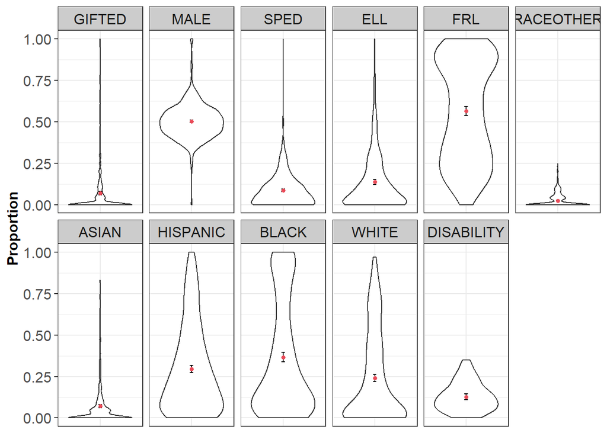

Note. The coral dots represent the weighted means. Error bars represent 95% CI.

Descriptive information on teachers teaching the class sections

| Characteristic | Count | Non-missing observations | Proportion of non-missing observations | Proportion of sample size |
| --- | --- | --- | --- | --- |
| DAD_MALE | 101 | 590 | 0.171 | 0.166 |
| DAD_WHITE | 347 | 588 | 0.590 | 0.572 |
| DAD_BLACK | 196 | 588 | 0.333 | 0.323 |
| DAD_HISPANIC | 33 | 588 | 0.056 | 0.054 |
| DAD_RACEOTHER | 12 | 588 | 0.020 | 0.020 |
| DAD_MASTERSPLUS | 184 | 458 | 0.402 | 0.303 |
| DAD_YRSEXP_NEW | 36 | 223 | 0.161 | 0.059 |
| DAD_YRSEXP_EARLY | 49 | 223 | 0.220 | 0.081 |
| DAD_YRSEXP_EST | 48 | 223 | 0.215 | 0.079 |
| DAD_YRSEXP_EXP | 54 | 223 | 0.242 | 0.089 |
| DAD_YRSEXP_HIGH | 36 | 223 | 0.161 | 0.059 |

Note. This table indicates the counts of teachers in the analytical sample that indicated a certain demographic characteristic. The information may be missing for some teachers in the total sample of 607 teachers.  
Experience was grouped as NEW = [0, 2] years, EARLY = (2, 5] years, EST = (5, 10] years, EXP = (10, 20] years, HIGH = (20, Inf) years.  
This table was saved as desc_Y2_both_teachers_cat.csv.

Descriptive information on teachers teaching the class sections (continued)

| Characteristic | Mean | SD | N |
| --- | --- | --- | --- |
| DAD_YRSEXP | 10.892 | 9.419 | 223 |
| FFT_CEV_adj | 2.660 | 0.189 | 607 |
| FFT_CERR_adj | 2.667 | 0.240 | 607 |
| FFT_ECL_adj | 2.535 | 0.223 | 607 |
| FFT_MCP_adj | 2.680 | 0.191 | 607 |
| FFT_MSB_adj | 2.758 | 0.221 | 607 |
| MQI_EI_adj | 1.227 | 0.072 | 607 |
| MQI_RICH_adj | 1.248 | 0.075 | 607 |
| MQI_WWSM_adj | 1.265 | 0.061 | 607 |
| MQI_SPMMR_adj | 1.189 | 0.086 | 607 |
| VA_SAM_adj | -0.001 | 0.178 | 607 |
| VA_BAM_adj | 0.003 | 0.167 | 607 |
| VA_NOAGGR_SAM_adj | -0.003 | 0.193 | 607 |
| VA_NOAGGR_BAM_adj | 0.001 | 0.180 | 607 |

Note. This table indicates mean and SD of teachers in the analytical sample that indicated a certain demographic characteristic. The information may be missing for some teachers in the total sample of 607 teachers.  
CEV, VA_SAM & VA_BAM represent teacher-level aggregates. FFT scores were adjusted at teacher level. VAMs were adjusted at section level and then aggregated at the teacher level using weighted means, accounting for the pupils included in the section-level VAMs.  
This table was saved as desc_Y2_both_teachers_num.csv.

Correlation of teaching experience with necessary condition and outcomes

| x | y | cor | ci_l | ci_u | df | t | p | N |
| --- | --- | --- | --- | --- | --- | --- | --- | --- |
| DAD_YRSEXP | FFT_CEV_adj_std | 0.080 | -0.052 | 0.209 | 221 | 1.186 | 0.237 | 223 |
| DAD_YRSEXP | FFT_CERR_adj_std | 0.054 | -0.078 | 0.184 | 221 | 0.799 | 0.425 | 223 |
| DAD_YRSEXP | FFT_ECL_adj_std | 0.076 | -0.056 | 0.205 | 221 | 1.127 | 0.261 | 223 |
| DAD_YRSEXP | FFT_MCP_adj_std | 0.083 | -0.049 | 0.212 | 221 | 1.241 | 0.216 | 223 |
| DAD_YRSEXP | FFT_MSB_adj_std | 0.069 | -0.063 | 0.199 | 221 | 1.029 | 0.305 | 223 |
| DAD_YRSEXP | MQI_EI_adj_std | -0.106 | -0.234 | 0.026 | 221 | -1.587 | 0.114 | 223 |
| DAD_YRSEXP | MQI_RICH_adj_std | -0.048 | -0.178 | 0.084 | 221 | -0.716 | 0.475 | 223 |
| DAD_YRSEXP | MQI_WWSM_adj_std | 0.000 | -0.131 | 0.131 | 221 | 0.000 | 1.000 | 223 |
| DAD_YRSEXP | MQI_SPMMR_adj_std | -0.014 | -0.145 | 0.117 | 221 | -0.213 | 0.831 | 223 |
| DAD_YRSEXP | VA_SAM_adj_std | 0.054 | -0.078 | 0.184 | 221 | 0.808 | 0.420 | 223 |
| DAD_YRSEXP | VA_BAM_adj_std | 0.120 | -0.012 | 0.247 | 221 | 1.790 | 0.075 | 223 |

Note. Data on DAD_YRSEXP is available for 223 teachers.  
This table was saved as cor_Y2_both_teaching_exp.csv.

#### **Figure**

#### *Relationship between teaching experience, necessary condition and outcomes*

Underlying count data for figure - Years of teaching experience

| DAD_YRSEXP_GRP | Domain | Mean | SD | N |
| --- | --- | --- | --- | --- |
| [0, 2] | CEV | -0.29 | 1.11 | 36 |
| [0, 2] | SAM | -0.11 | 0.89 | 36 |
| [0, 2] | BAM | -0.24 | 0.79 | 36 |
| (2, 5] | CEV | -0.06 | 1.17 | 49 |
| (2, 5] | SAM | 0.01 | 0.84 | 49 |
| (2, 5] | BAM | -0.08 | 0.73 | 49 |
| (5, 10] | CEV | 0.19 | 0.96 | 48 |
| (5, 10] | SAM | 0.07 | 0.77 | 48 |
| (5, 10] | BAM | 0.13 | 0.99 | 48 |
| (10, 20] | CEV | -0.03 | 0.92 | 54 |
| (10, 20] | SAM | -0.18 | 0.74 | 54 |
| (10, 20] | BAM | -0.21 | 1.03 | 54 |
| (20, Inf) | CEV | 0.04 | 0.73 | 36 |
| (20, Inf) | SAM | 0.10 | 0.96 | 36 |
| (20, Inf) | BAM | 0.25 | 0.77 | 36 |

#### **Figure**

#### *Relationship between teaching experience, necessary condition and outcomes*

[figure not shown]

Within vs between school variation - teacher level

| Domain | avg_within_sd | within_var | between_sd | between_var | total_var | within_pct | between_pct |
| --- | --- | --- | --- | --- | --- | --- | --- |
| FFT_CEV_adj | 0.139 | 0.027 | 0.155 | 0.024 | 0.051 | 0.532 | 0.468 |
| VA_BAM_adj | 0.133 | 0.023 | 0.114 | 0.013 | 0.036 | 0.640 | 0.360 |
| VA_SAM_adj | 0.135 | 0.024 | 0.134 | 0.018 | 0.042 | 0.577 | 0.423 |

Note. Data is available for 607 Teachers avg_within_sd is the average within-school SD. between_sd is the SD of school means. Classrooms were aggregated at teacher-level before aggregating at school level.

## Framework for Teaching (FFT)

Segment-level data is available for 2559 lesson segments.

Underlying count data for Observation score distributions figure

| item | domain | value | count | prop |
| --- | --- | --- | --- | --- |
| CERR | Classroom environment (FFT_CEV) | 1 | 120 | 0.0468933 |
| CERR | Classroom environment (FFT_CEV) | 2 | 710 | 0.2774521 |
| CERR | Classroom environment (FFT_CEV) | 3 | 1635 | 0.6389215 |
| CERR | Classroom environment (FFT_CEV) | 4 | 94 | 0.0367331 |
| ECL | Classroom environment (FFT_CEV) | 1 | 97 | 0.0379054 |
| ECL | Classroom environment (FFT_CEV) | 2 | 1070 | 0.4181321 |
| ECL | Classroom environment (FFT_CEV) | 3 | 1319 | 0.5154357 |
| ECL | Classroom environment (FFT_CEV) | 4 | 73 | 0.0285268 |
| MCP | Classroom environment (FFT_CEV) | 1 | 92 | 0.0359515 |
| MCP | Classroom environment (FFT_CEV) | 2 | 702 | 0.2743259 |
| MCP | Classroom environment (FFT_CEV) | 3 | 1690 | 0.6604142 |
| MCP | Classroom environment (FFT_CEV) | 4 | 75 | 0.0293083 |
| MSB | Classroom environment (FFT_CEV) | 1 | 60 | 0.0234467 |
| MSB | Classroom environment (FFT_CEV) | 2 | 598 | 0.2336850 |
| MSB | Classroom environment (FFT_CEV) | 3 | 1801 | 0.7037905 |
| MSB | Classroom environment (FFT_CEV) | 4 | 100 | 0.0390778 |

Note. The data shows the count of lesson video segments that have received a certain rating value for each component of the observation instrument.

#### **Figure**

#### *Distribution of observation scores*

[figure not shown]

#### **Figure**

#### *Unadjusted observation scores aggregated at teacher level*

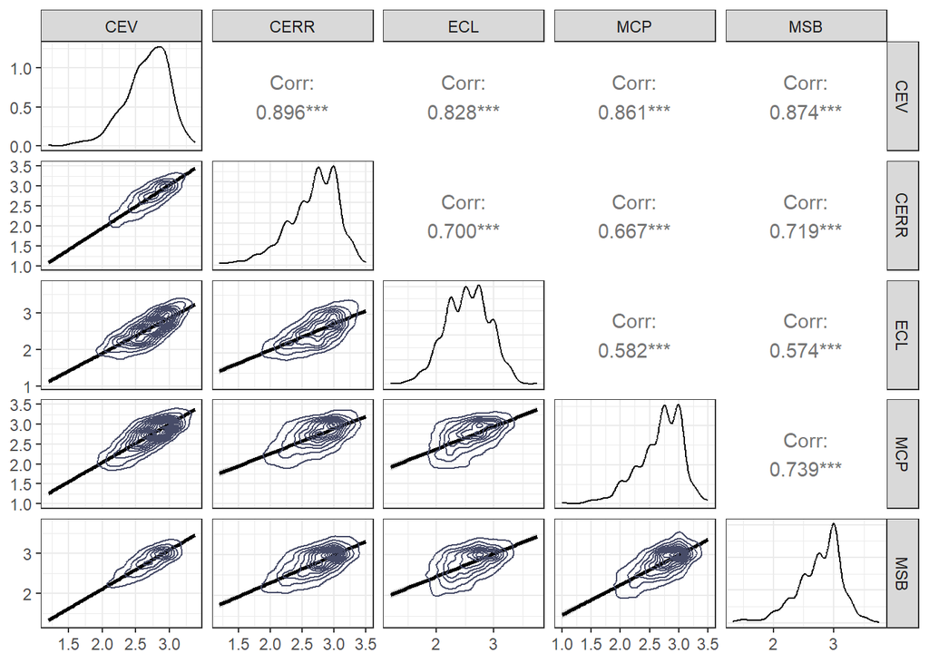

#### **Figure**

#### *Unadjusted observation scores aggregated at teacher level*

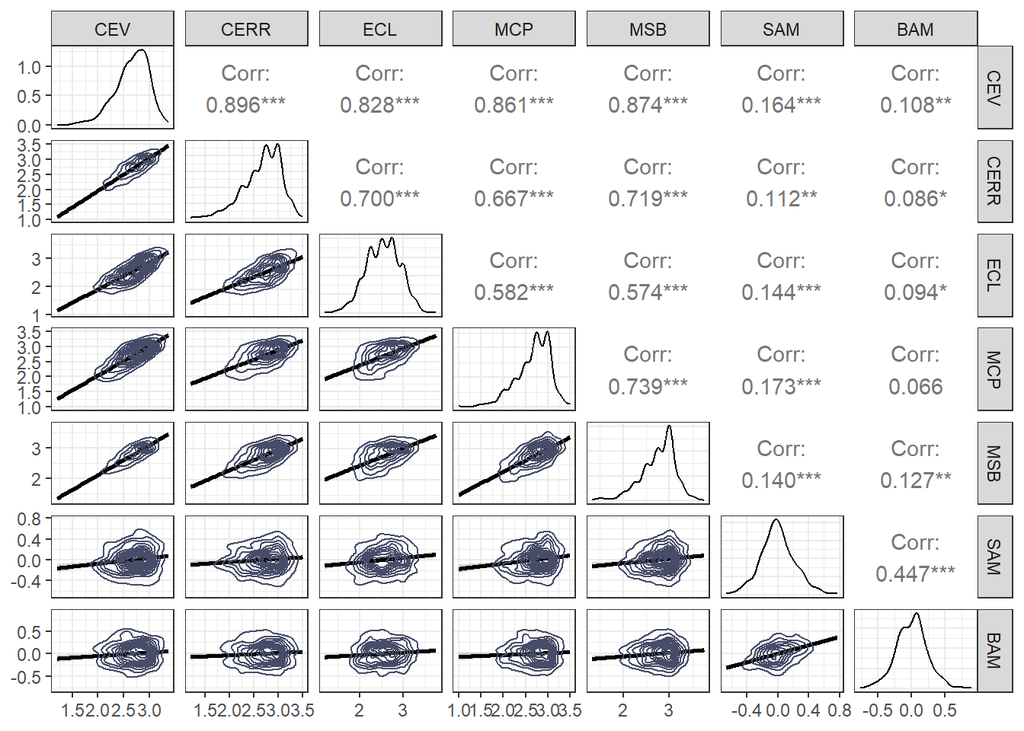

#### **Figure**

#### *Raw and adjusted observation scores*

[figure not shown]

Raw and adjusted observation scores

| Domain | Mean | SD | Mean_adj | SD_adj |
| --- | --- | --- | --- | --- |
| FFT_CEV | 2.660 | 0.329 | 2.660 | 0.189 |
| FFT_CERR | 2.667 | 0.397 | 2.667 | 0.240 |
| FFT_ECL | 2.534 | 0.381 | 2.535 | 0.223 |
| FFT_MCP | 2.680 | 0.371 | 2.680 | 0.191 |
| FFT_MSB | 2.758 | 0.370 | 2.758 | 0.221 |

Note. Data from 607 teachers is included.  
FFT_CEV refers to the domain scores for classroom environment, computed as the mean of their indicators.  
This table was saved as desc_Y2_both_FFT_adj.csv.

#### **Figure**

#### *Adjusted observation scores aggregated at teacher level*

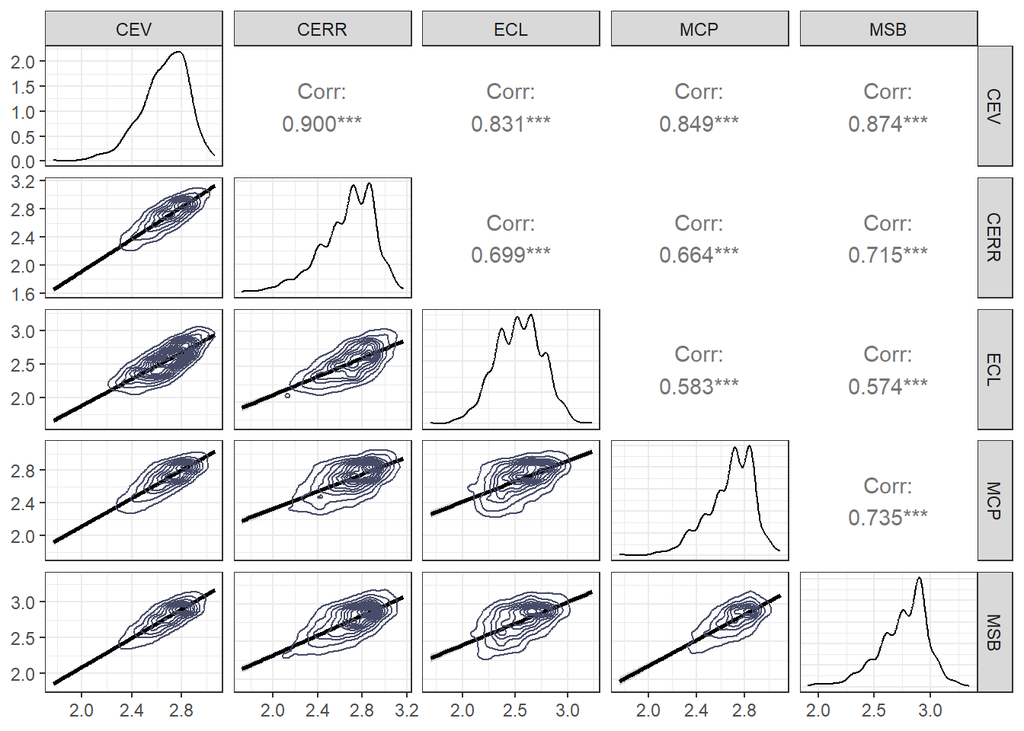

#### **Figure**

#### *Adjusted observation scores aggregated at teacher level*

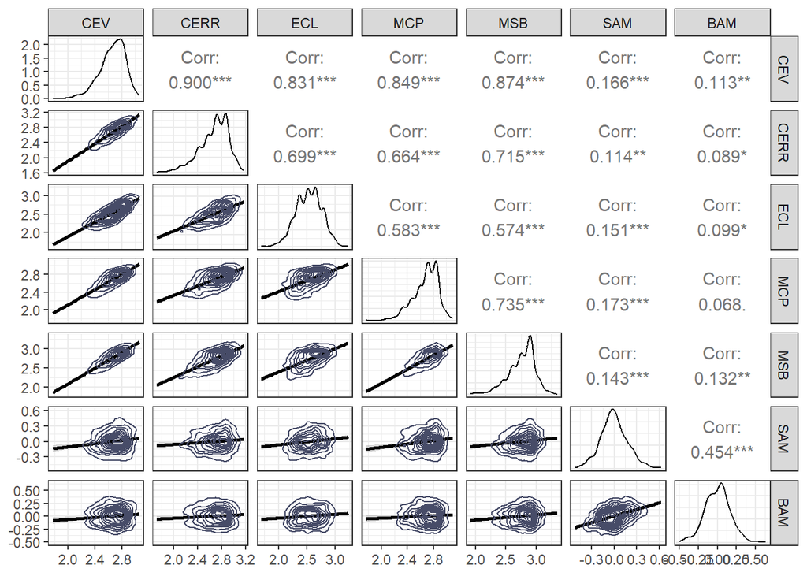

## Mathematical Quality of Instruction (MQI)

Segment-level data is available for 10056 lesson segments.

Underlying count data for Observation score distributions figure

| item | domain | value | count | prop |
| --- | --- | --- | --- | --- |
| EI | Teacher-content relationship | 1 | 8061 | 0.8016110 |
| EI | Teacher-content relationship | 2 | 1717 | 0.1707438 |
| EI | Teacher-content relationship | 3 | 278 | 0.0276452 |
| RICH | Teacher-content relationship | 1 | 7670 | 0.7627287 |
| RICH | Teacher-content relationship | 2 | 2259 | 0.2246420 |
| RICH | Teacher-content relationship | 3 | 127 | 0.0126293 |
| WWSM | Teacher-pupil relationship | 1 | 7502 | 0.7460223 |
| WWSM | Teacher-pupil relationship | 2 | 2427 | 0.2413484 |
| WWSM | Teacher-pupil relationship | 3 | 127 | 0.0126293 |
| SPMMR | Pupil-content relationship | 1 | 8237 | 0.8191130 |
| SPMMR | Pupil-content relationship | 2 | 1742 | 0.1732299 |
| SPMMR | Pupil-content relationship | 3 | 77 | 0.0076571 |

Note. The data shows the count of lesson video segments that have received a certain rating value for each component of the observation instrument.

#### **Figure**

#### *Distribution of observation scores*

[figure not shown]

#### **Figure**

#### *Unadjusted observation scores aggregated at teacher level*

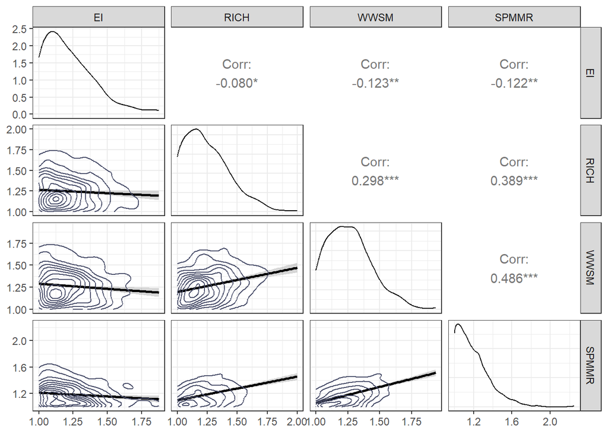

#### **Figure**

#### *Unadjusted observation scores aggregated at teacher level*

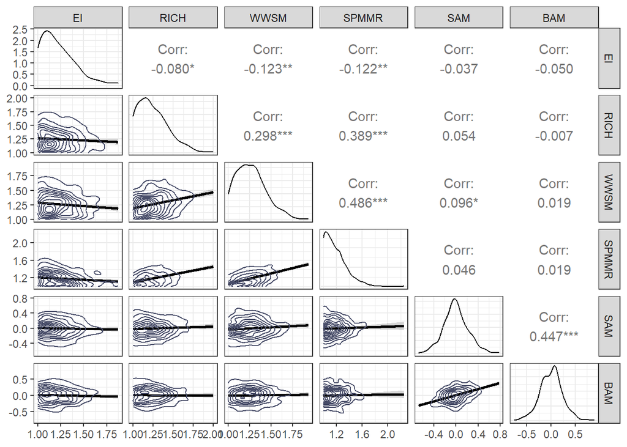

#### **Figure**

#### *Raw and adjusted observation scores*

[figure not shown]

Raw and adjusted observation scores

| Domain | Mean | SD | Mean_adj | SD_adj |
| --- | --- | --- | --- | --- |
| MQI_EI | 1.227 | 0.188 | 1.227 | 0.072 |
| MQI_RICH | 1.248 | 0.190 | 1.248 | 0.075 |
| MQI_WWSM | 1.265 | 0.175 | 1.265 | 0.061 |
| MQI_SPMMR | 1.189 | 0.174 | 1.189 | 0.086 |

Note. Data from 607 teachers is included.  
FFT_CEV refers to the domain scores for classroom environment, computed as the mean of their indicators.  
This table was saved as desc_Y2_both_MQI_adj.csv.

#### **Figure**

#### *Adjusted observation scores aggregated at teacher level*

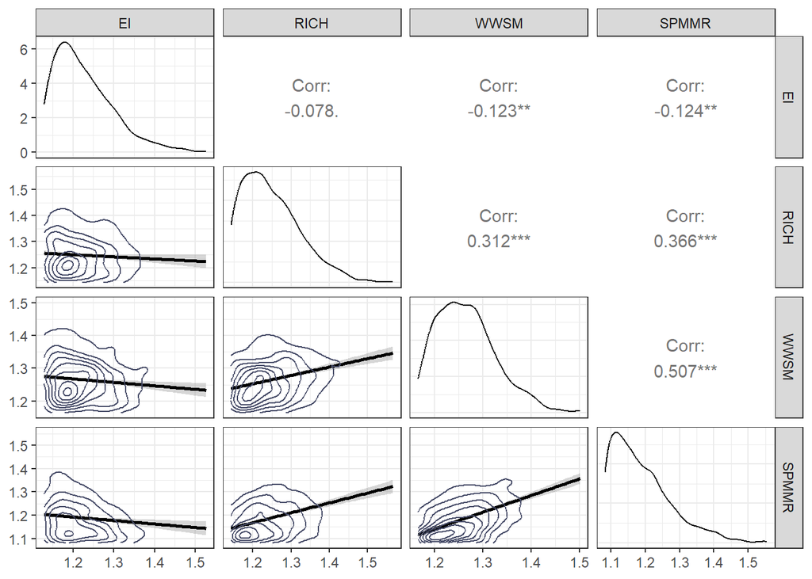

#### **Figure**

#### *Adjusted observation scores aggregated at teacher level*

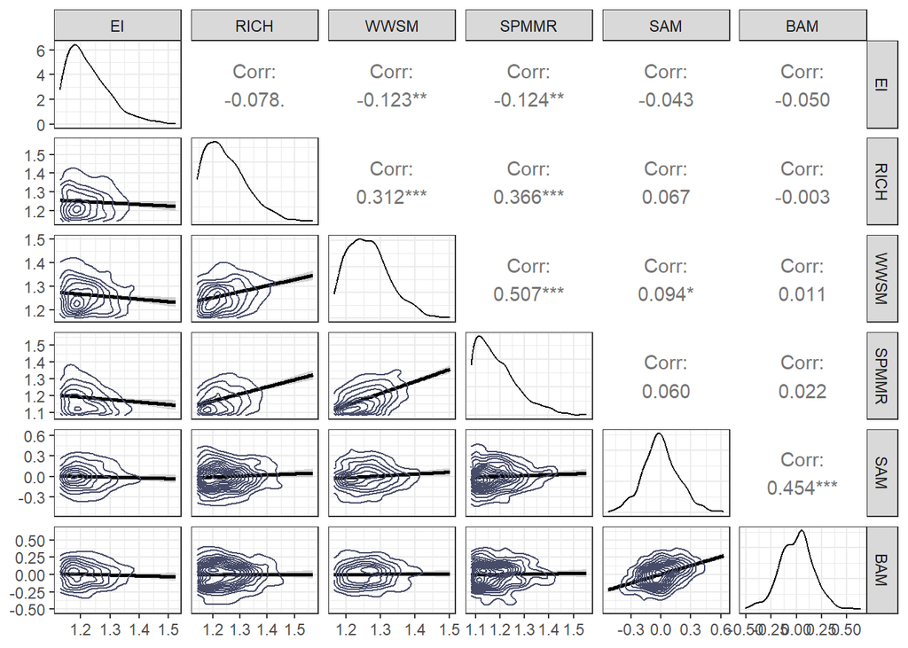

## Overall effect of observation score adjustment

Observation score adjustment

|  | Aggregation to teacher level N_SCORE | Aggregation to teacher level N_RATER | Aggregation to teacher level N_SEGMENT | Aggregation to teacher level N_LESSON | Aggregation to teacher level N_SECTION | Observed RELIABILITY | Observed SAMPLE | Hypothetical MIN_SCORE_ADJ | Hypothetical MAX_SCORE_ADJ |
| --- | --- | --- | --- | --- | --- | --- | --- | --- | --- |
| FFT_CERR | 4.22 (0.53) | 4.21 (0.51) | 4.02 (0.29) | 4.02 (0.29) | 1.00 (0.00) | 0.61 (0.02) | 2.67 (0.40) | 1.65 | 3.48 |
| FFT_ECL | 4.22 (0.53) | 4.21 (0.51) | 4.02 (0.29) | 4.02 (0.29) | 1.00 (0.00) | 0.58 (0.03) | 2.53 (0.38) | 1.64 | 3.39 |
| FFT_MCP | 4.22 (0.53) | 4.21 (0.51) | 4.02 (0.29) | 4.02 (0.29) | 1.00 (0.00) | 0.52 (0.02) | 2.68 (0.37) | 1.81 | 3.36 |
| FFT_MSB | 4.22 (0.53) | 4.21 (0.51) | 4.02 (0.29) | 4.02 (0.29) | 1.00 (0.00) | 0.60 (0.02) | 2.76 (0.37) | 1.70 | 3.50 |
| MQI_EI | 16.57 (2.32) | 4.13 (0.57) | 15.83 (1.48) | 3.96 (0.37) | 1.00 (0.00) | 0.38 (0.03) | 1.23 (0.19) | 1.14 | 1.91 |
| MQI_RICH | 16.57 (2.32) | 4.13 (0.57) | 15.83 (1.48) | 3.96 (0.37) | 1.00 (0.00) | 0.40 (0.03) | 1.25 (0.19) | 1.15 | 1.95 |
| MQI_WWSM | 16.57 (2.32) | 4.13 (0.57) | 15.83 (1.48) | 3.96 (0.37) | 1.00 (0.00) | 0.35 (0.03) | 1.26 (0.17) | 1.17 | 1.88 |
| MQI_SPMMR | 16.57 (2.32) | 4.13 (0.57) | 15.83 (1.48) | 3.96 (0.37) | 1.00 (0.00) | 0.51 (0.03) | 1.19 (0.17) | 1.09 | 2.11 |

Note. Data from 607 teachers is included.  
Table shows the counts as M (SD) of scores, raters, segments, lessons and sections that were aggregated to derive a single score at the teacher level.  
These counts informed the calculation of the reliability coefficients. Together with the observed sample mean (SD), the reliability coefficients were used to calculate the smallest and largest observation score that was hypothetically possible following adjustment.  
This table was saved as desc_Y2_both_shrinkage.csv.

## Value-added measures

Value-added scores

| VAM | Mean | SD | N Teachers |
| --- | --- | --- | --- |
| VA_SAM | 0.00 | 0.22 | 607 |
| VA_BAM | 0.00 | 0.23 | 607 |
| VA_NOAGGR_SAM | 0.00 | 0.24 | 607 |
| VA_NOAGGR_BAM | 0.00 | 0.24 | 607 |
| VA_SAM_SE | 0.11 | 0.02 | 607 |
| VA_SAM_N | 22.16 | 6.13 | 607 |
| VA_BAM_SE | 0.14 | 0.02 | 607 |
| VA_BAM_N | 19.02 | 5.29 | 607 |
| VA_NOAGGR_SAM_SE | 0.11 | 0.02 | 607 |
| VA_NOAGGR_SAM_N | 22.16 | 6.13 | 607 |
| VA_NOAGGR_BAM_SE | 0.14 | 0.02 | 607 |
| VA_NOAGGR_BAM_N | 19.02 | 5.29 | 607 |
| VA_SAM_rel | 0.81 | 0.04 | 607 |
| VA_SAM_adj | 0.00 | 0.18 | 607 |
| VA_BAM_rel | 0.73 | 0.06 | 607 |
| VA_BAM_adj | 0.00 | 0.17 | 607 |
| VA_NOAGGR_SAM_rel | 0.83 | 0.04 | 607 |
| VA_NOAGGR_SAM_adj | 0.00 | 0.19 | 607 |
| VA_NOAGGR_BAM_rel | 0.75 | 0.06 | 607 |
| VA_NOAGGR_BAM_adj | 0.00 | 0.18 | 607 |
| VA_SAM_std | 0.00 | 1.00 | 607 |
| VA_SAM_adj_std | 0.00 | 1.00 | 607 |
| VA_BAM_std | 0.00 | 1.00 | 607 |
| VA_BAM_adj_std | 0.00 | 1.00 | 607 |
| VA_NOAGGR_SAM_std | 0.00 | 1.00 | 607 |
| VA_NOAGGR_SAM_adj_std | 0.00 | 1.00 | 607 |
| VA_NOAGGR_BAM_std | 0.00 | 1.00 | 607 |
| VA_NOAGGR_BAM_adj_std | 0.00 | 1.00 | 607 |

Note.

#### **Figure**

#### *Raw and adjusted VA scores*

[figure not shown]

TVA score adjustment

|  | RELIABILITY | SAMPLE |
| --- | --- | --- |
| VA_SAM | 0.81 (0.04) | -0.00 (0.22) |
| VA_BAM | 0.73 (0.06) | 0.00 (0.23) |
| VA_NOAGGR_SAM | 0.83 (0.04) | -0.00 (0.24) |
| VA_NOAGGR_BAM | 0.75 (0.06) | -0.00 (0.24) |

Note. Data from 607 classrooms is included.  
Table shows reliability and observed scores as M (SD).

## Intercorrelation matrix

[figure not shown]

Correlation of variables at teacher level

|  | CEV | CERR | ECL | MCP | MSB | EI | RICH | WWSM | SPMMR | SAM | BAM | SAM(*) | BAM(*) | YRSEXP |
| --- | --- | --- | --- | --- | --- | --- | --- | --- | --- | --- | --- | --- | --- | --- |
| CEV | r = 1.00 (p <.001) | r = .90 (p <.001) | r = .83 (p <.001) | r = .86 (p <.001) | r = .87 (p <.001) | r = -.01 (p = 1) | r = .22 (p <.001) | r = .09 (p = 1) | r = .20 (p <.001) | r = .16 (p = .006) | r = .11 (p = .483) | r = .21 (p <.001) | r = .15 (p = .022) | r = .08 (p = 1) |
| CERR | r = .90 (p <.001) | r = 1.00 (p <.001) | r = .70 (p <.001) | r = .67 (p <.001) | r = .72 (p <.001) | r = -.02 (p = 1) | r = .21 (p <.001) | r = .06 (p = 1) | r = .16 (p = .006) | r = .11 (p = .400) | r = .09 (p = 1) | r = .15 (p = .020) | r = .13 (p = .081) | r = .05 (p = 1) |
| ECL | r = .83 (p <.001) | r = .70 (p <.001) | r = 1.00 (p <.001) | r = .58 (p <.001) | r = .57 (p <.001) | r = -.06 (p = 1) | r = .20 (p <.001) | r = .11 (p = .478) | r = .23 (p <.001) | r = .14 (p = .036) | r = .09 (p = 1) | r = .18 (p = .002) | r = .12 (p = .196) | r = .08 (p = 1) |
| MCP | r = .85 (p <.001) | r = .66 (p <.001) | r = .58 (p <.001) | r = 1.00 (p <.001) | r = .74 (p <.001) | r = .03 (p = 1) | r = .19 (p <.001) | r = .10 (p = .706) | r = .15 (p = .019) | r = .17 (p = .003) | r = .07 (p = 1) | r = .22 (p <.001) | r = .10 (p = .881) | r = .09 (p = 1) |
| MSB | r = .87 (p <.001) | r = .72 (p <.001) | r = .57 (p <.001) | r = .74 (p <.001) | r = 1.00 (p <.001) | r = .02 (p = 1) | r = .16 (p = .012) | r = .05 (p = 1) | r = .14 (p = .050) | r = .14 (p = .050) | r = .13 (p = .139) | r = .18 (p = .002) | r = .17 (p = .005) | r = .07 (p = 1) |
| EI | r = -.01 (p = 1) | r = -.02 (p = .841) | r = -.06 (p = .185) | r = .03 (p = .619) | r = .02 (p = .741) | r = 1.00 (p <.001) | r = -.08 (p = 1) | r = -.12 (p = .187) | r = -.12 (p = .196) | r = -.04 (p = 1) | r = -.05 (p = 1) | r = -.06 (p = 1) | r = -.07 (p = 1) | r = -.11 (p = 1) |
| RICH | r = .24 (p <.001) | r = .23 (p <.001) | r = .22 (p <.001) | r = .20 (p <.001) | r = .17 (p <.001) | r = -.08 (p = .096) | r = 1.00 (p <.001) | r = .30 (p <.001) | r = .39 (p <.001) | r = .05 (p = 1) | r = -.01 (p = 1) | r = .07 (p = 1) | r = .01 (p = 1) | r = -.05 (p = 1) |
| WWSM | r = .09 (p = .048) | r = .06 (p = .234) | r = .11 (p = .010) | r = .10 (p = .024) | r = .04 (p = .420) | r = -.12 (p = .005) | r = .31 (p <.001) | r = 1.00 (p <.001) | r = .49 (p <.001) | r = .10 (p = .906) | r = .02 (p = 1) | r = .11 (p = .564) | r = .04 (p = 1) | r = .00 (p = 1) |
| SPMMR | r = .23 (p <.001) | r = .20 (p <.001) | r = .25 (p <.001) | r = .18 (p <.001) | r = .17 (p <.001) | r = -.12 (p = .005) | r = .37 (p <.001) | r = .51 (p <.001) | r = 1.00 (p <.001) | r = .05 (p = 1) | r = .02 (p = 1) | r = .08 (p = 1) | r = .06 (p = 1) | r = -.01 (p = 1) |
| SAM | r = .17 (p <.001) | r = .11 (p = .010) | r = .15 (p <.001) | r = .17 (p <.001) | r = .14 (p <.001) | r = -.04 (p = .420) | r = .07 (p = .164) | r = .09 (p = .039) | r = .06 (p = .213) | r = 1.00 (p <.001) | r = .45 (p <.001) | r = .94 (p <.001) | r = .43 (p <.001) | r = .05 (p = 1) |
| BAM | r = .11 (p = .011) | r = .09 (p = .049) | r = .10 (p = .028) | r = .07 (p = .160) | r = .13 (p = .003) | r = -.05 (p = .333) | r = -.00 (p = 1) | r = .01 (p = 1) | r = .02 (p = .780) | r = .45 (p <.001) | r = 1.00 (p <.001) | r = .43 (p <.001) | r = .96 (p <.001) | r = .12 (p = 1) |
| SAM(*) | r = .21 (p <.001) | r = .15 (p <.001) | r = .18 (p <.001) | r = .21 (p <.001) | r = .18 (p <.001) | r = -.07 (p = .163) | r = .08 (p = .076) | r = .10 (p = .020) | r = .09 (p = .047) | r = .94 (p <.001) | r = .43 (p <.001) | r = 1.00 (p <.001) | r = .47 (p <.001) | r = .07 (p = 1) |
| BAM(*) | r = .15 (p <.001) | r = .13 (p = .002) | r = .13 (p = .004) | r = .10 (p = .033) | r = .17 (p <.001) | r = -.07 (p = .169) | r = .01 (p = 1) | r = .03 (p = .619) | r = .06 (p = .221) | r = .44 (p <.001) | r = .96 (p <.001) | r = .48 (p <.001) | r = 1.00 (p <.001) | r = .13 (p = 1) |
| YRSEXP | r = .08 (p = .346) | r = .05 (p = .591) | r = .08 (p = .379) | r = .08 (p = .328) | r = .07 (p = .432) | r = -.11 (p = .180) | r = -.05 (p = .642) | r = -.00 (p = 1) | r = -.01 (p = 1) | r = .05 (p = .588) | r = .12 (p = .126) | r = .07 (p = .432) | r = .13 (p = .094) | r = 1.00 (p <.001) |

Note. Data is available for 607 teachers, of which 223had non-missing data for DAD_YRSEXP. The upper triangle uses raw data whereas the lower triangle uses adjusted data. All p values were adjusted using the FDR method.  
This table was saved as cor_Y2_both.csv.

## Main NCA analysis

OLS coefficients

| Observation score | Model 1 B | Model 1 SE_B | Model 1 β | Model 1 SE | Model 1 t | Model 1 p | Model 1 R2 | Model 1 R2_adj | Model 1 F | Model 1 numdf | Model 1 dendf | Model 1 p (F) | Model 2 B | Model 2 SE_B | Model 2 β | Model 2 SE | Model 2 t | Model 2 p | Model 2 R2 | Model 2 R2_adj | Model 2 F | Model 2 numdf | Model 2 dendf | Model 2 p (F) |
| --- | --- | --- | --- | --- | --- | --- | --- | --- | --- | --- | --- | --- | --- | --- | --- | --- | --- | --- | --- | --- | --- | --- | --- | --- |
| VA_SAM_adj_std |  |  |  |  |  |  |  |  |  |  |  |  |  |  |  |  |  |  |  |  |  |  |  |  |
| CEV | 0.88 | 0.21 | 0.17 | 0.04 | 4.141 | <.001 | 0.03% | 0.03% | 17.145 | 1 | 605 | <.001 |  |  |  |  |  |  |  |  |  |  |  |  |
| CERR | 0.47 | 0.17 | 0.11 | 0.04 | 2.825 | .005 | 0.01% | 0.01% | 7.983 | 1 | 605 | .005 | -0.31 | 0.28 | -0.07 | 0.07 | -1.099 | .272 | 0.04% | 0.03% | 5.567 | 4 | 602 | <.001 |
| ECL | 0.68 | 0.18 | 0.15 | 0.04 | 3.766 | <.001 | 0.02% | 0.02% | 14.184 | 1 | 605 | <.001 | 0.46 | 0.26 | 0.10 | 0.06 | 1.801 | .072 | 0.04% | 0.03% | 5.567 | 4 | 602 | <.001 |
| MCP | 0.90 | 0.21 | 0.17 | 0.04 | 4.310 | <.001 | 0.03% | 0.03% | 18.573 | 1 | 605 | <.001 | 0.70 | 0.33 | 0.13 | 0.06 | 2.130 | .034 | 0.04% | 0.03% | 5.567 | 4 | 602 | <.001 |
| MSB | 0.65 | 0.18 | 0.14 | 0.04 | 3.543 | <.001 | 0.02% | 0.02% | 12.556 | 1 | 605 | <.001 | 0.17 | 0.30 | 0.04 | 0.07 | 0.575 | .565 | 0.04% | 0.03% | 5.567 | 4 | 602 | <.001 |
| VA_BAM_adj_std |  |  |  |  |  |  |  |  |  |  |  |  |  |  |  |  |  |  |  |  |  |  |  |  |
| CEV | 0.60 | 0.21 | 0.11 | 0.04 | 2.797 | .005 | 0.01% | 0.01% | 7.820 | 1 | 605 | .005 |  |  |  |  |  |  |  |  |  |  |  |  |
| CERR | 0.37 | 0.17 | 0.09 | 0.04 | 2.206 | .028 | 0.01% | 0.01% | 4.865 | 1 | 605 | .028 | -0.11 | 0.28 | -0.03 | 0.07 | -0.383 | .702 | 0.02% | 0.01% | 3.264 | 4 | 602 | .012 |
| ECL | 0.44 | 0.18 | 0.10 | 0.04 | 2.441 | .015 | 0.01% | 0.01% | 5.960 | 1 | 605 | .015 | 0.29 | 0.26 | 0.06 | 0.06 | 1.115 | .265 | 0.02% | 0.01% | 3.264 | 4 | 602 | .012 |
| MCP | 0.35 | 0.21 | 0.07 | 0.04 | 1.669 | .096 | 0.00% | 0.00% | 2.787 | 1 | 605 | .096 | -0.41 | 0.33 | -0.08 | 0.06 | -1.236 | .217 | 0.02% | 0.01% | 3.264 | 4 | 602 | .012 |
| MSB | 0.60 | 0.18 | 0.13 | 0.04 | 3.267 | .001 | 0.02% | 0.02% | 10.671 | 1 | 605 | .001 | 0.77 | 0.30 | 0.17 | 0.07 | 2.561 | .011 | 0.02% | 0.01% | 3.264 | 4 | 602 | .012 |

Note. Data from 607 teachers is included. In model 1, each predictor was entered seperately. In model 2, all predictors were entered together.  
This table was saved as coef_Y2_both_main_ols.csv

NCA parameters

| Metric | FFT_CEV_adj | FFT_CERR_adj | FFT_ECL_adj | FFT_MCP_adj | FFT_MSB_adj |
| --- | --- | --- | --- | --- | --- |
| VA_SAM_adj_std |  |  |  |  |  |
| Number of observations | 607 | 607 | 607 | 607 | 607 |
| Scope | 8.38 [44.32] | 9.36 [38.94] | 9.96 [44.62] | 8.66 [45.37] | 9.34 [42.35] |
| Ceiling zone | 1.95 [10.30] | 1.77 [7.36] | 1.67 [7.50] | 2.07 [10.85] | 1.50 [6.78] |
| Effect size | .23 | .19 | .17 | .24 | .16 |
| p value (unadj.) | .131 | .127 | .124 | .081 | .194 |
| p value (adj.) | .232 | .170 | .170 | .170 | .194 |
| p accuracy | .007 | .007 | .006 | .005 | .008 |
| Slope | 4.04 [0.76] | 3.16 [0.76] | 3.35 [0.75] | 3.95 [0.75] | 3.11 [0.69] |
| Intercept | -7.60 [3.16] | -5.26 [3.18] | -5.50 [2.99] | -7.47 [3.13] | -5.44 [3.13] |
| Fit | 89.97% | 91.73% | 92.57% | 85.11% | 91.55% |
| Ceiling accuracy | 99.01% (601) | 99.18% (602) | 99.01% (601) | 99.18% (602) | 98.68% (599) |
| Noise | 1.00% (6) | 0.70% (4) | 0.80% (5) | 0.80% (5) | 1.30% (8) |
| Exceptions | 0.00% (0) | 0.20% (1) | 0.20% (1) | 0.00% (0) | 0.00% (0) |
| Support | 5.40% (33) | 4.60% (28) | 5.80% (35) | 6.90% (42) | 3.50% (21) |
| Spread | .39 | .44 | .35 | .31 | .42 |
| Sharpness | .84 | .87 | .87 | .89 | .70 |
| Relative inefficiency | 53.52% | 62.21% | 66.36% | 52.18% | 67.97% |
| Condition inefficiency | 24.14% | 26.80% | 34.93% | 23.44% | 31.95% |
| Outcome inefficiency | 38.73% | 48.37% | 48.31% | 37.53% | 52.94% |
| VA_BAM_adj_std |  |  |  |  |  |
| Number of observations | 607 | 607 | 607 | 607 | 607 |
| Scope | 8.89 [46.98] | 9.92 [41.28] | 10.56 [47.31] | 9.18 [48.10] | 9.90 [44.90] |
| Ceiling zone | 2.23 [11.81] | 1.98 [8.24] | 1.94 [8.71] | 2.17 [11.34] | 1.18 [5.33] |
| Effect size | .25 | .20 | .18 | .24 | .12 |
| p value (unadj.) | .116 | .170 | .103 | .191 | .745 |
| p value (adj.) | .232 | .255 | .255 | .255 | .745 |
| p accuracy | .006 | .007 | .006 | .008 | .009 |
| Slope | 4.83 [0.91] | 4.40 [1.06] | 4.15 [0.93] | 5.38 [1.03] | 5.80 [1.28] |
| Intercept | -9.38 [3.46] | -7.95 [3.79] | -7.26 [3.27] | -10.49 [3.94] | -10.94 [5.06] |
| Fit | 89.53% | 84.49% | 82.33% | 88.42% | 72.69% |
| Ceiling accuracy | 99.18% (602) | 99.51% (604) | 99.34% (603) | 99.51% (604) | 99.51% (604) |
| Noise | 0.80% (5) | 0.50% (3) | 0.70% (4) | 0.30% (2) | 0.50% (3) |
| Exceptions | 0.00% (0) | 0.00% (0) | 0.00% (0) | 0.20% (1) | 0.00% (0) |
| Support | 8.40% (51) | 6.60% (40) | 8.60% (52) | 6.30% (38) | 1.00% (6) |
| Spread | .31 | .29 | .25 | .30 | .43 |
| Sharpness | .91 | .93 | .93 | .95 | .57 |
| Relative inefficiency | 49.72% | 60.08% | 63.16% | 52.83% | 76.25% |
| Condition inefficiency | 25.65% | 34.34% | 37.05% | 32.92% | 55.84% |
| Outcome inefficiency | 32.38% | 39.19% | 41.48% | 29.69% | 46.22% |

Note. Data from 607 teachers is included. NCA ceiling line = CR-FDH. Fit values of N/A indicate cases where the CR-FDH ceiling zone exceeds the CE-FDH ceiling zone, resulting in a negative closeness percentage that is not conceptually interpretable. This occurs when the straight-line CR-FDH approximation creates a larger empty space than the CE-FDH step-function boundary and does not invalidate effect sizes or ceiling accuracy.  
p values were estimated using 10000 permutations.  
This table was saved as coef_Y2_both_main_nca.csv

#### **Figure**

#### *NCA Plot: VAMs - CEV*

[figure not shown]

#### **Figure**

#### *NCA Plot: FFT indicators - SAM*

[figure not shown]

#### **Figure**

#### *NCA Plot: FFT indicators - BAM*

[figure not shown]

NCA bottlenecks

| Ouctome | FFT_CEV_adj Adj. | FFT_CEV_adj Adj. std. | FFT_CEV_adj % range | FFT_CEV_adj Percentile | FFT_CERR_adj Adj. | FFT_CERR_adj Adj. std. | FFT_CERR_adj % range | FFT_CERR_adj Percentile | FFT_ECL_adj Adj. | FFT_ECL_adj Adj. std. | FFT_ECL_adj % range | FFT_ECL_adj Percentile | FFT_MCP_adj Adj. | FFT_MCP_adj Adj. std. | FFT_MCP_adj % range | FFT_MCP_adj Percentile | FFT_MSB_adj Adj. | FFT_MSB_adj Adj. std. | FFT_MSB_adj % range | FFT_MSB_adj Percentile |
| --- | --- | --- | --- | --- | --- | --- | --- | --- | --- | --- | --- | --- | --- | --- | --- | --- | --- | --- | --- | --- |
| VA_SAM_adj_std |  |  |  |  |  |  |  |  |  |  |  |  |  |  |  |  |  |  |  |  |
| -2.5 | NN | NN | NN | NN | NN | NN | NN | NN | NN | NN | NN | NN | NN | NN | NN | NN | NN | NN | NN | NN |
| -2 | NN | NN | NN | NN | NN | NN | NN | NN | NN | NN | NN | NN | NN | NN | NN | NN | NN | NN | NN | NN |
| -1.5 | NN | NN | NN | NN | NN | NN | NN | NN | NN | NN | NN | NN | NN | NN | NN | NN | NN | NN | NN | NN |
| -1 | NN | NN | NN | NN | NN | NN | NN | NN | NN | NN | NN | NN | NN | NN | NN | NN | NN | NN | NN | NN |
| -0.5 | NN | NN | NN | NN | NN | NN | NN | NN | NN | NN | NN | NN | 1.763 | -4.805 | 0.3 | 0.2 | NN | NN | NN | NN |
| 0 | 1.879 | -4.130 | 8.3 | 0.2 | NN | NN | NN | NN | NN | NN | NN | NN | 1.889 | -4.142 | 9.7 | 0.2 | NN | NN | NN | NN |
| 0.5 | 2.002 | -3.476 | 17.9 | 0.3 | 1.821 | -3.520 | 6.8 | 0.5 | 1.790 | -3.335 | 6.1 | 0.2 | 2.016 | -3.480 | 19.2 | 0.2 | 1.911 | -3.841 | 0.3 | 0.2 |
| 1 | 2.126 | -2.823 | 27.4 | 1.0 | 1.979 | -2.862 | 17.8 | 1.5 | 1.940 | -2.666 | 15.8 | 0.2 | 2.142 | -2.818 | 28.6 | 1.0 | 2.072 | -3.111 | 11.5 | 1.2 |
| 1.5 | 2.250 | -2.169 | 37.0 | 3.5 | 2.137 | -2.205 | 28.7 | 4.0 | 2.089 | -1.997 | 25.6 | 4.0 | 2.269 | -2.155 | 38.1 | 2.6 | 2.233 | -2.382 | 22.7 | 2.1 |
| 2 | 2.373 | -1.515 | 46.6 | 8.2 | 2.295 | -1.547 | 39.6 | 9.1 | 2.238 | -1.328 | 35.3 | 12.9 | 2.395 | -1.493 | 47.5 | 9.4 | 2.394 | -1.653 | 33.8 | 6.4 |
| 2.5 | 2.497 | -0.861 | 56.1 | 18.0 | 2.453 | -0.890 | 50.6 | 20.8 | 2.388 | -0.658 | 45.0 | 33.6 | 2.522 | -0.830 | 57.0 | 19.9 | 2.554 | -0.923 | 45.0 | 14.7 |
| 3 | 2.621 | -0.208 | 65.7 | 38.2 | 2.611 | -0.232 | 61.5 | 37.2 | 2.537 | 0.011 | 54.7 | 55.2 | 2.648 | -0.168 | 66.5 | 35.7 | 2.715 | -0.194 | 56.1 | 32.3 |
| 3.5 | 2.744 | 0.446 | 75.2 | 61.9 | 2.769 | 0.425 | 72.5 | 64.3 | 2.686 | 0.680 | 64.4 | 79.6 | 2.774 | 0.494 | 75.9 | 64.6 | 2.876 | 0.536 | 67.3 | 55.7 |
| VA_BAM_adj_std |  |  |  |  |  |  |  |  |  |  |  |  |  |  |  |  |  |  |  |  |
| -3 | NN | NN | NN | NN | NN | NN | NN | NN | NN | NN | NN | NN | NN | NN | NN | NN | NN | NN | NN | NN |
| -2.5 | NN | NN | NN | NN | NN | NN | NN | NN | NN | NN | NN | NN | NN | NN | NN | NN | NN | NN | NN | NN |
| -2 | NN | NN | NN | NN | NN | NN | NN | NN | NN | NN | NN | NN | NN | NN | NN | NN | NN | NN | NN | NN |
| -1.5 | NN | NN | NN | NN | NN | NN | NN | NN | NN | NN | NN | NN | NN | NN | NN | NN | NN | NN | NN | NN |
| -1 | NN | NN | NN | NN | NN | NN | NN | NN | NN | NN | NN | NN | 1.763 | -4.805 | 0.3 | 0.2 | NN | NN | NN | NN |
| -0.5 | 1.840 | -4.334 | 5.3 | 0.2 | NN | NN | NN | NN | NN | NN | NN | NN | 1.856 | -4.318 | 7.2 | 0.2 | NN | NN | NN | NN |
| 0 | 1.944 | -3.786 | 13.4 | 0.2 | 1.806 | -3.584 | 5.8 | 0.2 | 1.746 | -3.532 | 3.3 | 0.2 | 1.948 | -3.832 | 14.1 | 0.2 | NN | NN | NN | NN |
| 0.5 | 2.047 | -3.239 | 21.4 | 0.5 | 1.919 | -3.112 | 13.6 | 0.5 | 1.867 | -2.993 | 11.1 | 0.2 | 2.041 | -3.346 | 21.1 | 0.2 | 1.972 | -3.564 | 4.6 | 0.2 |
| 1 | 2.151 | -2.691 | 29.4 | 1.8 | 2.033 | -2.639 | 21.5 | 1.5 | 1.987 | -2.454 | 18.9 | 1.2 | 2.134 | -2.859 | 28.0 | 1.0 | 2.058 | -3.173 | 10.6 | 1.2 |
| 1.5 | 2.254 | -2.144 | 37.4 | 3.5 | 2.146 | -2.167 | 29.3 | 4.1 | 2.107 | -1.914 | 26.8 | 4.0 | 2.227 | -2.373 | 35.0 | 2.5 | 2.144 | -2.783 | 16.5 | 1.2 |
| 2 | 2.358 | -1.596 | 45.4 | 6.9 | 2.260 | -1.695 | 37.2 | 5.3 | 2.228 | -1.375 | 34.6 | 12.7 | 2.320 | -1.886 | 41.9 | 3.8 | 2.230 | -2.392 | 22.5 | 2.1 |
| 2.5 | 2.461 | -1.049 | 53.4 | 14.7 | 2.373 | -1.222 | 45.1 | 10.2 | 2.348 | -0.836 | 42.4 | 15.8 | 2.413 | -1.400 | 48.9 | 9.4 | 2.317 | -2.001 | 28.5 | 5.4 |
| 3 | 2.565 | -0.501 | 61.4 | 27.0 | 2.487 | -0.750 | 52.9 | 21.6 | 2.468 | -0.296 | 50.2 | 35.4 | 2.506 | -0.914 | 55.8 | 19.1 | 2.403 | -1.610 | 34.5 | 6.4 |
| 3.5 | 2.669 | 0.046 | 69.4 | 44.8 | 2.600 | -0.277 | 60.8 | 37.2 | 2.589 | 0.243 | 58.1 | 55.4 | 2.599 | -0.427 | 62.8 | 35.3 | 2.489 | -1.220 | 40.4 | 14.0 |

Note. Data from 607 teachers is included. Bottlenecks are shown for each condition where the values are shown as adjusted values, adjusted standardised values, percentage range or percentiles. NCA ceiling line = CR-FDH. NN = not necessary.  
This table was saved as coef_Y2_both_main_bottlenecks.csv

## Regression

OLS coefficients - Condition inefficiency models

| Observation score | Model 1 β | Model 1 SE | Model 1 t | Model 1 p | Model 1 R2 | Model 1 R2_adj | Model 1 F | Model 1 numdf | Model 1 dendf | Model 1 p (F) | Model 1 N | Model 2 β | Model 2 SE | Model 2 t | Model 2 p | Model 2 R2 | Model 2 R2_adj | Model 2 F | Model 2 numdf | Model 2 dendf | Model 2 p (F) | Model 2 N | Model 3 β | Model 3 SE | Model 3 t | Model 3 p | Model 3 R2 | Model 3 R2_adj | Model 3 F | … |
| --- | --- | --- | --- | --- | --- | --- | --- | --- | --- | --- | --- | --- | --- | --- | --- | --- | --- | --- | --- | --- | --- | --- | --- | --- | --- | --- | --- | --- | --- | --- |
| VA_SAM_adj |  |  |  |  |  |  |  |  |  |  |  |  |  |  |  |  |  |  |  |  |  |  |  |  |  |  |  |  |  | … |
| EI | -0.04 | 0.04 | -0.918 | .359 | 0.00% | -0.00% | 0.843 | 1 | 605 | .359 | 607 | -0.04 | 0.04 | -1.052 | .293 | 0.00% | 0.00% | 1.106 | 1 | 605 | .293 | 607 | -0.03 | 0.04 | -0.728 | .467 | 0.01% | 0.00% | 1.708 | … |
| RICH | 0.05 | 0.04 | 1.342 | .180 | 0.00% | 0.00% | 1.800 | 1 | 605 | .180 | 607 | 0.07 | 0.04 | 1.645 | .101 | 0.00% | 0.00% | 2.705 | 1 | 605 | .101 | 607 | 0.04 | 0.04 | 0.893 | .372 | 0.01% | 0.00% | 1.708 | … |
| WWSM | 0.10 | 0.04 | 2.485 | .013 | 0.01% | 0.01% | 6.174 | 1 | 605 | .013 | 607 | 0.09 | 0.04 | 2.313 | .021 | 0.01% | 0.01% | 5.350 | 1 | 605 | .021 | 607 | 0.08 | 0.05 | 1.587 | .113 | 0.01% | 0.00% | 1.708 | … |
| SPMMR | 0.05 | 0.04 | 1.241 | .215 | 0.00% | 0.00% | 1.539 | 1 | 605 | .215 | 607 | 0.06 | 0.04 | 1.489 | .137 | 0.00% | 0.00% | 2.216 | 1 | 605 | .137 | 607 | 0.00 | 0.05 | 0.080 | .936 | 0.01% | 0.00% | 1.708 | … |
| VA_BAM_adj |  |  |  |  |  |  |  |  |  |  |  |  |  |  |  |  |  |  |  |  |  |  |  |  |  |  |  |  |  | … |
| EI | -0.05 | 0.04 | -1.211 | .226 | 0.00% | 0.00% | 1.467 | 1 | 605 | .226 | 607 | -0.05 | 0.04 | -1.220 | .223 | 0.00% | 0.00% | 1.488 | 1 | 605 | .223 | 607 | -0.05 | 0.04 | -1.169 | .243 | 0.00% | -0.00% | 0.436 | … |
| RICH | -0.01 | 0.04 | -0.175 | .861 | 0.00% | -0.00% | 0.031 | 1 | 605 | .861 | 607 | -0.00 | 0.04 | -0.072 | .943 | 0.00% | -0.00% | 0.005 | 1 | 605 | .943 | 607 | -0.01 | 0.04 | -0.323 | .747 | 0.00% | -0.00% | 0.436 | … |
| WWSM | 0.02 | 0.04 | 0.460 | .646 | 0.00% | -0.00% | 0.212 | 1 | 605 | .646 | 607 | 0.01 | 0.04 | 0.278 | .781 | 0.00% | -0.00% | 0.077 | 1 | 605 | .781 | 607 | -0.00 | 0.05 | -0.027 | .978 | 0.00% | -0.00% | 0.436 | … |
| SPMMR | 0.02 | 0.04 | 0.513 | .608 | 0.00% | -0.00% | 0.264 | 1 | 605 | .608 | 607 | 0.02 | 0.04 | 0.541 | .589 | 0.00% | -0.00% | 0.293 | 1 | 605 | .589 | 607 | 0.02 | 0.05 | 0.448 | .654 | 0.00% | -0.00% | 0.436 | … |

Note. In model 1, each predictor was entered separately. In model 2, reliability-adjusted predictor scores were entered separately. In model 3, all reliability-adjusted predictor scores were entered together. In model 4A, data from unconstrained classrooms (or classrooms affected by condition inefficiency) were included (that is CEV > x_cmax). In model 4B, data from constrained classrooms (or classrooms not affected by condition inefficiency) were included (that is, CEV <= x_cmax).  
This table was saved as coef_Y2_both_mqi_subgroups.csv

OLS coefficients - Condition inefficiency interaction models

| Observation score | Model 1 β | Model 1 SE | Model 1 t | Model 1 p | Model 1 R2 | Model 1 R2_adj | Model 1 F | Model 1 numdf | Model 1 dendf | Model 1 p (F) | Model 2 β | Model 2 SE | Model 2 t | Model 2 p | Model 2 R2 | Model 2 R2_adj | Model 2 F | Model 2 numdf | Model 2 dendf | Model 2 p (F) |
| --- | --- | --- | --- | --- | --- | --- | --- | --- | --- | --- | --- | --- | --- | --- | --- | --- | --- | --- | --- | --- |
| VA_SAM_adj |  |  |  |  |  |  |  |  |  |  |  |  |  |  |  |  |  |  |  |  |
| Intercept | 0.07 | 0.07 | 0.928 | .354 | 0.03% | 0.02% | 2.315 | 9 | 597 | .015 | -0.00 | 0.04 | -0.047 | .962 | 0.03% | 0.02% | 2.315 | 9 | 597 | .015 |
| EI | 0.10 | 0.07 | 1.365 | .173 | 0.03% | 0.02% | 2.315 | 9 | 597 | .015 | 0.01 | 0.04 | 0.151 | .880 | 0.03% | 0.02% | 2.315 | 9 | 597 | .015 |
| RICH | 0.15 | 0.07 | 2.065 | .039 | 0.03% | 0.02% | 2.315 | 9 | 597 | .015 | 0.04 | 0.05 | 0.983 | .326 | 0.03% | 0.02% | 2.315 | 9 | 597 | .015 |
| WWSM | 0.07 | 0.08 | 0.825 | .410 | 0.03% | 0.02% | 2.315 | 9 | 597 | .015 | 0.09 | 0.05 | 1.737 | .083 | 0.03% | 0.02% | 2.315 | 9 | 597 | .015 |
| SPMMR | 0.02 | 0.08 | 0.196 | .845 | 0.03% | 0.02% | 2.315 | 9 | 597 | .015 | -0.01 | 0.05 | -0.173 | .863 | 0.03% | 0.02% | 2.315 | 9 | 597 | .015 |
| Constraint | -0.14 | 0.09 | -1.571 | .117 | 0.03% | 0.02% | 2.315 | 9 | 597 | .015 | -0.07 | 0.04 | -1.571 | .117 | 0.03% | 0.02% | 2.315 | 9 | 597 | .015 |
| Constraint x EI | -0.19 | 0.09 | -2.138 | .033 | 0.03% | 0.02% | 2.315 | 9 | 597 | .015 | -0.10 | 0.04 | -2.138 | .033 | 0.03% | 0.02% | 2.315 | 9 | 597 | .015 |
| Constraint x RICH | -0.21 | 0.09 | -2.247 | .025 | 0.03% | 0.02% | 2.315 | 9 | 597 | .015 | -0.10 | 0.05 | -2.247 | .025 | 0.03% | 0.02% | 2.315 | 9 | 597 | .015 |
| Constraint x WWSM | 0.04 | 0.10 | 0.381 | .703 | 0.03% | 0.02% | 2.315 | 9 | 597 | .015 | 0.02 | 0.05 | 0.381 | .703 | 0.03% | 0.02% | 2.315 | 9 | 597 | .015 |
| Constraint x SPMMR | -0.05 | 0.10 | -0.488 | .626 | 0.03% | 0.02% | 2.315 | 9 | 597 | .015 | -0.03 | 0.05 | -0.488 | .626 | 0.03% | 0.02% | 2.315 | 9 | 597 | .015 |
| VA_BAM_adj |  |  |  |  |  |  |  |  |  |  |  |  |  |  |  |  |  |  |  |  |
| Intercept | 0.07 | 0.07 | 1.023 | .307 | 0.01% | -0.01% | 0.581 | 9 | 597 | .813 | 0.01 | 0.04 | 0.302 | .762 | 0.01% | -0.01% | 0.581 | 9 | 597 | .813 |
| EI | -0.04 | 0.07 | -0.542 | .588 | 0.01% | -0.01% | 0.581 | 9 | 597 | .813 | -0.05 | 0.04 | -1.134 | .257 | 0.01% | -0.01% | 0.581 | 9 | 597 | .813 |
| RICH | 0.00 | 0.07 | 0.029 | .977 | 0.01% | -0.01% | 0.581 | 9 | 597 | .813 | -0.02 | 0.05 | -0.453 | .651 | 0.01% | -0.01% | 0.581 | 9 | 597 | .813 |
| WWSM | -0.06 | 0.08 | -0.762 | .447 | 0.01% | -0.01% | 0.581 | 9 | 597 | .813 | -0.01 | 0.05 | -0.155 | .877 | 0.01% | -0.01% | 0.581 | 9 | 597 | .813 |
| SPMMR | 0.00 | 0.08 | 0.059 | .953 | 0.01% | -0.01% | 0.581 | 9 | 597 | .813 | 0.01 | 0.05 | 0.275 | .784 | 0.01% | -0.01% | 0.581 | 9 | 597 | .813 |
| Constraint | -0.11 | 0.09 | -1.296 | .196 | 0.01% | -0.01% | 0.581 | 9 | 597 | .813 | -0.06 | 0.04 | -1.296 | .196 | 0.01% | -0.01% | 0.581 | 9 | 597 | .813 |
| Constraint x EI | -0.02 | 0.09 | -0.258 | .797 | 0.01% | -0.01% | 0.581 | 9 | 597 | .813 | -0.01 | 0.04 | -0.258 | .797 | 0.01% | -0.01% | 0.581 | 9 | 597 | .813 |
| Constraint x RICH | -0.05 | 0.09 | -0.497 | .620 | 0.01% | -0.01% | 0.581 | 9 | 597 | .813 | -0.02 | 0.05 | -0.497 | .620 | 0.01% | -0.01% | 0.581 | 9 | 597 | .813 |
| Constraint x WWSM | 0.10 | 0.10 | 1.036 | .301 | 0.01% | -0.01% | 0.581 | 9 | 597 | .813 | 0.05 | 0.05 | 1.036 | .301 | 0.01% | -0.01% | 0.581 | 9 | 597 | .813 |
| Constraint x SPMMR | 0.02 | 0.10 | 0.185 | .854 | 0.01% | -0.01% | 0.581 | 9 | 597 | .813 | 0.01 | 0.05 | 0.185 | .854 | 0.01% | -0.01% | 0.581 | 9 | 597 | .813 |

Note. In both models, data from 607 teachers were included.  
Following from the subgroup analysis, presence (CEV <= x_cmax) vs. absence (CEV > x_cmax) of a constraint of the condition on the outcome was included into the models as interaction term.  
In model 1, dummy coding was applied (0 = unconstrained, 1 = constrained). This places the unconstrained group as the reference group where the regression coefficient shows the difference between unconstrained and constrained. The intercept represents the value of the outcome in the unconstrained group when all predictors are 0. The MQI beta coefficients show the effects of each predictor in the unconstrained group. The constraint beta is the difference between the unconstrained and constrained group when all predictors are zero. The interaction terms show how the effect of each predictor changes in the constrained group relative to the unconstrained group.  
In model 2, effect coding was applied (-1 = unconstrained, 1 = constrained), hence the coefficients represent the difference between each group and the overall mean. The intercept represents the grand mean (average across both groups when all predictors are zero). The MQI beta coefficients show the average effect of each predictor across both groups. The constraint beta is the half the difference between the two groups when all predictors are zero. The interaction terms show half the difference in the effect of each predictor between the groups.  
This table was saved as coef_Y2_both_mqi_interaction.csv

# Teachers with Maths data in both years: Year 1 data

## Sample demographics

Data is available for 849 classrooms, taught by 607 teachers, serving 20493 pupils in 170 schools. The average class size is 24.14 (SD = 6.09). **Class sizes range from 7 to 61 pupils.**

Grade and subject level of scored classroom sections

| Category | Groups | Number of class sections | Number of teachers | Number of pupils |
| --- | --- | --- | --- | --- |
| Subject | ELA+Math | 291 (34.28%) | 291 (47.94%) | 7366 (35.94%) |
| Subject | Math | 558 (65.72%) | 316 (52.06%) | 13127 (64.06%) |
| Grade | 4 | 177 (20.85%) | 165 (27.18%) | 4174 (20.37%) |
| Grade | 5 | 199 (23.44%) | 181 (29.82%) | 4728 (23.07%) |
| Grade | 6 | 176 (20.73%) | 101 (16.64%) | 4217 (20.58%) |
| Grade | 7 | 147 (17.31%) | 80 (13.18%) | 3784 (18.46%) |
| Grade | 8 | 150 (17.67%) | 80 (13.18%) | 3590 (17.52%) |
| Subject level | Gr4-5ELA+Math | 289 (34.04%) | 289 (47.61%) | 7308 (35.66%) |
| Subject level | Gr4-5Math | 87 (10.25%) | 57 (9.39%) | 1594 (7.78%) |
| Subject level | Gr6-8ELA+Math | 2 (0.24%) | 2 (0.33%) | 58 (0.28%) |
| Subject level | Gr6-8Math | 471 (55.48%) | 259 (42.67%) | 11533 (56.28%) |
| Totals |  | 849 | 607 | 20493 |

Note. State maths test and BAM were not administered in grade 9, leading to an exclusion of all grade 9 class sections.  
Most teachers in elementary grades (4 and 5) were subject matter generalists, teaching multiple subjects to a single group of pupils. Most teachers in middle grades (6 to 8) were specialist teachers, teaching the same subject to multiple groups of pupils.

Pupil-level characteristics

| Characteristic | Description | Weighted mean | Weighted SD | N |
| --- | --- | --- | --- | --- |
| GIFTED | % gifted | 0.07 | 0.15 | 849 |
| MALE | % male | 0.50 | 0.11 | 849 |
| SPED | % special education status | 0.08 | 0.10 | 849 |
| ELL | % English language learner status | 0.13 | 0.16 | 849 |
| FRL | % Free or reduced lunch price status | 0.54 | 0.31 | 662 |
| RACEOTHER | % Other ethnic background | 0.03 | 0.05 | 849 |
| ASIAN | % Asian | 0.07 | 0.12 | 849 |
| HISPANIC | % Hispanic | 0.30 | 0.27 | 849 |
| BLACK | % Black | 0.35 | 0.33 | 849 |
| WHITE | % White | 0.26 | 0.28 | 849 |
| DISABILITY | % disability status | 0.10 | 0.09 | 105 |
| AVERAGEAGE | Average age | 11.43 | 1.45 | 849 |

Note. Data is available for 849 classrooms, taught by 607 teachers, serving 20493 pupils in 170 schools. The number of classrooms with non-missing data for each characteristic is included in the table. Weighted means and SDs are calculated using the class size. Weighted Metric reflect the distribution of each characteristic across all pupils in the sample.  
This table was saved as desc_Y1_both_pupils.csv.

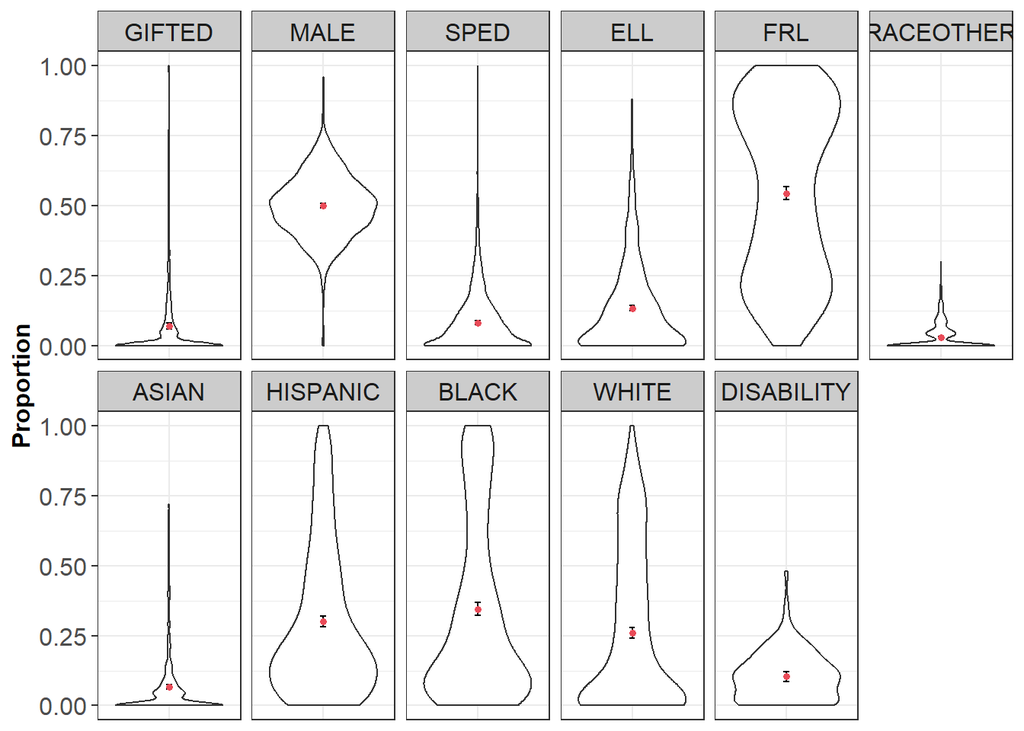

Note. The coral dots represent the weighted means. Error bars represent 95% CI.

Descriptive information on teachers teaching the class sections

| Characteristic | Count | Non-missing observations | Proportion of non-missing observations | Proportion of sample size |
| --- | --- | --- | --- | --- |
| DAD_MALE | 101 | 590 | 0.171 | 0.166 |
| DAD_WHITE | 347 | 588 | 0.590 | 0.572 |
| DAD_BLACK | 196 | 588 | 0.333 | 0.323 |
| DAD_HISPANIC | 33 | 588 | 0.056 | 0.054 |
| DAD_RACEOTHER | 12 | 588 | 0.020 | 0.020 |
| DAD_MASTERSPLUS | 184 | 458 | 0.402 | 0.303 |
| DAD_YRSEXP_NEW | 36 | 223 | 0.161 | 0.059 |
| DAD_YRSEXP_EARLY | 49 | 223 | 0.220 | 0.081 |
| DAD_YRSEXP_EST | 48 | 223 | 0.215 | 0.079 |
| DAD_YRSEXP_EXP | 54 | 223 | 0.242 | 0.089 |
| DAD_YRSEXP_HIGH | 36 | 223 | 0.161 | 0.059 |

Note. This table indicates the counts of teachers in the analytical sample that indicated a certain demographic characteristic. The information may be missing for some teachers in the total sample of 607 teachers.  
Experience was grouped as NEW = [0, 2] years, EARLY = (2, 5] years, EST = (5, 10] years, EXP = (10, 20] years, HIGH = (20, Inf) years.  
This table was saved as desc_Y1_both_teachers_cat.csv.

Descriptive information on teachers teaching the class sections (continued)

| Characteristic | Mean | SD | N |
| --- | --- | --- | --- |
| DAD_YRSEXP | 10.892 | 9.419 | 223 |
| FFT_CEV_adj | 2.662 | 0.203 | 607 |
| FFT_CERR_adj | 2.674 | 0.246 | 607 |
| FFT_ECL_adj | 2.531 | 0.222 | 607 |
| FFT_MCP_adj | 2.676 | 0.216 | 607 |
| FFT_MSB_adj | 2.768 | 0.242 | 607 |
| MQI_EI_adj | 1.227 | 0.072 | 607 |
| MQI_RICH_adj | 1.267 | 0.078 | 607 |
| MQI_WWSM_adj | 1.288 | 0.064 | 607 |
| MQI_SPMMR_adj | 1.224 | 0.096 | 607 |
| VA_SAM_adj | 0.015 | 0.183 | 607 |
| VA_BAM_adj | 0.008 | 0.185 | 607 |
| VA_NOAGGR_SAM_adj | 0.014 | 0.190 | 607 |
| VA_NOAGGR_BAM_adj | 0.007 | 0.188 | 607 |

Note. This table indicates mean and SD of teachers in the analytical sample that indicated a certain demographic characteristic. The information may be missing for some teachers in the total sample of 607 teachers.  
CEV, VA_SAM & VA_BAM represent teacher-level aggregates. FFT scores were adjusted at teacher level. VAMs were adjusted at section level and then aggregated at the teacher level using weighted means, accounting for the pupils included in the section-level VAMs.  
This table was saved as desc_Y1_both_teachers_num.csv.

Correlation of teaching experience with necessary condition and outcomes

| x | y | cor | ci_l | ci_u | df | t | p | N |
| --- | --- | --- | --- | --- | --- | --- | --- | --- |
| DAD_YRSEXP | FFT_CEV_adj_std | 0.222 | 0.093 | 0.343 | 221 | 3.380 | 0.001 | 223 |
| DAD_YRSEXP | FFT_CERR_adj_std | 0.157 | 0.026 | 0.283 | 221 | 2.363 | 0.019 | 223 |
| DAD_YRSEXP | FFT_ECL_adj_std | 0.158 | 0.028 | 0.284 | 221 | 2.384 | 0.018 | 223 |
| DAD_YRSEXP | FFT_MCP_adj_std | 0.203 | 0.074 | 0.326 | 221 | 3.089 | 0.002 | 223 |
| DAD_YRSEXP | FFT_MSB_adj_std | 0.263 | 0.137 | 0.381 | 221 | 4.058 | 0.000 | 223 |
| DAD_YRSEXP | MQI_EI_adj_std | -0.001 | -0.133 | 0.130 | 221 | -0.022 | 0.982 | 223 |
| DAD_YRSEXP | MQI_RICH_adj_std | 0.058 | -0.074 | 0.188 | 221 | 0.860 | 0.391 | 223 |
| DAD_YRSEXP | MQI_WWSM_adj_std | 0.006 | -0.126 | 0.137 | 221 | 0.082 | 0.935 | 223 |
| DAD_YRSEXP | MQI_SPMMR_adj_std | -0.069 | -0.198 | 0.063 | 221 | -1.025 | 0.306 | 223 |
| DAD_YRSEXP | VA_SAM_adj_std | -0.050 | -0.180 | 0.082 | 221 | -0.741 | 0.460 | 223 |
| DAD_YRSEXP | VA_BAM_adj_std | -0.090 | -0.219 | 0.041 | 221 | -1.349 | 0.179 | 223 |

Note. Data on DAD_YRSEXP is available for 223 teachers.  
This table was saved as cor_Y1_both_teaching_exp.csv.

#### **Figure**

#### *Relationship between teaching experience, necessary condition and outcomes*

Underlying count data for figure - Years of teaching experience

| DAD_YRSEXP_GRP | Domain | Mean | SD | N |
| --- | --- | --- | --- | --- |
| [0, 2] | CEV | -0.66 | 1.30 | 36 |
| [0, 2] | SAM | -0.15 | 1.01 | 36 |
| [0, 2] | BAM | -0.06 | 1.02 | 36 |
| (2, 5] | CEV | -0.01 | 1.01 | 49 |
| (2, 5] | SAM | -0.16 | 0.70 | 49 |
| (2, 5] | BAM | 0.08 | 0.65 | 49 |
| (5, 10] | CEV | 0.28 | 0.84 | 48 |
| (5, 10] | SAM | 0.13 | 0.75 | 48 |
| (5, 10] | BAM | -0.05 | 0.82 | 48 |
| (10, 20] | CEV | 0.28 | 0.83 | 54 |
| (10, 20] | SAM | -0.16 | 0.64 | 54 |
| (10, 20] | BAM | -0.22 | 0.81 | 54 |
| (20, Inf) | CEV | 0.28 | 0.72 | 36 |
| (20, Inf) | SAM | -0.24 | 0.70 | 36 |
| (20, Inf) | BAM | -0.14 | 0.77 | 36 |

#### **Figure**

#### *Relationship between teaching experience, necessary condition and outcomes*

[figure not shown]

Within vs between school variation - teacher level

| Domain | avg_within_sd | within_var | between_sd | between_var | total_var | within_pct | between_pct |
| --- | --- | --- | --- | --- | --- | --- | --- |
| FFT_CEV_adj | 0.148 | 0.030 | 0.178 | 0.032 | 0.062 | 0.489 | 0.511 |
| VA_BAM_adj | 0.135 | 0.024 | 0.173 | 0.030 | 0.054 | 0.446 | 0.554 |
| VA_SAM_adj | 0.132 | 0.026 | 0.145 | 0.021 | 0.047 | 0.555 | 0.445 |

Note. Data is available for 607 Teachers avg_within_sd is the average within-school SD. between_sd is the SD of school means. Classrooms were aggregated at teacher-level before aggregating at school level.

## Framework for Teaching (FFT)

Segment-level data is available for 4383 lesson segments.

Underlying count data for Observation score distributions figure

| item | domain | value | count | prop |
| --- | --- | --- | --- | --- |
| CERR | Classroom environment (FFT_CEV) | 1 | 135 | 0.0308008 |
| CERR | Classroom environment (FFT_CEV) | 2 | 849 | 0.1937029 |
| CERR | Classroom environment (FFT_CEV) | 3 | 2013 | 0.4592745 |
| CERR | Classroom environment (FFT_CEV) | 4 | 98 | 0.0223591 |
| CERR | Classroom environment (FFT_CEV) |  | 1288 | 0.2938627 |
| ECL | Classroom environment (FFT_CEV) | 1 | 124 | 0.0282911 |
| ECL | Classroom environment (FFT_CEV) | 2 | 1274 | 0.2906685 |
| ECL | Classroom environment (FFT_CEV) | 3 | 1602 | 0.3655031 |
| ECL | Classroom environment (FFT_CEV) | 4 | 67 | 0.0152863 |
| ECL | Classroom environment (FFT_CEV) |  | 1316 | 0.3002510 |
| MCP | Classroom environment (FFT_CEV) | 1 | 150 | 0.0342231 |
| MCP | Classroom environment (FFT_CEV) | 2 | 832 | 0.1898243 |
| MCP | Classroom environment (FFT_CEV) | 3 | 1988 | 0.4535706 |
| MCP | Classroom environment (FFT_CEV) | 4 | 97 | 0.0221310 |
| MCP | Classroom environment (FFT_CEV) |  | 1316 | 0.3002510 |
| MSB | Classroom environment (FFT_CEV) | 1 | 105 | 0.0239562 |
| MSB | Classroom environment (FFT_CEV) | 2 | 672 | 0.1533196 |
| MSB | Classroom environment (FFT_CEV) | 3 | 2174 | 0.4960073 |
| MSB | Classroom environment (FFT_CEV) | 4 | 132 | 0.0301164 |
| MSB | Classroom environment (FFT_CEV) |  | 1300 | 0.2966005 |

Note. The data shows the count of lesson video segments that have received a certain rating value for each component of the observation instrument.

#### **Figure**

#### *Distribution of observation scores*

[figure not shown]

#### **Figure**

#### *Unadjusted observation scores aggregated at teacher level*

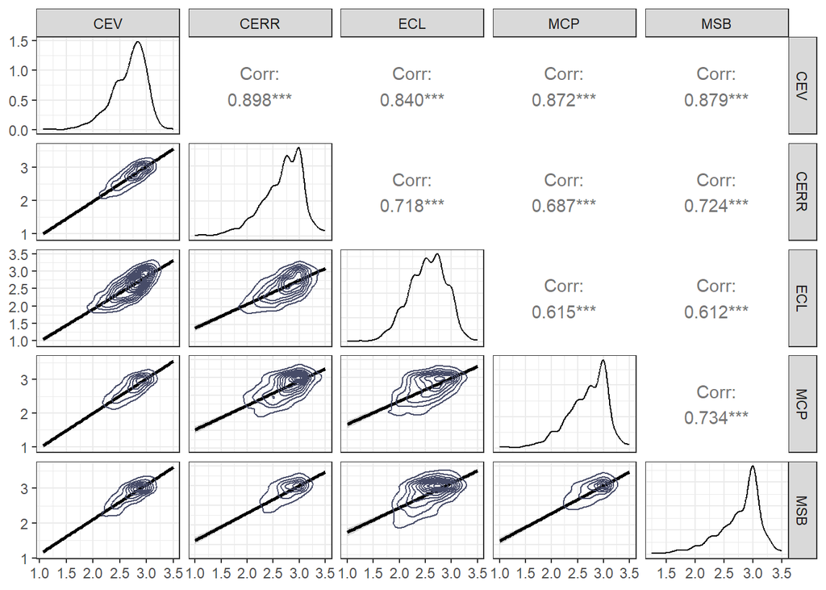

#### **Figure**

#### *Unadjusted observation scores aggregated at teacher level*

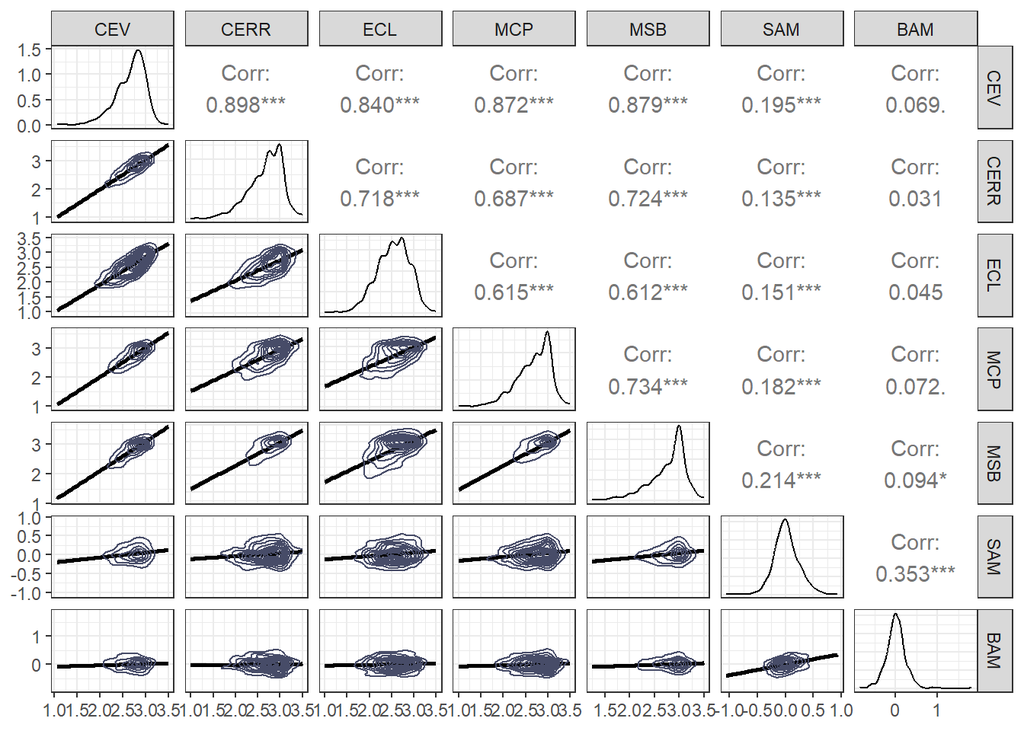

#### **Figure**

#### *Raw and adjusted observation scores*

[figure not shown]

Raw and adjusted observation scores

| Domain | Mean | SD | Mean_adj | SD_adj |
| --- | --- | --- | --- | --- |
| FFT_CEV | 2.665 | 0.333 | 2.662 | 0.203 |
| FFT_CERR | 2.676 | 0.391 | 2.674 | 0.246 |
| FFT_ECL | 2.533 | 0.369 | 2.531 | 0.222 |
| FFT_MCP | 2.680 | 0.392 | 2.676 | 0.216 |
| FFT_MSB | 2.770 | 0.376 | 2.768 | 0.242 |

Note. Data from 607 teachers is included.  
FFT_CEV refers to the domain scores for classroom environment, computed as the mean of their indicators.  
This table was saved as desc_Y1_both_FFT_adj.csv.

#### **Figure**

#### *Adjusted observation scores aggregated at teacher level*

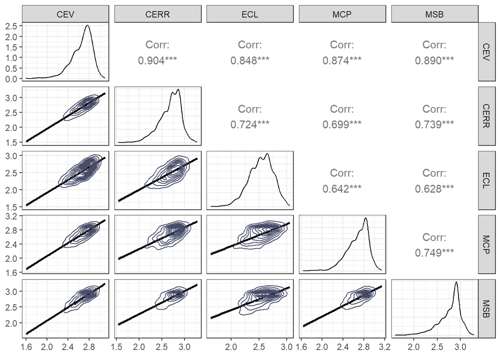